# A multiple model’s analysis of the association between daily lifestyle and physical fitness among adults in Xuzhou, China, based on National Physical Fitness Monitoring

2024-01-17

## Introduction

This document contains the source codes and corresponding execution results for exploring the daily lifestyle impacting physical fitness among adults in Xuzhou CIty, including all detailed codes for tables, figures, and the adopted models (multiple linear regression, binary logistic regression, linear mixed model) with standard diagnostics.

## Load necessary package and data

```r
rm(list = ls())
pkg <- c('car','pROC','ltm','tidyverse','rstatix','bruceR','cowplot','lmerTest','sjPlot','sjmisc','sjlabelled','readxl','openxlsx','foreign','rms','magrittr','glmmTMB')
lapply(pkg,function(x){library(x,character.only = T)})
```

```r
data <- read_excel("E:/Rticedata/adults/adultsdata.xlsx")
selected_columns <- c(1:2,6,7,8,9,12,13,16,19,22,25,28,31,34,37,40,43,46,49,52,55,58,61,64,67:87,89:97,99,101,103,105,107,113,115,117,119)
new_data <- data[, selected_columns]
```

## Data clean

Fill missing value

```r
cols_to_fill <- c(27:37, 42:44)
new_data[, cols_to_fill][is.na(new_data[, cols_to_fill])] <- 0
```

Remove all missing values

```r
new_data_cleaned <- na.omit(new_data)
```

Select samples

```r
set.seed(200)
unqualified_indices <- which(new_data_cleaned$PFS == "0")
qualified_indices <- which(new_data_cleaned$PFS == "1")
num_samples_to_extract <- length(unqualified_indices) * 2.5
random_indices <- sample(qualified_indices, num_samples_to_extract)
selected_indices <- c(unqualified_indices, random_indices)
new_dataset <- new_data_cleaned[selected_indices, ]
data <- new_dataset[sample(nrow(new_dataset)), ]
```

## Data processing

```r
mydata <- data %>%
  mutate(
    PFS = factor(case_when(PFS == 0 ~ 'Unqualified',
                           PFS == 1 ~ 'Qualified'),
                levels = c('Unqualified','Qualified')),
    gender = factor(case_when(gender == 1 ~ 'Male',
                              gender == 2 ~ 'Female'),
                    levels = c('Female','Male')),
    age_group.ord = factor(case_when(age_group == 1 ~ '20-29',
                                     age_group == 2 ~ '30-39',
                                     age_group == 3 ~ '40-49',
                                     age_group == 4 ~ '50-59'),
                           levels = c('20-29','30-39','40-49','50-59'),ordered = T),
    region = factor(case_when(region == 1 ~ 'Village',
                              region == 2 ~ 'Urban Manual Workers',
                              region == 3 ~ 'Urban Non-Manual Workers'),
                             levels = c('Village','Urban Manual Workers','Urban Non-Manual Workers')),
    educational_level.ord = factor(case_when(educational_level == 1 ~ 'High School and Below',
                                             educational_level == 2 ~ 'College Degree',
                                             educational_level == 3 ~ 'Bachelor Degree and Above'),
                                   levels = c('High School and Below','College Degree','Bachelor Degree and Above'),ordered = T),
    frequency_of_exercise.ord = factor(case_when(frequency_of_exercise == 1 ~ 'No Exercise',
                                                 frequency_of_exercise == 2 ~ 'Once a Week',
                                                 frequency_of_exercise == 3 ~ 'Twice a Week',
                                                 frequency_of_exercise == 4 ~ 'Three Times a Week',
                                                 frequency_of_exercise == 5 ~ 'Four Times a Week',
                                                 frequency_of_exercise == 6 ~ 'Five Times a Week',
                                                 frequency_of_exercise == 7 ~ 'More Than Five Times a Week'),
                                       levels = c('No Exercise','Once a Week','Twice a Week','Three Times a Week','Four Times a Week','Five Times a Week','More Than Five Times a Week'),ordered = T),
    exercise_time.ord = factor(case_when(exercise_time == 1 ~ 'Less Than 30 Minutes at a Time',
                                         exercise_time == 2 ~ 'Between 30 and 60 Minutes at a Time',
                                         exercise_time == 3 ~ 'More Than 60 Minutes at a Time'),
                               levels = c('Less Than 30 Minutes at a Time','Between 30 and 60 Minutes at a Time','More Than 60 Minutes at a Time'),ordered = T),
    type_of_occupation = factor(case_when(type_of_occupation == 1 ~ 'Professional Technicians',
                                          type_of_occupation == 2 ~ 'Clerical Staff',
                                          type_of_occupation == 3 ~ 'Commercial and Service Industry Workers',
                                          type_of_occupation == 4 ~ 'Agricultural Industry Workers',
                                          type_of_occupation == 5 ~ 'Other Workers',
                                          type_of_occupation == 6 ~ 'Unemployed'),
                                levels = c('Professional Technicians','Clerical Staff',
                                           'Commercial and Service Industry Workers',
                                           'Agricultural Industry Workers',
                                           'Other Workers','Unemployed')),
    hypertension = factor(case_when(hypertension == 0 ~ 'No',
                                    hypertension == 1 ~ 'Yes'),
                          levels = c('No','Yes')),
    hyperlipidemia = factor(case_when(hyperlipidemia == 0 ~ 'No',
                                      hyperlipidemia == 1 ~ 'Yes'),
                            levels = c('No','Yes')),
    high_cholesterol = factor(case_when(high_cholesterol == 0 ~ 'No',
                                        high_cholesterol == 1 ~ 'Yes'),
                              levels = c('No','Yes')),
    diabetes = factor(case_when(diabetes == 0 ~ 'No',
                                diabetes == 1 ~ 'Yes'),
                      levels = c('No','Yes')),
    coronary_heart_disease = factor(case_when(coronary_heart_disease == 'FALSE' ~ 'No',
                                              coronary_heart_disease == 'TRUE' ~ 'Yes'),
                                    levels = c('No','Yes')),
    peptic_ulcer = factor(case_when(peptic_ulcer == 0 ~ 'No',
                                    peptic_ulcer == 1 ~ 'Yes'),
                          levels = c('No','Yes')),
    osteoarticular_diseases = factor(case_when(osteoarticular_diseases == 0 ~ 'No',
                                               osteoarticular_diseases == 1 ~ 'Yes'),
                                     levels = c('No','Yes')),
    cervical_spondylosis = factor(case_when(cervical_spondylosis == 0 ~ 'No',
                                            cervical_spondylosis == 1 ~ 'Yes'),
                                  levels = c('No','Yes')),
    occupational_disease = factor(case_when(occupational_disease == 0 ~ 'No',
                                            occupational_disease == 1 ~ 'Yes'),
                                  levels = c('No','Yes')),
    unknown = factor(case_when(unknown == 0 ~ 'No',
                               unknown == 1 ~ 'Yes'),
                     levels = c('No','Yes')),
    no_disease = factor(case_when(no_disease == 0 ~ 'No',
                                  no_disease == 1 ~ 'Yes'),
                        levels = c('No','Yes')),
    whether_to_exercise_or_not = factor(case_when(whether_to_exercise_or_not == 0 ~ 'No',
                                                  whether_to_exercise_or_not == 1 ~ 'Yes'),
                                        levels = c('No','Yes')),
    feelings_during_exercise.ord = factor(case_when(feelings_during_exercise == 1 ~ 'No burden',
                                                    feelings_during_exercise == 2 ~ 'A slight burden',
                                                    feelings_during_exercise == 3 ~ 'A heavy burden'),
                                          levels = c('No burden',
                                                     'A slight burden',
                                                     'A heavy burden'),ordered = T),
    exercise_projects = factor(case_when(exercise_projects == 0 ~ 'None',
                                         exercise_projects == 1 ~ 'Jogging',
                                         exercise_projects == 2 ~ 'Swimming',
                                         exercise_projects == 3 ~ 'Walking',
                                         exercise_projects == 4 ~ 'Ball',
                                         exercise_projects == 5 ~ 'Mountaineering',
                                         exercise_projects == 6 ~ 'Cycling',
                                         exercise_projects == 7 ~ 'Other'),
                   levels = c('None','Jogging','Swimming','Walking','Ball','Mountaineering',
                              'Cycling','Other')),
    exercise_reasons = factor(case_when(exercise_reasons == 0 ~ 'None',
                                        exercise_reasons == 1 ~ 'Recreation',
                                        exercise_reasons == 2 ~ 'Increase Physical Activity',
                                        exercise_reasons == 3 ~ 'Reduce Stress and Regulate Mood',
                                        exercise_reasons == 4 ~ 'Weight Loss',
                                        exercise_reasons == 5 ~ 'Bodybuilders',
                                        exercise_reasons == 6 ~ 'Prevent Disease',
                                        exercise_reasons == 7 ~ 'Other'),
                             levels = c('None','Recreation','Increase Physical Activity',
                                        'Reduce Stress and Regulate Mood','Weight Loss','Bodybuilders',
                                        'Prevent Disease','Other')),
    exercise_disorders = factor(case_when(exercise_disorders == 0 ~ 'None',
                                          exercise_disorders == 1 ~ 'Not Interested',
                                          exercise_disorders == 2 ~ 'Laziness',
                                          exercise_disorders == 3 ~ 'Not Advisable or Necessary to Participate',
                                          exercise_disorders == 4 ~ 'Lack of Time',
                                          exercise_disorders == 5 ~ 'Lack of On_Site Facilities',
                                          exercise_disorders == 6 ~ 'Lack of Guidance',
                                          exercise_disorders == 7 ~ 'Lack of Organization',
                                          exercise_disorders == 8 ~ 'Other'),
                               levels = c('None','Not Interested','Laziness',
                                          'Not Advisable or Necessary to Participate',
                                          'Lack of Time','Lack of On_Site Facilities','Lack of Guidance',
                                          'Lack of Organization', 'Other'))
  )
```

Define the function of showing mean and standard deviation (SD).

```r
meansd <- function(x) {
  md = round(mean(x),digits = 2)
  sd = round(sd(x),digits = 2)
  return(paste0(md,'±',sd))
}
```

## Generate Table 1 and Table S1

The categorical and ordinal variables were described by frequency and constituent ratio, and their differences between groups were compared by Chi-square test.

```r
a <- mydata %>% select(where(is.factor)) %>% map(.,table)
rate.tab.nomarg <- function(x){round(proportions(x)*100,2)}
rate.tab <- function(x){round(proportions(x,margin = 2)*100,2)}
a.rate <- a %>% map(.,rate.tab.nomarg)
```

Display the ‘Overall’ column.

```r
a.mtx <- map2(a, a.rate, ~ matrix(paste0(.x,' (',.y,')'),dim(.x),
                                  dimnames = dimnames(.x))) %>% print
```

```
## $PFS
##
##               [,1]
##   Unqualified "389 (28.58)"
##   Qualified   "972 (71.42)"
##
## $gender
##
##          [,1]
##   Female "664 (48.79)"
##   Male   "697 (51.21)"
##
## $region
##
##                            [,1]
##   Village                  "398 (29.24)"
##   Urban Manual Workers     "347 (25.5)"
##   Urban Non-Manual Workers "616 (45.26)"
##
## $type_of_occupation
##
##                                           [,1]
##   Professional Technicians                "480 (35.27)"
##   Clerical Staff                          "345 (25.35)"
##   Commercial and Service Industry Workers "133 (9.77)"
##   Agricultural Industry Workers           "44 (3.23)"
##   Other Workers                           "141 (10.36)"
##   Unemployed                              "218 (16.02)"
##
## $hypertension
##
##       [,1]
##   No  "1213 (89.13)"
##   Yes "148 (10.87)"
##
## $hyperlipidemia
##
##       [,1]
##   No  "1279 (93.98)"
##   Yes "82 (6.02)"
```

[output cut: 122 more lines]

```
##   More Than Five Times a Week "697 (51.21)"
##
## $exercise_time.ord
##
##                                       [,1]
##   Less Than 30 Minutes at a Time      "210 (15.43)"
##   Between 30 and 60 Minutes at a Time "511 (37.55)"
##   More Than 60 Minutes at a Time      "640 (47.02)"
##
## $feelings_during_exercise.ord
##
##                   [,1]
##   No burden       "479 (35.19)"
##   A slight burden "677 (49.74)"
##   A heavy burden  "205 (15.06)"
```

```r
b <- mydata %>% select(where(is.factor)) %>% map(.,~table(.x,mydata$PFS))
b.rate <- mydata %>% select(where(is.factor)) %>%
  map(.,~ rate.tab(table(.x,mydata$PFS)))
```

Display the ‘Qualified’ and ‘Unqualified’ columns.

```r
b.mtx <- map2(b, b.rate,
              ~ matrix(paste0(.x,' (',.y,')'),dim(.x),
                       dimnames = dimnames(.x))) %>% print
```

```
## $PFS
##
## .x            Unqualified Qualified
##   Unqualified "389 (100)" "0 (0)"
##   Qualified   "0 (0)"     "972 (100)"
##
## $gender
##
## .x       Unqualified   Qualified
##   Female "185 (47.56)" "479 (49.28)"
##   Male   "204 (52.44)" "493 (50.72)"
##
## $region
##
## .x                         Unqualified   Qualified
##   Village                  "131 (33.68)" "267 (27.47)"
##   Urban Manual Workers     "120 (30.85)" "227 (23.35)"
##   Urban Non-Manual Workers "138 (35.48)" "478 (49.18)"
##
## $type_of_occupation
##
## .x                                        Unqualified   Qualified
##   Professional Technicians                "150 (38.56)" "330 (33.95)"
##   Clerical Staff                          "84 (21.59)"  "261 (26.85)"
##   Commercial and Service Industry Workers "27 (6.94)"   "106 (10.91)"
##   Agricultural Industry Workers           "21 (5.4)"    "23 (2.37)"
##   Other Workers                           "36 (9.25)"   "105 (10.8)"
##   Unemployed                              "71 (18.25)"  "147 (15.12)"
##
## $hypertension
##
## .x    Unqualified   Qualified
##   No  "325 (83.55)" "888 (91.36)"
##   Yes "64 (16.45)"  "84 (8.64)"
##
## $hyperlipidemia
##
## .x    Unqualified   Qualified
##   No  "357 (91.77)" "922 (94.86)"
##   Yes "32 (8.23)"   "50 (5.14)"
```

[output cut: 122 more lines]

```
##   More Than Five Times a Week "178 (45.76)" "519 (53.4)"
##
## $exercise_time.ord
##
## .x                                    Unqualified  Qualified
##   Less Than 30 Minutes at a Time      "91 (23.39)" "119 (12.24)"
##   Between 30 and 60 Minutes at a Time "135 (34.7)" "376 (38.68)"
##   More Than 60 Minutes at a Time      "163 (41.9)" "477 (49.07)"
##
## $feelings_during_exercise.ord
##
## .x                Unqualified  Qualified
##   No burden       "135 (34.7)" "344 (35.39)"
##   A slight burden "191 (49.1)" "486 (50)"
##   A heavy burden  "63 (16.2)"  "142 (14.61)"
```

Implement Chi-square test and display the results.

```r
c <- mydata %>% select(where(is.factor)) %>%
  map(.,~chisq.test(table(.x,mydata$PFS))) %>% print
```

```
## $PFS
##
##  Pearson's Chi-squared test with Yates' continuity correction
##
## data:  table(.x, mydata$PFS)
## X-squared = 1356.1, df = 1, p-value < 2.2e-16
##
##
## $gender
##
##  Pearson's Chi-squared test with Yates' continuity correction
##
## data:  table(.x, mydata$PFS)
## X-squared = 0.26439, df = 1, p-value = 0.6071
##
##
## $region
##
##  Pearson's Chi-squared test
##
## data:  table(.x, mydata$PFS)
## X-squared = 21.303, df = 2, p-value = 2.366e-05
##
##
## $type_of_occupation
##
##  Pearson's Chi-squared test
##
## data:  table(.x, mydata$PFS)
## X-squared = 19.413, df = 5, p-value = 0.00161
##
##
## $hypertension
##
##  Pearson's Chi-squared test with Yates' continuity correction
##
## data:  table(.x, mydata$PFS)
## X-squared = 16.69, df = 1, p-value = 4.401e-05
##
##
```

[output cut: 135 more lines]

```
##
## $exercise_time.ord
##
##  Pearson's Chi-squared test
##
## data:  table(.x, mydata$PFS)
## X-squared = 26.597, df = 2, p-value = 1.677e-06
##
##
## $feelings_during_exercise.ord
##
##  Pearson's Chi-squared test
##
## data:  table(.x, mydata$PFS)
## X-squared = 0.54656, df = 2, p-value = 0.7609
```

Calculate mean and SD of continuous variables.

```r
mydata %>% summarise(
  across(where(is.numeric) & -TPTS,.fns = meansd)) %>% t
```

```
##                                        [,1]
## age                                    "40.24±11.71"
## age_group                              "2.58±1.13"
## educational_level                      "2.16±0.81"
## minutes_of_taking_vehicles_per_week    "3.13±13.04"
## minutes_of_driving_per_week            "5.98±23.61"
## minutes_of_riding_motorcycle_per_week  "16.49±38.35"
## minutes_of_riding_bicycle_per_week     "9.17±30.6"
## minutes_by_foot_per_week               "7.08±28.76"
## other_travel_minutes_per_week          "0.05±1.36"
## minutes_of_sedentary_behavior_per_week "70.91±115.99"
## minutes_with_standing_per_week         "40.48±99.82"
## minutes_with_walking_per_week          "17.87±64.14"
## minutes_to_manual_labor_per_week       "4.69±32.24"
## other_working_minutes_per_week         "9.95±50.56"
## minutes_to_watch_TV_per_week           "48.7±49.81"
## minutes_to_play_chess_per_week         "2.76±17.51"
## minutes_to_read_books_per_week         "28.94±45.09"
## minutes_to_stroll_per_week             "18.38±31.44"
## minutes_of_light_housework_per_week    "33.33±47.14"
## minutes_of_heavy_housework_per_week    "0.38±4.72"
## other_active_minutes_per_week          "0.39±5.73"
## frequency_of_exercise                  "5.37±2.05"
## exercise_time                          "2.32±0.72"
## feelings_during_exercise               "1.8±0.68"
## height                                 "165.08±9.08"
## weight                                 "68.6±14.02"
## chest_circumference                    "93.44±8.45"
## waist_circumference                    "84.07±11.31"
## hip_circumference                      "96.57±7.19"
## upper_arm_skin_fold_thickness          "18.43±8.25"
## scapular_skin_fold_thickness           "20.37±8.07"
## abdomen_skin_fold_thickness            "27.44±11"
## resting_heart_rate                     "79.71±12.17"
## systolic_blood_pressure                "126.4±16.98"
## diastolic_blood_pressure               "76.14±11.42"
## vital_capacity                         "2907.38±1061.03"
## sit_and_reach                          "9.27±9.83"
## grip_strength                          "35.27±12.67"
## one_leg_standing_with_eye_closed       "21.46±24.53"
## choice_reaction_time                   "0.52±0.19"
## stair_experiment_index                 "61.93±13.75"
## push_up                                "7.45±15.01"
## sit_up                                 "2.96±8.22"
## vertical_leap                          "12.55±15.78"
```

Calculate mean and SD of continuous variables across subgroups

```r
mydata %>% group_by(PFS) %>%
  summarise(
    across(where(is.numeric) & -TPTS,.fns = meansd)) %>%
  column_to_rownames("PFS") %>% t
```

```
##                                        Unqualified      Qualified
## age                                    "39.94±12.27"    "40.37±11.49"
## age_group                              "2.51±1.19"      "2.61±1.11"
## educational_level                      "1.98±0.82"      "2.23±0.79"
## minutes_of_taking_vehicles_per_week    "2.63±10.13"     "3.33±14.04"
## minutes_of_driving_per_week            "4.51±20.89"     "6.57±24.6"
## minutes_of_riding_motorcycle_per_week  "18.81±35.36"    "15.56±39.47"
## minutes_of_riding_bicycle_per_week     "7.59±27.02"     "9.81±31.91"
## minutes_by_foot_per_week               "6.55±22.05"     "7.29±31.05"
## other_travel_minutes_per_week          "0.03±0.61"      "0.06±1.56"
## minutes_of_sedentary_behavior_per_week "60.34±108.46"   "75.15±118.66"
## minutes_with_standing_per_week         "38.78±97.75"    "41.15±100.68"
## minutes_with_walking_per_week          "17.93±62.6"     "17.84±64.77"
## minutes_to_manual_labor_per_week       "9.21±45.67"     "2.88±24.71"
## other_working_minutes_per_week         "7.37±43.5"      "10.99±53.11"
## minutes_to_watch_TV_per_week           "49.27±51.75"    "48.47±49.04"
## minutes_to_play_chess_per_week         "3.16±22.85"     "2.6±14.86"
## minutes_to_read_books_per_week         "21.75±40.6"     "31.82±46.48"
## minutes_to_stroll_per_week             "18±29.84"       "18.53±32.08"
## minutes_of_light_housework_per_week    "30.42±46.97"    "34.49±47.19"
## minutes_of_heavy_housework_per_week    "0.47±6.05"      "0.34±4.07"
## other_active_minutes_per_week          "0.6±7.49"       "0.3±4.85"
## frequency_of_exercise                  "5.02±2.22"      "5.51±1.96"
## exercise_time                          "2.19±0.79"      "2.37±0.69"
## feelings_during_exercise               "1.81±0.69"      "1.79±0.68"
## height                                 "163.92±9.61"    "165.55±8.82"
## weight                                 "72.25±17.14"    "67.14±12.26"
## chest_circumference                    "96.14±9.74"     "92.36±7.62"
## waist_circumference                    "89.22±12.66"    "82.02±10.02"
## hip_circumference                      "99.56±8.2"      "95.37±6.37"
## upper_arm_skin_fold_thickness          "20.68±9.17"     "17.53±7.67"
## scapular_skin_fold_thickness           "22.91±9.17"     "19.35±7.34"
## abdomen_skin_fold_thickness            "31.5±12.22"     "25.82±10.03"
## resting_heart_rate                     "82.36±12.46"    "78.65±11.9"
## systolic_blood_pressure                "129.32±18.9"    "125.24±16"
## diastolic_blood_pressure               "78.11±12.55"    "75.35±10.84"
## vital_capacity                         "2421.93±908.29" "3101.67±1055.9"
## sit_and_reach                          "2.18±8.73"      "12.1±8.76"
## grip_strength                          "31.2±12.67"     "36.91±12.3"
## one_leg_standing_with_eye_closed       "12.66±16.73"    "24.98±26.22"
## choice_reaction_time                   "0.6±0.26"       "0.49±0.14"
## stair_experiment_index                 "56.96±15.01"    "63.92±12.69"
## push_up                                "4.21±8.61"      "8.75±16.73"
## sit_up                                 "1.9±6.34"       "3.38±8.83"
## vertical_leap                          "10.08±12.64"    "13.54±16.78"
```

Implement Levene’s test to check homoscedasticity of continuous variables among subgroups.

```r
levene <- function(vb) {
  levene_test(vb ~ PFS,data = mydata)$p
}
leven.reslt <- mydata %>%
  select(where(is.numeric)) %>%
  map(levene) %>% unlist %>% round(.,digits = 4) %>% print
```

```
##                                   TPTS                                    age
##                                 0.0000                                 0.0037
##                              age_group                      educational_level
##                                 0.0021                                 0.5751
##    minutes_of_taking_vehicles_per_week            minutes_of_driving_per_week
##                                 0.3728                                 0.1461
##  minutes_of_riding_motorcycle_per_week     minutes_of_riding_bicycle_per_week
##                                 0.1585                                 0.2262
##               minutes_by_foot_per_week          other_travel_minutes_per_week
##                                 0.6671                                 0.6869
## minutes_of_sedentary_behavior_per_week         minutes_with_standing_per_week
##                                 0.0333                                 0.6918
##          minutes_with_walking_per_week       minutes_to_manual_labor_per_week
##                                 0.9830                                 0.0011
##         other_working_minutes_per_week           minutes_to_watch_TV_per_week
##                                 0.2338                                 0.5009
##         minutes_to_play_chess_per_week         minutes_to_read_books_per_week
##                                 0.5891                                 0.0002
##             minutes_to_stroll_per_week    minutes_of_light_housework_per_week
##                                 0.7789                                 0.3424
##    minutes_of_heavy_housework_per_week          other_active_minutes_per_week
##                                 0.6391                                 0.3845
##                  frequency_of_exercise                          exercise_time
##                                 0.0002                                 0.1711
##               feelings_during_exercise                                 height
##                                 0.7644                                 0.0300
##                                 weight                    chest_circumference
##                                 0.0000                                 0.0000
##                    waist_circumference                      hip_circumference
##                                 0.0000                                 0.0000
##          upper_arm_skin_fold_thickness           scapular_skin_fold_thickness
##                                 0.0005                                 0.0000
##            abdomen_skin_fold_thickness                     resting_heart_rate
##                                 0.0000                                 0.4563
##                systolic_blood_pressure               diastolic_blood_pressure
##                                 0.0009                                 0.0012
##                         vital_capacity                          sit_and_reach
##                                 0.0024                                 0.6587
##                          grip_strength       one_leg_standing_with_eye_closed
##                                 0.4930                                 0.0000
##                   choice_reaction_time                 stair_experiment_index
##                                 0.0000                                 0.5548
##                                push_up                                 sit_up
##                                 0.0000                                 0.0026
##                          vertical_leap
##                                 0.0003
```

Display variables that satisfy homoscedasticity.

```r
(leven.reslt.great <- leven.reslt[leven.reslt > 0.05])
```

```
##                     educational_level   minutes_of_taking_vehicles_per_week
##                                0.5751                                0.3728
##           minutes_of_driving_per_week minutes_of_riding_motorcycle_per_week
##                                0.1461                                0.1585
##    minutes_of_riding_bicycle_per_week              minutes_by_foot_per_week
##                                0.2262                                0.6671
##         other_travel_minutes_per_week        minutes_with_standing_per_week
##                                0.6869                                0.6918
##         minutes_with_walking_per_week        other_working_minutes_per_week
##                                0.9830                                0.2338
##          minutes_to_watch_TV_per_week        minutes_to_play_chess_per_week
##                                0.5009                                0.5891
##            minutes_to_stroll_per_week   minutes_of_light_housework_per_week
##                                0.7789                                0.3424
##   minutes_of_heavy_housework_per_week         other_active_minutes_per_week
##                                0.6391                                0.3845
##                         exercise_time              feelings_during_exercise
##                                0.1711                                0.7644
##                    resting_heart_rate                         sit_and_reach
##                                0.4563                                0.6587
##                         grip_strength                stair_experiment_index
##                                0.4930                                0.5548
```

Display t statistics of t test.

```r
mydata %>% select(all_of(names(leven.reslt.great))) %>%
  map(., ~ t.test(.x ~ mydata$PFS, var.equal = T)$statistic) %>% unlist %>% round(.,digits = 4) %>% print
```

```
##                     educational_level.t   minutes_of_taking_vehicles_per_week.t
##                                 -5.2864                                 -0.8916
##           minutes_of_driving_per_week.t minutes_of_riding_motorcycle_per_week.t
##                                 -1.4544                                  1.4125
##    minutes_of_riding_bicycle_per_week.t              minutes_by_foot_per_week.t
##                                 -1.2107                                 -0.4302
##         other_travel_minutes_per_week.t        minutes_with_standing_per_week.t
##                                 -0.4032                                 -0.3965
##         minutes_with_walking_per_week.t        other_working_minutes_per_week.t
##                                  0.0213                                 -1.1912
##          minutes_to_watch_TV_per_week.t        minutes_to_play_chess_per_week.t
##                                  0.2680                                  0.5403
##            minutes_to_stroll_per_week.t   minutes_of_light_housework_per_week.t
##                                 -0.2808                                 -1.4403
##   minutes_of_heavy_housework_per_week.t         other_active_minutes_per_week.t
##                                  0.4691                                  0.8699
##                         exercise_time.t              feelings_during_exercise.t
##                                 -4.2406                                  0.5570
##                    resting_heart_rate.t                         sit_and_reach.t
##                                  5.1309                                -18.8868
##                         grip_strength.t                stair_experiment_index.t
##                                 -7.6700                                 -8.6618
```

Display P values of t test.

```r
mydata %>% select(all_of(names(leven.reslt.great))) %>%
  map(., ~ t.test(.x ~ mydata$PFS, var.equal = T)$p.value) %>% unlist %>% round(.,digits = 4) %>% print
```

```
##                     educational_level   minutes_of_taking_vehicles_per_week
##                                0.0000                                0.3728
##           minutes_of_driving_per_week minutes_of_riding_motorcycle_per_week
##                                0.1461                                0.1580
##    minutes_of_riding_bicycle_per_week              minutes_by_foot_per_week
##                                0.2262                                0.6671
##         other_travel_minutes_per_week        minutes_with_standing_per_week
##                                0.6869                                0.6918
##         minutes_with_walking_per_week        other_working_minutes_per_week
##                                0.9830                                0.2338
##          minutes_to_watch_TV_per_week        minutes_to_play_chess_per_week
##                                0.7887                                0.5891
##            minutes_to_stroll_per_week   minutes_of_light_housework_per_week
##                                0.7789                                0.1500
##   minutes_of_heavy_housework_per_week         other_active_minutes_per_week
##                                0.6391                                0.3845
##                         exercise_time              feelings_during_exercise
##                                0.0000                                0.5776
##                    resting_heart_rate                         sit_and_reach
##                                0.0000                                0.0000
##                         grip_strength                stair_experiment_index
##                                0.0000                                0.0000
```

Display variables that do note satisfy homoscedasticity.

```r
(leven.reslt.great <- leven.reslt[leven.reslt < 0.05])
```

```
##                                   TPTS                                    age
##                                 0.0000                                 0.0037
##                              age_group minutes_of_sedentary_behavior_per_week
##                                 0.0021                                 0.0333
##       minutes_to_manual_labor_per_week         minutes_to_read_books_per_week
##                                 0.0011                                 0.0002
##                  frequency_of_exercise                                 height
##                                 0.0002                                 0.0300
##                                 weight                    chest_circumference
##                                 0.0000                                 0.0000
##                    waist_circumference                      hip_circumference
##                                 0.0000                                 0.0000
##          upper_arm_skin_fold_thickness           scapular_skin_fold_thickness
##                                 0.0005                                 0.0000
##            abdomen_skin_fold_thickness                systolic_blood_pressure
##                                 0.0000                                 0.0009
##               diastolic_blood_pressure                         vital_capacity
##                                 0.0012                                 0.0024
##       one_leg_standing_with_eye_closed                   choice_reaction_time
##                                 0.0000                                 0.0000
##                                push_up                                 sit_up
##                                 0.0000                                 0.0026
##                          vertical_leap
##                                 0.0003
```

Display t’ statistics of t’ test.

```r
mydata %>% select(all_of(names(leven.reslt.great))) %>%
  map(., ~ t.test(.x ~ mydata$PFS, var.equal = F)$statistic) %>% unlist %>% round(.,digits = 4) %>% print
```

```
##                                   TPTS.t
##                                 -43.7778
##                                    age.t
##                                  -0.5934
##                              age_group.t
##                                  -1.4541
## minutes_of_sedentary_behavior_per_week.t
##                                  -2.2142
##       minutes_to_manual_labor_per_week.t
##                                   2.5856
##         minutes_to_read_books_per_week.t
##                                  -3.9621
##                  frequency_of_exercise.t
##                                  -3.8227
##                                 height.t
##                                  -2.8813
##                                 weight.t
##                                   5.3566
##                    chest_circumference.t
##                                   6.8558
##                    waist_circumference.t
##                                  10.0296
##                      hip_circumference.t
##                                   9.0392
##          upper_arm_skin_fold_thickness.t
##                                   5.9944
##           scapular_skin_fold_thickness.t
##                                   6.8302
##            abdomen_skin_fold_thickness.t
##                                   8.1385
##                systolic_blood_pressure.t
##                                   3.7566
##               diastolic_blood_pressure.t
##                                   3.8010
##                         vital_capacity.t
##                                 -11.8908
##       one_leg_standing_with_eye_closed.t
##                                 -10.3196
##                   choice_reaction_time.t
##                                   8.5589
##                                push_up.t
##                                  -6.5570
##                                 sit_up.t
##                                  -3.4607
##                          vertical_leap.t
##                                  -4.1271
```

Display P values of t’ test.

```r
mydata %>% select(all_of(names(leven.reslt.great))) %>%
  map(., ~ t.test(.x ~ mydata$PFS, var.equal = F)$p.value) %>% unlist %>% round(.,digits = 4) %>% print
```

```
##                                   TPTS                                    age
##                                 0.0000                                 0.5531
##                              age_group minutes_of_sedentary_behavior_per_week
##                                 0.1464                                 0.0271
##       minutes_to_manual_labor_per_week         minutes_to_read_books_per_week
##                                 0.0100                                 0.0001
##                  frequency_of_exercise                                 height
##                                 0.0001                                 0.0041
##                                 weight                    chest_circumference
##                                 0.0000                                 0.0000
##                    waist_circumference                      hip_circumference
##                                 0.0000                                 0.0000
##          upper_arm_skin_fold_thickness           scapular_skin_fold_thickness
##                                 0.0000                                 0.0000
##            abdomen_skin_fold_thickness                systolic_blood_pressure
##                                 0.0000                                 0.0002
##               diastolic_blood_pressure                         vital_capacity
##                                 0.0002                                 0.0000
##       one_leg_standing_with_eye_closed                   choice_reaction_time
##                                 0.0000                                 0.0000
##                                push_up                                 sit_up
##                                 0.0000                                 0.0006
##                          vertical_leap
##                                 0.0000
```

## Generate Table S2.

Total physical test scores for adults with different characteristics.

```r
fenzuvb <- c(quo(gender),quo(age_group.ord),quo(region),
             quo(educational_level.ord),quo(type_of_occupation),quo(whether_to_exercise_or_not),
             quo(frequency_of_exercise.ord),quo(exercise_time.ord),
             quo(feelings_during_exercise.ord),quo(exercise_projects),quo(exercise_reasons),
             quo(exercise_disorders),quo(hypertension),
             quo(hyperlipidemia),quo(high_cholesterol),
             quo(diabetes),quo(coronary_heart_disease),
             quo(peptic_ulcer),quo(osteoarticular_diseases),
             quo(cervical_spondylosis),quo(occupational_disease),
             quo(unknown),quo(no_disease))

options(digits=5)

for (i in seq_along(fenzuvb)) {
  mydata %>% group_by(!!fenzuvb[[i]]) %>%
    summarise(
      n = round(n(),2),
      percent = n()/dim(mydata)[1]*100,
      TPTS = meansd(TPTS)
    ) %>% print
}
```

```
## # A tibble: 2 × 4
##   gender     n percent TPTS
##   <fct>  <dbl>   <dbl> <chr>
## 1 Female   664    48.8 23.88±5.93
## 2 Male     697    51.2 25.23±6.39
## # A tibble: 4 × 4
##   age_group.ord     n percent TPTS
##   <ord>         <dbl>   <dbl> <chr>
## 1 20-29           337    24.8 27.14±6.17
## 2 30-39           264    19.4 28.47±6.33
## 3 40-49           395    29.0 22.51±4.93
## 4 50-59           365    26.8 21.62±4.78
## # A tibble: 3 × 4
##   region                       n percent TPTS
##   <fct>                    <dbl>   <dbl> <chr>
## 1 Village                    398    29.2 23.81±5.94
## 2 Urban Manual Workers       347    25.5 23.9±5.96
## 3 Urban Non-Manual Workers   616    45.3 25.45±6.4
## # A tibble: 3 × 4
##   educational_level.ord         n percent TPTS
##   <ord>                     <dbl>   <dbl> <chr>
## 1 High School and Below       350    25.7 21.72±5.24
## 2 College Degree              443    32.5 24.06±5.95
## 3 Bachelor Degree and Above   568    41.7 26.73±6.16
## # A tibble: 6 × 4
##   type_of_occupation                          n percent TPTS
##   <fct>                                   <dbl>   <dbl> <chr>
## 1 Professional Technicians                  480   35.3  24.62±5.99
## 2 Clerical Staff                            345   25.3  25.56±6.38
## 3 Commercial and Service Industry Workers   133    9.77 25.93±6.5
## 4 Agricultural Industry Workers              44    3.23 19.86±4.48
## 5 Other Workers                             141   10.4  23.87±5.69
## 6 Unemployed                                218   16.0  23.5±6.19
## # A tibble: 2 × 4
##   whether_to_exercise_or_not     n percent TPTS
##   <fct>                      <dbl>   <dbl> <chr>
## 1 No                            91    6.69 22.53±5.62
## 2 Yes                         1270   93.3  24.72±6.22
## # A tibble: 7 × 4
##   frequency_of_exercise.ord       n percent TPTS
```

[output cut: 94 more lines]

```
## # A tibble: 2 × 4
##   occupational_disease     n percent TPTS
##   <fct>                <dbl>   <dbl> <chr>
## 1 No                    1337   98.2  24.53±6.23
## 2 Yes                     24    1.76 27.29±3.87
## # A tibble: 2 × 4
##   unknown     n percent TPTS
##   <fct>   <dbl>   <dbl> <chr>
## 1 No        505    37.1 23.26±5.74
## 2 Yes       856    62.9 25.35±6.34
## # A tibble: 2 × 4
##   no_disease     n percent TPTS
##   <fct>      <dbl>   <dbl> <chr>
## 1 No          1208    88.8 24.74±6.3
## 2 Yes          153    11.2 23.28±5.25
```

Use Levene’s test to check homoscedasticity among subgroups.

```r
levene <- function(vb) {
  levene_test(TPTS ~ vb,data = mydata)$p
}
leven.reslt <- mydata %>%
  select(gender,age_group.ord,region,educational_level.ord,type_of_occupation,whether_to_exercise_or_not,
         frequency_of_exercise.ord,exercise_time.ord,feelings_during_exercise.ord,
         exercise_projects,exercise_reasons,exercise_disorders,hypertension,
         hyperlipidemia,high_cholesterol,diabetes,coronary_heart_disease,
         peptic_ulcer,osteoarticular_diseases,cervical_spondylosis,occupational_disease,
         unknown,no_disease) %>%
  map(levene) %>% unlist %>% round(.,digits = 5)
```

Display variables that satisfy homoscedaticity.

```r
(leven.reslt.great <- leven.reslt[leven.reslt > 0.05])
```

```
##                       region    frequency_of_exercise.ord
##                      0.08696                      0.32406
## feelings_during_exercise.ord            exercise_projects
##                      0.14113                      0.25829
##             exercise_reasons           exercise_disorders
##                      0.43623                      0.97159
##                 hypertension             high_cholesterol
##                      0.59758                      0.22696
##       coronary_heart_disease                 peptic_ulcer
##                      0.18833                      0.27277
##         cervical_spondylosis
##                      0.20236
```

Use t test or ANOVA to compare differences among subgroups. Post-hoc test is performed by Tukey’s method when homoscedasticity is satisfied, otherwise Games-Howell’s test.

```r
ttest <- function(vb) {
  anova_summary(aov(mydata$TPTS ~ vb))$p # t test or anova
}
mydata %>% select(all_of(names(leven.reslt.great))) %>%
  map(ttest) %>% unlist %>% round(.,digits = 5) %>% print
```

```
##                       region    frequency_of_exercise.ord
##                      0.00001                      0.00300
## feelings_during_exercise.ord            exercise_projects
##                      0.11600                      0.00000
##             exercise_reasons           exercise_disorders
##                      0.00032                      0.04500
##                 hypertension             high_cholesterol
##                      0.00000                      0.00050
##       coronary_heart_disease                 peptic_ulcer
##                      0.00053                      0.94300
##         cervical_spondylosis
##                      0.28300
```

```r
tukey_hsd(aov(mydata$TPTS ~ mydata$region))
```

```
## # A tibble: 3 × 9
##   term          group1     group2 null.value estimate conf.low conf.high   p.adj
## * <chr>         <chr>      <chr>       <dbl>    <dbl>    <dbl>     <dbl>   <dbl>
## 1 mydata$region Village    Urban…          0   0.0955   -0.965      1.16 9.76e-1
## 2 mydata$region Village    Urban…          0   1.64      0.714      2.57 1.04e-4
## 3 mydata$region Urban Man… Urban…          0   1.55      0.578      2.52 5.49e-4
## # ℹ 1 more variable: p.adj.signif <chr>
```

```r
tukey_hsd(aov(mydata$TPTS ~ mydata$frequency_of_exercise.ord))
```

```
## # A tibble: 21 × 9
##    term             group1 group2 null.value estimate conf.low conf.high   p.adj
##  * <chr>            <chr>  <chr>       <dbl>    <dbl>    <dbl>     <dbl>   <dbl>
##  1 mydata$frequenc… No Ex… Once …          0    1.94    -0.597      4.47 2.66e-1
##  2 mydata$frequenc… No Ex… Twice…          0    2.06    -0.732      4.85 3.08e-1
##  3 mydata$frequenc… No Ex… Three…          0    3.50     0.994      6.01 7.82e-4
##  4 mydata$frequenc… No Ex… Four …          0    2.36    -0.134      4.86 7.75e-2
##  5 mydata$frequenc… No Ex… Five …          0    2.39    -0.151      4.92 8.1 e-2
##  6 mydata$frequenc… No Ex… More …          0    1.59    -0.442      3.62 2.4 e-1
##  7 mydata$frequenc… Once … Twice…          0    0.125   -2.50       2.75 1   e+0
##  8 mydata$frequenc… Once … Three…          0    1.56    -0.760      3.89 4.23e-1
##  9 mydata$frequenc… Once … Four …          0    0.428   -1.89       2.74 9.98e-1
## 10 mydata$frequenc… Once … Five …          0    0.451   -1.91       2.81 9.98e-1
## # ℹ 11 more rows
## # ℹ 1 more variable: p.adj.signif <chr>
```

```r
print(tukey_hsd(aov(mydata$TPTS ~ mydata$frequency_of_exercise.ord)), n = Inf)
```

```
## # A tibble: 21 × 9
##    term             group1 group2 null.value estimate conf.low conf.high   p.adj
##  * <chr>            <chr>  <chr>       <dbl>    <dbl>    <dbl>     <dbl>   <dbl>
##  1 mydata$frequenc… No Ex… Once …          0   1.94     -0.597     4.47  2.66e-1
##  2 mydata$frequenc… No Ex… Twice…          0   2.06     -0.732     4.85  3.08e-1
##  3 mydata$frequenc… No Ex… Three…          0   3.50      0.994     6.01  7.82e-4
##  4 mydata$frequenc… No Ex… Four …          0   2.36     -0.134     4.86  7.75e-2
##  5 mydata$frequenc… No Ex… Five …          0   2.39     -0.151     4.92  8.1 e-2
##  6 mydata$frequenc… No Ex… More …          0   1.59     -0.442     3.62  2.4 e-1
##  7 mydata$frequenc… Once … Twice…          0   0.125    -2.50      2.75  1   e+0
##  8 mydata$frequenc… Once … Three…          0   1.56     -0.760     3.89  4.23e-1
##  9 mydata$frequenc… Once … Four …          0   0.428    -1.89      2.74  9.98e-1
## 10 mydata$frequenc… Once … Five …          0   0.451    -1.91      2.81  9.98e-1
## 11 mydata$frequenc… Once … More …          0  -0.347    -2.15      1.45  9.98e-1
## 12 mydata$frequenc… Twice… Three…          0   1.44     -1.17      4.04  6.62e-1
## 13 mydata$frequenc… Twice… Four …          0   0.303    -2.29      2.90  1   e+0
## 14 mydata$frequenc… Twice… Five …          0   0.326    -2.31      2.96  1   e+0
## 15 mydata$frequenc… Twice… More …          0  -0.472    -2.62      1.68  9.95e-1
## 16 mydata$frequenc… Three… Four …          0  -1.14     -3.42      1.15  7.64e-1
## 17 mydata$frequenc… Three… Five …          0  -1.11     -3.44      1.22  7.96e-1
## 18 mydata$frequenc… Three… More …          0  -1.91     -3.68     -0.148 2.37e-2
## 19 mydata$frequenc… Four … Five …          0   0.0227   -2.30      2.34  1   e+0
## 20 mydata$frequenc… Four … More …          0  -0.775    -2.53      0.977 8.49e-1
## 21 mydata$frequenc… Five … More …          0  -0.798    -2.61      1.01  8.5 e-1
## # ℹ 1 more variable: p.adj.signif <chr>
```

```r
print(tukey_hsd(aov(mydata$TPTS ~ mydata$feelings_during_exercise.ord)), n = Inf)
```

```
## # A tibble: 3 × 9
##   term   group1 group2 null.value estimate conf.low conf.high p.adj p.adj.signif
## * <chr>  <chr>  <chr>       <dbl>    <dbl>    <dbl>     <dbl> <dbl> <chr>
## 1 mydat… No bu… A sli…          0   0.747    -0.121      1.62 0.108 ns
## 2 mydat… No bu… A hea…          0   0.668    -0.545      1.88 0.4   ns
## 3 mydat… A sli… A hea…          0  -0.0786   -1.24       1.08 0.986 ns
```

```r
print(tukey_hsd(aov(mydata$TPTS ~ mydata$exercise_projects)), n = Inf)
```

```
## # A tibble: 28 × 9
##    term             group1 group2 null.value estimate conf.low conf.high   p.adj
##  * <chr>            <chr>  <chr>       <dbl>    <dbl>    <dbl>     <dbl>   <dbl>
##  1 mydata$exercise… None   Joggi…          0    0.475   -0.940     1.89  9.72e-1
##  2 mydata$exercise… None   Swimm…          0    2.73     1.11      4.34  9.08e-6
##  3 mydata$exercise… None   Walki…          0    2.45    -1.31      6.21  4.98e-1
##  4 mydata$exercise… None   Ball            0    1.47    -0.649     3.59  4.11e-1
##  5 mydata$exercise… None   Mount…          0    5.03     2.47      7.59  8.38e-8
##  6 mydata$exercise… None   Cycli…          0    2.29    -1.47      6.05  5.88e-1
##  7 mydata$exercise… None   Other           0    2.62     1.08      4.16  7.31e-6
##  8 mydata$exercise… Joggi… Swimm…          0    2.25     0.405     4.10  5.45e-3
##  9 mydata$exercise… Joggi… Walki…          0    1.97    -1.89      5.84  7.8 e-1
## 10 mydata$exercise… Joggi… Ball            0    0.995   -1.31      3.30  8.94e-1
## 11 mydata$exercise… Joggi… Mount…          0    4.55     1.84      7.26  1.06e-5
## 12 mydata$exercise… Joggi… Cycli…          0    1.81    -2.05      5.68  8.46e-1
```

[output cut: 17 more lines]

```r
print(tukey_hsd(aov(mydata$TPTS ~ mydata$exercise_reasons)), n = Inf)
```

```
## # A tibble: 28 × 9
##    term             group1 group2 null.value estimate conf.low conf.high   p.adj
##  * <chr>            <chr>  <chr>       <dbl>    <dbl>    <dbl>     <dbl>   <dbl>
##  1 mydata$exercise… None   Recre…          0   0.955    -0.736     2.65  0.678
##  2 mydata$exercise… None   Incre…          0  -0.205    -2.99      2.58  1
##  3 mydata$exercise… None   Reduc…          0   1.07     -1.10      3.24  0.809
##  4 mydata$exercise… None   Weigh…          0   0.349    -2.13      2.82  1
##  5 mydata$exercise… None   Bodyb…          0   2.96      0.588     5.34  0.00396
##  6 mydata$exercise… None   Preve…          0   0.571    -0.952     2.09  0.948
##  7 mydata$exercise… None   Other           0   3.00      0.462     5.53  0.00824
##  8 mydata$exercise… Recre… Incre…          0  -1.16     -4.26      1.94  0.949
##  9 mydata$exercise… Recre… Reduc…          0   0.115    -2.45      2.68  1
## 10 mydata$exercise… Recre… Weigh…          0  -0.606    -3.43      2.22  0.998
## 11 mydata$exercise… Recre… Bodyb…          0   2.01     -0.731     4.74  0.337
## 12 mydata$exercise… Recre… Preve…          0  -0.384    -2.43      1.66  0.999
```

[output cut: 17 more lines]

```r
print(tukey_hsd(aov(mydata$TPTS ~ mydata$exercise_disorders)), n = Inf)
```

```
## # A tibble: 36 × 9
##    term  group1 group2 null.value estimate conf.low conf.high p.adj p.adj.signif
##  * <chr> <chr>  <chr>       <dbl>    <dbl>    <dbl>     <dbl> <dbl> <chr>
##  1 myda… None   Not I…          0   2.11     -0.432     4.65  0.196 ns
##  2 myda… None   Lazin…          0   0.545    -4.29      5.38  1     ns
##  3 myda… None   Not A…          0  -0.368    -4.41      3.68  1     ns
##  4 myda… None   Lack …          0   0.237    -5.12      5.60  1     ns
##  5 myda… None   Lack …          0  -0.455    -5.15      4.24  1     ns
##  6 myda… None   Lack …          0   3.06     -0.677     6.80  0.212 ns
##  7 myda… None   Lack …          0  -0.499    -4.54      3.55  1     ns
##  8 myda… None   Other           0  -2.82     -8.64      3.00  0.854 ns
##  9 myda… Not I… Lazin…          0  -1.57     -6.97      3.84  0.993 ns
## 10 myda… Not I… Not A…          0  -2.48     -7.19      2.23  0.785 ns
## 11 myda… Not I… Lack …          0  -1.87     -7.75      4.00  0.987 ns
## 12 myda… Not I… Lack …          0  -2.57     -7.85      2.71  0.851 ns
```

[output cut: 24 more lines]

Display variables that do not satisfy homoscedaticity.

```r
(leven.reslt.less <- leven.reslt[leven.reslt < 0.05])
```

```
##                     gender              age_group.ord
##                    0.01238                    0.00000
##      educational_level.ord         type_of_occupation
##                    0.00224                    0.03703
## whether_to_exercise_or_not          exercise_time.ord
##                    0.02561                    0.03504
##             hyperlipidemia                   diabetes
##                    0.02883                    0.02725
##    osteoarticular_diseases       occupational_disease
##                    0.03185                    0.01618
##                    unknown                 no_disease
##                    0.00195                    0.00034
```

```r
welchtest <- function(vb) {
  welch_anova_test(mydata$TPTS ~ vb, data = mydata)$p
}
```

Use Welch’s t test to compare difference between two subgroups and display the results.

```r
mydata %>% select(all_of(names(leven.reslt.less))) %>%
  map(welchtest) %>% unlist %>% round(.,digits = 5) %>% print
```

```
##                     gender              age_group.ord
##                    0.00005                    0.00000
##      educational_level.ord         type_of_occupation
##                    0.00000                    0.00000
## whether_to_exercise_or_not          exercise_time.ord
##                    0.00053                    0.00014
##             hyperlipidemia                   diabetes
##                    0.00000                    0.00000
##    osteoarticular_diseases       occupational_disease
##                    0.00000                    0.00200
##                    unknown                 no_disease
##                    0.00000                    0.00200
```

Use Games-Howell’s test to compare among three or more subgroups and display the results.

```r
mydata %>% select(all_of(names(leven.reslt.less))) %>%
  map(levels) %>% map(length) %>% unlist
```

```
##                     gender              age_group.ord
##                          2                          4
##      educational_level.ord         type_of_occupation
##                          3                          6
## whether_to_exercise_or_not          exercise_time.ord
##                          2                          3
##             hyperlipidemia                   diabetes
##                          2                          2
##    osteoarticular_diseases       occupational_disease
##                          2                          2
##                    unknown                 no_disease
##                          2                          2
```

```r
mydata %>% games_howell_test(TPTS ~ age_group.ord)
```

```
## # A tibble: 6 × 8
##   .y.   group1 group2 estimate conf.low conf.high    p.adj p.adj.signif
## * <chr> <chr>  <chr>     <dbl>    <dbl>     <dbl>    <dbl> <chr>
## 1 TPTS  20-29  30-39     1.34    0.0111    2.66   4.7 e- 2 *
## 2 TPTS  20-29  40-49    -4.62   -5.70     -3.55   0        ****
## 3 TPTS  20-29  50-59    -5.52   -6.60     -4.44   1.01e-11 ****
## 4 TPTS  30-39  40-49    -5.96   -7.15     -4.77   1.79e-11 ****
## 5 TPTS  30-39  50-59    -6.85   -8.05     -5.66   1.64e-11 ****
## 6 TPTS  40-49  50-59    -0.895  -1.80      0.0127 5.5 e- 2 ns
```

```r
mydata %>% games_howell_test(TPTS ~ educational_level.ord)
```

```
## # A tibble: 3 × 8
##   .y.   group1          group2 estimate conf.low conf.high    p.adj p.adj.signif
## * <chr> <chr>           <chr>     <dbl>    <dbl>     <dbl>    <dbl> <chr>
## 1 TPTS  High School an… Colle…     2.34     1.41      3.27 1.04e- 8 ****
## 2 TPTS  High School an… Bache…     5.01     4.12      5.91 0        ****
## 3 TPTS  College Degree  Bache…     2.67     1.77      3.57 1.56e-11 ****
```

```r
mydata %>% games_howell_test(TPTS ~ type_of_occupation)
```

```
## # A tibble: 15 × 8
##    .y.   group1          group2 estimate conf.low conf.high   p.adj p.adj.signif
##  * <chr> <chr>           <chr>     <dbl>    <dbl>     <dbl>   <dbl> <chr>
##  1 TPTS  Professional T… Cleri…    0.943   -0.311   2.20    2.64e-1 ns
##  2 TPTS  Professional T… Comme…    1.32    -0.487   3.12    2.91e-1 ns
##  3 TPTS  Professional T… Agric…   -4.75    -6.90   -2.61    2.63e-7 ****
##  4 TPTS  Professional T… Other…   -0.744   -2.33    0.841   7.57e-1 ns
##  5 TPTS  Professional T… Unemp…   -1.12    -2.55    0.316   2.26e-1 ns
##  6 TPTS  Clerical Staff  Comme…    0.373   -1.52    2.27    9.93e-1 ns
##  7 TPTS  Clerical Staff  Agric…   -5.70    -7.92   -3.48    2.44e-9 ****
##  8 TPTS  Clerical Staff  Other…   -1.69    -3.38    0.00410 5.1 e-2 ns
##  9 TPTS  Clerical Staff  Unemp…   -2.06    -3.61   -0.509   2   e-3 **
## 10 TPTS  Commercial and… Agric…   -6.07    -8.62   -3.52    5.62e-9 ****
## 11 TPTS  Commercial and… Other…   -2.06    -4.18    0.0641  6.3 e-2 ns
## 12 TPTS  Commercial and… Unemp…   -2.43    -4.45   -0.416   8   e-3 **
## 13 TPTS  Agricultural I… Other…    4.01     1.60    6.42    7.55e-5 ****
## 14 TPTS  Agricultural I… Unemp…    3.64     1.32    5.96    2.39e-4 ***
## 15 TPTS  Other Workers   Unemp…   -0.372   -2.20    1.45    9.92e-1 ns
```

```r
mydata %>% games_howell_test(TPTS ~ exercise_time.ord)
```

```
## # A tibble: 3 × 8
##   .y.   group1           group2 estimate conf.low conf.high   p.adj p.adj.signif
## * <chr> <chr>            <chr>     <dbl>    <dbl>     <dbl>   <dbl> <chr>
## 1 TPTS  Less Than 30 Mi… Betwe…    2.00     0.891     3.11  8.13e-5 ****
## 2 TPTS  Less Than 30 Mi… More …    1.34     0.265     2.41  1   e-2 **
## 3 TPTS  Between 30 and … More …   -0.664   -1.54      0.210 1.76e-1 ns
```

## Weighted multiple linear regression (Weighted MLR)

The standard regression diagnostics were processed with the following steps:

1. Detect the multicollinearity between explanatory variables through variance inflation factor (VIF).
2. Detect the homoscedasticity of residuals.
3. Check the independence of residuals with Durbin-Waston’s test.
4. Detect the normality of residuals.
5. Check the linear relationship between the dependent and explanatory variables.
6. Check the extreme values.

```r
reg.formula <- as.formula(
  TPTS ~ gender + age + age_group + region + educational_level + type_of_occupation + minutes_of_taking_vehicles_per_week
  + minutes_of_driving_per_week + minutes_of_riding_motorcycle_per_week + minutes_of_riding_bicycle_per_week + minutes_by_foot_per_week
  + other_travel_minutes_per_week+ minutes_of_sedentary_behavior_per_week + minutes_with_standing_per_week + minutes_with_walking_per_week
  + minutes_to_manual_labor_per_week + other_working_minutes_per_week + minutes_to_watch_TV_per_week + minutes_to_play_chess_per_week
  + minutes_to_read_books_per_week + minutes_to_stroll_per_week + minutes_of_light_housework_per_week + minutes_of_heavy_housework_per_week
  + other_active_minutes_per_week + hypertension + hyperlipidemia + high_cholesterol + diabetes + coronary_heart_disease + peptic_ulcer
  + osteoarticular_diseases + cervical_spondylosis + occupational_disease + unknown + no_disease + whether_to_exercise_or_not + frequency_of_exercise
  + exercise_time + feelings_during_exercise + exercise_projects + exercise_reasons + exercise_disorders + chest_circumference + waist_circumference + hip_circumference + upper_arm_skin_fold_thickness
  + scapular_skin_fold_thickness + abdomen_skin_fold_thickness + resting_heart_rate + systolic_blood_pressure + diastolic_blood_pressure
)
tice <- lm(formula = reg.formula, data = mydata)
```

Detect the multicollinearity between explanatory variables through variance inflation factor (VIF).

```r
performance::check_collinearity(tice)
```

```
## # Check for Multicollinearity
##
## Low Correlation
##
##                                    Term  VIF     VIF 95% CI Increased SE
##                                  gender 2.19 [ 2.03,  2.37]         1.48
##                                  region 1.44 [ 1.35,  1.54]         1.20
##                       educational_level 1.80 [ 1.68,  1.94]         1.34
##                      type_of_occupation 3.10 [ 2.86,  3.38]         1.76
##     minutes_of_taking_vehicles_per_week 1.09 [ 1.05,  1.17]         1.04
##             minutes_of_driving_per_week 1.14 [ 1.09,  1.22]         1.07
##   minutes_of_riding_motorcycle_per_week 1.13 [ 1.08,  1.21]         1.06
##      minutes_of_riding_bicycle_per_week 1.09 [ 1.04,  1.17]         1.04
##                minutes_by_foot_per_week 1.16 [ 1.11,  1.24]         1.08
##           other_travel_minutes_per_week 1.09 [ 1.05,  1.17]         1.04
##  minutes_of_sedentary_behavior_per_week 1.69 [ 1.58,  1.82]         1.30
##          minutes_with_standing_per_week 1.38 [ 1.30,  1.48]         1.17
##           minutes_with_walking_per_week 1.19 [ 1.14,  1.28]         1.09
##        minutes_to_manual_labor_per_week 1.14 [ 1.09,  1.22]         1.07
##          other_working_minutes_per_week 1.23 [ 1.17,  1.32]         1.11
##            minutes_to_watch_TV_per_week 1.26 [ 1.20,  1.35]         1.12
##          minutes_to_play_chess_per_week 1.11 [ 1.06,  1.19]         1.05
##          minutes_to_read_books_per_week 1.36 [ 1.28,  1.46]         1.17
##              minutes_to_stroll_per_week 1.23 [ 1.17,  1.32]         1.11
##     minutes_of_light_housework_per_week 1.33 [ 1.26,  1.43]         1.16
##     minutes_of_heavy_housework_per_week 1.11 [ 1.06,  1.19]         1.05
##           other_active_minutes_per_week 1.06 [ 1.02,  1.15]         1.03
##                            hypertension 1.72 [ 1.61,  1.85]         1.31
##                          hyperlipidemia 1.46 [ 1.37,  1.56]         1.21
##                        high_cholesterol 1.33 [ 1.25,  1.42]         1.15
##                                diabetes 1.22 [ 1.16,  1.31]         1.11
##                  coronary_heart_disease 1.16 [ 1.10,  1.24]         1.08
##                            peptic_ulcer 1.16 [ 1.10,  1.24]         1.07
##                 osteoarticular_diseases 1.31 [ 1.24,  1.41]         1.15
##                    cervical_spondylosis 1.70 [ 1.59,  1.83]         1.30
##                    occupational_disease 1.20 [ 1.14,  1.28]         1.09
##                                 unknown 2.99 [ 2.76,  3.26]         1.73
##                              no_disease 1.61 [ 1.51,  1.73]         1.27
##              whether_to_exercise_or_not 1.33 [ 1.26,  1.42]         1.15
##                   frequency_of_exercise 2.17 [ 2.01,  2.35]         1.47
```

[output cut: 60 more lines]

```
##       0.40     [0.37, 0.43]
##       0.42     [0.39, 0.45]
##
## Moderate Correlation
##
##                 Term  VIF     VIF 95% CI Increased SE Tolerance
##  waist_circumference 6.77 [ 6.17,  7.43]         2.60      0.15
##  Tolerance 95% CI
##      [0.13, 0.16]
##
## High Correlation
##
##       Term   VIF     VIF 95% CI Increased SE Tolerance Tolerance 95% CI
##        age 19.71 [17.88, 21.74]         4.44      0.05     [0.05, 0.06]
##  age_group 17.99 [16.33, 19.84]         4.24      0.06     [0.05, 0.06]
```

There exists multicollinearity among age and age group. Thus, remove age in the regression formula.

```r
reg.formula <- update(reg.formula, . ~ . -age)
mydata.out <- mydata
tice <- lm(formula = reg.formula, data = mydata.out)
```

Detect the homoscedasticity of residuals.

```r
performance::check_heteroscedasticity(tice)
```

[output not shown]

The homoscedasticity of residuals dose not satisfy, and the independency is satisfied. Thus, weight MLR will be adopted to solve heteroscedasticity. The weights were inversely proportional to the variance of the dependent variable. Regress the absolute values of the residuals against the fitted values, and the resulting fitted values squared of this new regression will be the desired estimate of this variance.

```r
wt <- 1 / lm(abs(tice$residuals) ~ tice$fitted.values)$fitted.values^2
```

Perform weighted least squares regression.

```r
wls.model <- lm(formula = reg.formula, data = mydata.out, weights=wt)
```

Check the independence of residuals with Durbin-Waston’s test.

```r
performance::check_autocorrelation(wls.model)
```

```
## OK: Residuals appear to be independent and not autocorrelated (p = 0.528).
```

Detect the normality of residuals

```r
performance::check_normality(wls.model)
```

```
## OK: residuals appear as normally distributed (p = 0.105).
```

## Plot S1

Visual inspection did not reveal any significant linear or normal deviations or extreme values.

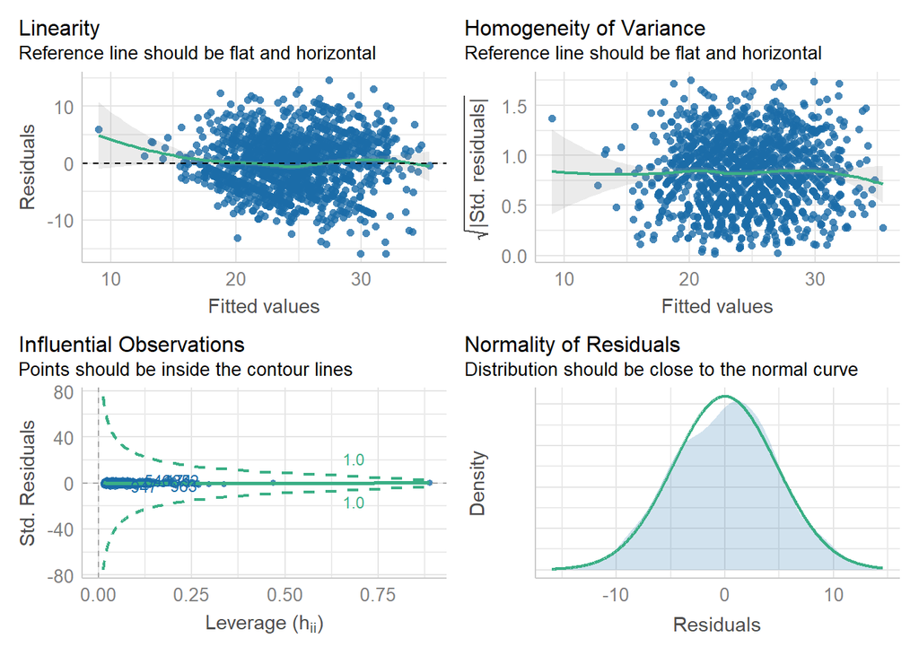

```r
performance::check_model(wls.model,check=c('linearity','normality','homogeneity','outliers'))
```

## Table S3

Comparison of models before and after weighting。

```r
performance::compare_performance(tice,wls.model)
```

```
## Some of the nested models seem to be identical
```

```
## # Comparison of Model Performance Indices
##
## Name      | Model |  AIC (weights) | AICc (weights) |  BIC (weights) |    R2 | R2 (adj.) |  RMSE | Sigma
## --------------------------------------------------------------------------------------------------------
## tice      |    lm | 8256.0 (<.001) | 8265.2 (<.001) | 8652.5 (<.001) | 0.413 |     0.379 | 4.751 | 4.887
## wls.model |    lm | 8236.6 (>.999) | 8245.7 (>.999) | 8633.0 (>.999) | 0.410 |     0.376 | 4.754 | 1.273
```

## Generate Table 2 of results of weighted MLR.

Results of weighted MLR, including coefficients’ estimations, 95% CIs and P values.

```r
tab_model(wls.model,show.ci = 0.95,show.p = TRUE,show.re.var = FALSE,show.ngroups = FALSE,
          show.aic = FALSE,show.r2=FALSE,digits = 3,digits.re = 3)
```

|  | TPTS |  |  |
| --- | --- | --- | --- |
| Predictors | Estimates | CI | p |
| (Intercept) | 37.219 | 32.050 – 42.388 | **<0.001** |
| gender [Male] | 1.250 | 0.496 – 2.004 | **0.001** |
| age group | -1.615 | -1.939 – -1.290 | **<0.001** |
| region [Urban Manual Workers] | -0.534 | -1.281 – 0.213 | 0.161 |
| region [Urban Non-Manual Workers] | 0.159 | -0.526 – 0.844 | 0.649 |
| educational level | 0.895 | 0.469 – 1.321 | **<0.001** |
| type of occupation [Clerical Staff] | 0.644 | -0.078 – 1.366 | 0.080 |
| type of occupation [Commercial and Service Industry Workers] | 0.644 | -0.398 – 1.686 | 0.225 |
| type of occupation [Agricultural Industry Workers] | -2.076 | -3.679 – -0.473 | **0.011** |
| type of occupation [Other Workers] | 0.197 | -0.783 – 1.178 | 0.693 |
| type of occupation [Unemployed] | -0.042 | -1.000 – 0.917 | 0.932 |
| minutes of taking vehicles per week | -0.003 | -0.024 – 0.018 | 0.769 |
| minutes of driving per week | 0.003 | -0.009 – 0.015 | 0.620 |
| minutes of riding motorcycle per week | -0.005 | -0.012 – 0.002 | 0.159 |
| minutes of riding bicycle per week | 0.005 | -0.004 – 0.013 | 0.294 |
| minutes by foot per week | 0.006 | -0.004 – 0.016 | 0.228 |
| other travel minutes per week | 0.114 | -0.106 – 0.333 | 0.309 |
| minutes of sedentary behavior per week | -0.002 | -0.005 – 0.001 | 0.230 |
| minutes with standing per week | 0.001 | -0.002 – 0.004 | 0.392 |
| minutes with walking per week | -0.000 | -0.005 – 0.004 | 0.914 |
| minutes to manual labor per week | -0.005 | -0.013 – 0.003 | 0.255 |
| other working minutes per week | 0.008 | 0.002 – 0.014 | **0.013** |
| minutes to watch TV per week | -0.003 | -0.008 – 0.003 | 0.343 |
| minutes to play chess per week | 0.002 | -0.012 – 0.016 | 0.812 |
| minutes to read books per week | 0.004 | -0.003 – 0.011 | 0.227 |
| minutes to stroll per week | 0.003 | -0.005 – 0.012 | 0.450 |
| minutes of light housework per week | 0.006 | -0.001 – 0.012 | 0.074 |
| minutes of heavy housework per week | 0.042 | -0.015 – 0.098 | 0.146 |
| other active minutes per week | 0.001 | -0.044 – 0.046 | 0.961 |
| hypertension [Yes] | -1.083 | -2.121 – -0.045 | **0.041** |
| hyperlipidemia [Yes] | -0.689 | -1.929 – 0.551 | 0.276 |
| high cholesterol [Yes] | 0.637 | -1.089 – 2.364 | 0.469 |
| diabetes [Yes] | -2.130 | -3.802 – -0.459 | **0.013** |
| coronary heart disease [Yes] | -0.692 | -2.858 – 1.473 | 0.531 |
| peptic ulcer [Yes] | -0.398 | -2.744 – 1.947 | 0.739 |
| osteoarticular diseases [Yes] | -1.244 | -2.484 – -0.004 | **0.049** |
| cervical spondylosis [Yes] | 0.214 | -0.824 – 1.252 | 0.686 |
| occupational disease [Yes] | 1.163 | -1.065 – 3.391 | 0.306 |
| unknown [Yes] | -0.357 | -1.250 – 0.536 | 0.433 |
| no disease [Yes] | -0.730 | -1.728 – 0.269 | 0.152 |
| whether to exercise or not [Yes] | 1.964 | 0.806 – 3.122 | **0.001** |
| frequency of exercise | 0.094 | -0.091 – 0.280 | 0.320 |
| exercise time | 0.365 | -0.107 – 0.838 | 0.130 |
| feelings during exercise | -0.188 | -0.620 – 0.245 | 0.394 |
| exercise projects [Jogging] | 0.068 | -0.701 – 0.837 | 0.862 |
| exercise projects [Swimming] | 0.366 | -0.536 – 1.269 | 0.426 |
| exercise projects [Walking] | -0.031 | -2.084 – 2.022 | 0.977 |
| exercise projects [Ball] | -0.353 | -1.514 – 0.809 | 0.552 |
| exercise projects [Mountaineering] | 2.576 | 1.115 – 4.036 | **0.001** |
| exercise projects [Cycling] | -0.010 | -2.108 – 2.089 | 0.993 |
| exercise projects [Other] | 1.071 | 0.201 – 1.941 | **0.016** |
| exercise reasons [Recreation] | -0.430 | -1.360 – 0.499 | 0.364 |
| exercise reasons [Increase Physical Activity] | -0.891 | -2.352 – 0.570 | 0.232 |
| exercise reasons [Reduce Stress and Regulate Mood] | 0.165 | -1.014 – 1.344 | 0.783 |
| exercise reasons [Weight Loss] | -0.483 | -1.880 – 0.914 | 0.498 |
| exercise reasons [Bodybuilders] | 0.032 | -1.284 – 1.348 | 0.962 |
| exercise reasons [Prevent Disease] | 0.170 | -0.636 – 0.976 | 0.679 |
| exercise reasons [Other] | 0.640 | -0.777 – 2.058 | 0.375 |
| exercise disorders [Not Interested] | 0.035 | -1.366 – 1.437 | 0.961 |
| exercise disorders [Laziness] | -0.868 | -3.400 – 1.663 | 0.501 |
| exercise disorders [Not Advisable or Necessary to Participate] | -0.166 | -2.343 – 2.011 | 0.881 |
| exercise disorders [Lack of Time] | 0.355 | -2.367 – 3.076 | 0.798 |
| exercise disorders [Lack of On_Site Facilities] | 0.304 | -2.148 – 2.756 | 0.808 |
| exercise disorders [Lack of Guidance] | 1.609 | -0.423 – 3.640 | 0.121 |
| exercise disorders [Lack of Organization] | -1.064 | -3.106 – 0.979 | 0.307 |
| exercise disorders [Other] | 0.385 | -2.473 – 3.243 | 0.791 |
| chest circumference | 0.133 | 0.068 – 0.197 | **<0.001** |
| waist circumference | -0.169 | -0.227 – -0.110 | **<0.001** |
| hip circumference | -0.059 | -0.126 – 0.009 | 0.091 |
| upper arm skin fold thickness | -0.030 | -0.077 – 0.018 | 0.218 |
| scapular skin fold thickness | -0.032 | -0.082 – 0.018 | 0.210 |
| abdomen skin fold thickness | -0.054 | -0.093 – -0.016 | **0.006** |
| resting heart rate | -0.048 | -0.072 – -0.025 | **<0.001** |
| systolic blood pressure | 0.009 | -0.015 – 0.033 | 0.469 |
| diastolic blood pressure | -0.015 | -0.049 – 0.020 | 0.411 |
| Observations | 1361 |  |  |

```r
estBeta <- wls.model$coefficients %>% round(.,digits = 3)
estBeta.ci <- wls.model %>% confint %>% round(.,digits = 3)
matrix(paste0(estBeta,' (',estBeta.ci[,1],', ',estBeta.ci[,2],')',
              round(summary(wls.model)$coefficients[,'t value'],3),' ',
              round(summary(wls.model)$coefficients[,'Pr(>|t|)'],3)),
       dim(estBeta.ci),dimnames = dimnames(estBeta.ci)[1])
```

```
##                                                             [,1]
## (Intercept)                                                 "37.219 (32.05, 42.388)14.127 0"
## genderMale                                                  "1.25 (0.496, 2.004)3.251 0.001"
## age_group                                                   "-1.615 (-1.939, -1.29)-9.769 0"
## regionUrban Manual Workers                                  "-0.534 (-1.281, 0.213)-1.403 0.161"
## regionUrban Non-Manual Workers                              "0.159 (-0.526, 0.844)0.455 0.649"
## educational_level                                           "0.895 (0.469, 1.321)4.12 0"
## type_of_occupationClerical Staff                            "0.644 (-0.078, 1.366)1.75 0.08"
## type_of_occupationCommercial and Service Industry Workers   "0.644 (-0.398, 1.686)1.213 0.225"
## type_of_occupationAgricultural Industry Workers             "-2.076 (-3.679, -0.473)-2.54 0.011"
## type_of_occupationOther Workers                             "0.197 (-0.783, 1.178)0.395 0.693"
## type_of_occupationUnemployed                                "-0.042 (-1, 0.917)-0.085 0.932"
## minutes_of_taking_vehicles_per_week                         "-0.003 (-0.024, 0.018)-0.293 0.769"
## minutes_of_driving_per_week                                 "0.003 (-0.009, 0.015)0.496 0.62"
## minutes_of_riding_motorcycle_per_week                       "-0.005 (-0.012, 0.002)-1.41 0.159"
## minutes_of_riding_bicycle_per_week                          "0.005 (-0.004, 0.013)1.05 0.294"
## minutes_by_foot_per_week                                    "0.006 (-0.004, 0.016)1.205 0.228"
## other_travel_minutes_per_week                               "0.114 (-0.106, 0.333)1.017 0.309"
## minutes_of_sedentary_behavior_per_week                      "-0.002 (-0.005, 0.001)-1.2 0.23"
## minutes_with_standing_per_week                              "0.001 (-0.002, 0.004)0.857 0.392"
## minutes_with_walking_per_week                               "0 (-0.005, 0.004)-0.108 0.914"
## minutes_to_manual_labor_per_week                            "-0.005 (-0.013, 0.003)-1.14 0.255"
## other_working_minutes_per_week                              "0.008 (0.002, 0.014)2.49 0.013"
## minutes_to_watch_TV_per_week                                "-0.003 (-0.008, 0.003)-0.949 0.343"
## minutes_to_play_chess_per_week                              "0.002 (-0.012, 0.016)0.238 0.812"
## minutes_to_read_books_per_week                              "0.004 (-0.003, 0.011)1.208 0.227"
## minutes_to_stroll_per_week                                  "0.003 (-0.005, 0.012)0.756 0.45"
## minutes_of_light_housework_per_week                         "0.006 (-0.001, 0.012)1.787 0.074"
## minutes_of_heavy_housework_per_week                         "0.042 (-0.015, 0.098)1.456 0.146"
## other_active_minutes_per_week                               "0.001 (-0.044, 0.046)0.049 0.961"
## hypertensionYes                                             "-1.083 (-2.121, -0.045)-2.047 0.041"
## hyperlipidemiaYes                                           "-0.689 (-1.929, 0.551)-1.091 0.276"
## high_cholesterolYes                                         "0.637 (-1.089, 2.364)0.724 0.469"
## diabetesYes                                                 "-2.13 (-3.802, -0.459)-2.501 0.013"
## coronary_heart_diseaseYes                                   "-0.692 (-2.858, 1.473)-0.627 0.531"
## peptic_ulcerYes                                             "-0.398 (-2.744, 1.947)-0.333 0.739"
## osteoarticular_diseasesYes                                  "-1.244 (-2.484, -0.004)-1.967 0.049"
## cervical_spondylosisYes                                     "0.214 (-0.824, 1.252)0.404 0.686"
## occupational_diseaseYes                                     "1.163 (-1.065, 3.391)1.024 0.306"
## unknownYes                                                  "-0.357 (-1.25, 0.536)-0.784 0.433"
```

[output cut: 21 more lines]

```
## exercise_disordersNot Advisable or Necessary to Participate "-0.166 (-2.343, 2.011)-0.149 0.881"
## exercise_disordersLack of Time                              "0.355 (-2.367, 3.076)0.256 0.798"
## exercise_disordersLack of On_Site Facilities                "0.304 (-2.148, 2.756)0.243 0.808"
## exercise_disordersLack of Guidance                          "1.609 (-0.423, 3.64)1.554 0.121"
## exercise_disordersLack of Organization                      "-1.064 (-3.106, 0.979)-1.022 0.307"
## exercise_disordersOther                                     "0.385 (-2.473, 3.243)0.264 0.791"
## chest_circumference                                         "0.133 (0.068, 0.197)4.017 0"
## waist_circumference                                         "-0.169 (-0.227, -0.11)-5.669 0"
## hip_circumference                                           "-0.059 (-0.126, 0.009)-1.691 0.091"
## upper_arm_skin_fold_thickness                               "-0.03 (-0.077, 0.018)-1.233 0.218"
## scapular_skin_fold_thickness                                "-0.032 (-0.082, 0.018)-1.254 0.21"
## abdomen_skin_fold_thickness                                 "-0.054 (-0.093, -0.016)-2.769 0.006"
## resting_heart_rate                                          "-0.048 (-0.072, -0.025)-4.096 0"
## systolic_blood_pressure                                     "0.009 (-0.015, 0.033)0.724 0.469"
## diastolic_blood_pressure                                    "-0.015 (-0.049, 0.02)-0.822 0.411"
```

Linear trend test for continuous variables in weighted MLR.

```r
mydata.out <- mydata.out %>% mutate(
  age_group.ord.MLR = factor(cut(age_group,breaks = 4,labels=c(1,2,3,4)),ordered = T),
  educational_level.ord.LR = factor(cut(educational_level,breaks = 4,labels=c(1,2,3,4)),ordered = T),
  other_working_minutes_per_week.ord = factor(cut(other_working_minutes_per_week,breaks = 4,labels=c(1,2,3,4)),ordered = T),
  chest_circumference.ord = factor(cut(chest_circumference,breaks = 4,labels=c(1,2,3,4)),ordered = T),
  waist_circumference.ord = factor(cut(waist_circumference,breaks = 4,labels=c(1,2,3,4)),ordered = T),
  abdomen_skin_fold_thickness.ord = factor(cut(abdomen_skin_fold_thickness,breaks = 4,labels=c(1,2,3,4)),ordered = T),
  resting_heart_rate.ord = factor(cut(resting_heart_rate,breaks = 4,labels=c(1,2,3,4)),ordered = T),
)
```

```r
summary(update(wls.model, . ~ . - age_group + age_group.ord.MLR))$coefficients[c('age_group.ord.MLR.L','age_group.ord.MLR.Q'),]
```

```
##                     Estimate Std. Error  t value   Pr(>|t|)
## age_group.ord.MLR.L  -3.7133    0.35689 -10.4045 2.1363e-24
## age_group.ord.MLR.Q  -1.0192    0.27856  -3.6589 2.6353e-04
```

```r
summary(update(wls.model, . ~ . - educational_level + educational_level.ord.LR))$coefficients[c('educational_level.ord.LR.L','educational_level.ord.LR.Q'),]
```

```
##                             Estimate Std. Error  t value   Pr(>|t|)
## educational_level.ord.LR.L  1.265896    0.30735  4.11876 4.0526e-05
## educational_level.ord.LR.Q -0.067055    0.24200 -0.27708 7.8176e-01
```

```r
summary(update(wls.model, . ~ . - other_working_minutes_per_week + other_working_minutes_per_week.ord))$coefficients[c('other_working_minutes_per_week.ord.L','other_working_minutes_per_week.ord.Q'),]
```

```
##                                      Estimate Std. Error t value Pr(>|t|)
## other_working_minutes_per_week.ord.L   2.9674    0.91783  3.2330 0.001256
## other_working_minutes_per_week.ord.Q   1.7234    1.24542  1.3838 0.166662
```

```r
summary(update(wls.model, . ~ . - chest_circumference + chest_circumference.ord))$coefficients[c('chest_circumference.ord.L','chest_circumference.ord.Q'),]
```

```
##                           Estimate Std. Error t value Pr(>|t|)
## chest_circumference.ord.L   2.3300     2.4815 0.93894  0.34794
## chest_circumference.ord.Q   1.6693     1.8223 0.91601  0.35983
```

```r
summary(update(wls.model, . ~ . - waist_circumference + waist_circumference.ord))$coefficients[c('waist_circumference.ord.L','waist_circumference.ord.Q'),]
```

```
##                            Estimate Std. Error   t value Pr(>|t|)
## waist_circumference.ord.L -0.076085     1.7479 -0.043529  0.96529
## waist_circumference.ord.Q -2.625956     1.1727 -2.239263  0.02531
```

```r
summary(update(wls.model, . ~ . - abdomen_skin_fold_thickness + abdomen_skin_fold_thickness.ord))$coefficients[c('abdomen_skin_fold_thickness.ord.L','abdomen_skin_fold_thickness.ord.Q'),]
```

```
##                                   Estimate Std. Error t value  Pr(>|t|)
## abdomen_skin_fold_thickness.ord.L -2.39685    0.92303 -2.5967 0.0095193
## abdomen_skin_fold_thickness.ord.Q -0.66438    0.62120 -1.0695 0.2850466
```

```r
summary(update(wls.model, . ~ . - resting_heart_rate + resting_heart_rate.ord))$coefficients[c('resting_heart_rate.ord.L','resting_heart_rate.ord.Q'),]
```

```
##                          Estimate Std. Error t value Pr(>|t|)
## resting_heart_rate.ord.L -1.71601    0.72484 -2.3674 0.018059
## resting_heart_rate.ord.Q  0.72767    0.54765  1.3287 0.184177
```

## Generate figure s5(a) and s5(b) of results of weighted MLR.

```r
attach(mydata.out)
xz_MLR <- data.frame(chest_circumference,waist_circumference,TPTS)
dd_MLR <- datadist(xz_MLR)
options(datadist='dd_MLR')
```

Restricted cubic spline analisis of chest circumference.

```r
fit_MLR_1 <- ols(TPTS ~ rcs(chest_circumference, 4), data = xz_MLR)
anova(fit_MLR_1)
```

```
##                 Analysis of Variance          Response: TPTS
##
##  Factor              d.f. Partial SS MS       F     P
##  chest_circumference    3  4140.2    1380.051 38.87 <.0001
##   Nonlinear             2  1504.5     752.227 21.18 <.0001
##  REGRESSION             3  4140.2    1380.051 38.87 <.0001
##  ERROR               1357 48184.5      35.508
```

```r
an_MLR_1 <- anova(fit_MLR_1)
Predict(fit_MLR_1,chest_circumference)
```

```
##     chest_circumference   yhat  lower  upper
## 1                75.995 24.371 23.139 25.602
## 2                76.196 24.419 23.211 25.628
## 3                76.397 24.468 23.283 25.653
## 4                76.598 24.517 23.355 25.678
## 5                76.799 24.566 23.427 25.704
## 6                77.000 24.614 23.499 25.730
## 7                77.201 24.663 23.571 25.755
## 8                77.402 24.712 23.642 25.781
## 9                77.603 24.761 23.714 25.807
## 10               77.804 24.809 23.785 25.834
## 11               78.005 24.858 23.856 25.860
## 12               78.206 24.907 23.927 25.887
## 13               78.407 24.956 23.998 25.914
## 14               78.608 25.004 24.068 25.941
```

[output cut: 190 more lines]

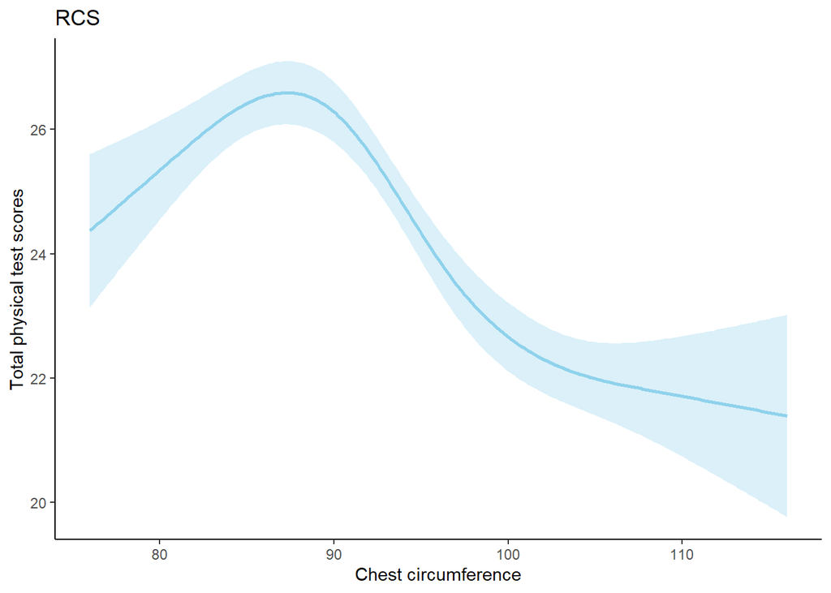

```r
β1 <-Predict(fit_MLR_1, chest_circumference)
ggplot()+geom_line(data=β1, aes(chest_circumference,yhat),linetype=1,size=1,alpha = 0.9,colour="skyblue")+
  geom_ribbon(data=β1, aes(chest_circumference,ymin = lower, ymax = upper),alpha = 0.3,fill="skyblue")+
  theme_classic()+
  labs(title = "RCS", x="Chest circumference", y="Total physical test scores")
```

Restricted cubic spline analisis of waist circumference.

```r
fit_MLR_2 <- ols(TPTS ~ rcs(waist_circumference, 4), data = xz_MLR)
anova(fit_MLR_2)
```

```
##                 Analysis of Variance          Response: TPTS
##
##  Factor              d.f. Partial SS MS       F     P
##  waist_circumference    3  7935.7    2645.222 80.87 <.0001
##   Nonlinear             2  1207.4     603.705 18.46 <.0001
##  REGRESSION             3  7935.7    2645.222 80.87 <.0001
##  ERROR               1357 44389.0      32.711
```

```r
an_MLR_2 <- anova(fit_MLR_2)
Predict(fit_MLR_2,waist_circumference)
```

```
##     waist_circumference   yhat  lower  upper
## 1                61.000 25.812 24.542 27.082
## 2                61.269 25.846 24.603 27.089
## 3                61.538 25.880 24.665 27.096
## 4                61.807 25.915 24.726 27.103
## 5                62.075 25.949 24.787 27.111
## 6                62.344 25.983 24.848 27.118
## 7                62.613 26.018 24.909 27.126
## 8                62.882 26.052 24.970 27.134
## 9                63.151 26.086 25.031 27.142
## 10               63.420 26.121 25.091 27.151
## 11               63.689 26.155 25.151 27.159
## 12               63.957 26.189 25.211 27.168
## 13               64.226 26.224 25.270 27.177
## 14               64.495 26.258 25.330 27.186
```

[output cut: 190 more lines]

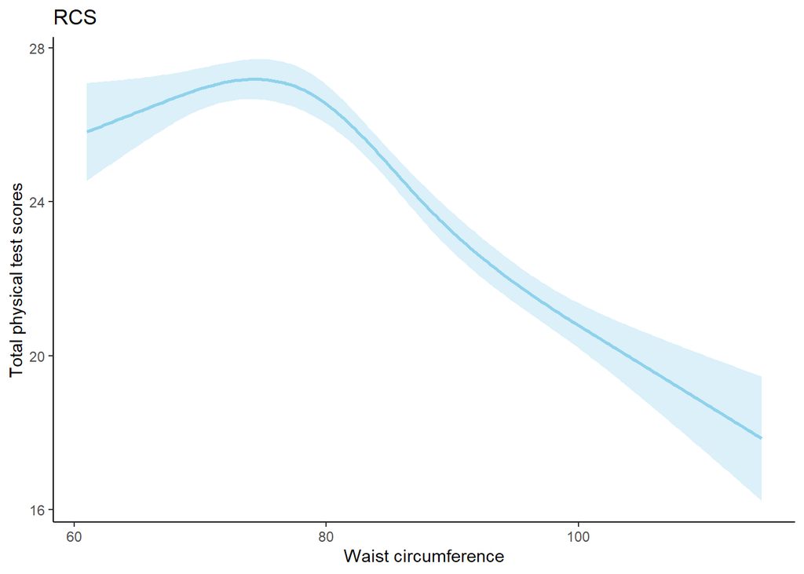

```r
β2 <-Predict(fit_MLR_2, waist_circumference)
ggplot()+geom_line(data=β2, aes(waist_circumference,yhat),linetype=1,size=1,alpha = 0.9,colour="skyblue")+
  geom_ribbon(data=β2, aes(waist_circumference,ymin = lower, ymax = upper),alpha = 0.3,fill="skyblue")+
  theme_classic()+
  labs(title = "RCS", x="Waist circumference", y="Total physical test scores")
```

## Binary logistic regression (BLR)

The diagnostics were processed with the following steps:

1. Detect the multicollinearity between explanatory variables through variance inflation factor (VIF).
2. Check the independence of residuals with Durbin-Waston’s test.
3. Check the linear relationship between the dependent and explanatory variables.
4. Check the extreme values.

```r
reg.formula.logi <- update(reg.formula,PFS ~ .)
mydata.logi.out <- mydata
tice.logi <- glm(
  formula = reg.formula.logi,
  family  = binomial(link = "logit"),
  data    = mydata.logi.out
)
```

Detect the multicollinearity between explanatory variables through variance inflation factor (VIF).

```r
performance::check_collinearity(tice.logi)
```

```
## # Check for Multicollinearity
##
## Low Correlation
##
##                                    Term  VIF   VIF 95% CI Increased SE
##                                  gender 2.25 [2.09, 2.44]         1.50
##                               age_group 2.20 [2.04, 2.39]         1.48
##                                  region 1.45 [1.36, 1.56]         1.20
##                       educational_level 1.83 [1.71, 1.97]         1.35
##                      type_of_occupation 3.51 [3.23, 3.83]         1.87
##     minutes_of_taking_vehicles_per_week 1.12 [1.07, 1.20]         1.06
##             minutes_of_driving_per_week 1.14 [1.09, 1.22]         1.07
##   minutes_of_riding_motorcycle_per_week 1.14 [1.09, 1.22]         1.07
##      minutes_of_riding_bicycle_per_week 1.09 [1.05, 1.17]         1.04
##                minutes_by_foot_per_week 1.14 [1.09, 1.22]         1.07
##           other_travel_minutes_per_week 1.04 [1.01, 1.15]         1.02
##  minutes_of_sedentary_behavior_per_week 1.62 [1.52, 1.74]         1.27
##          minutes_with_standing_per_week 1.36 [1.28, 1.46]         1.17
##           minutes_with_walking_per_week 1.20 [1.14, 1.28]         1.10
##        minutes_to_manual_labor_per_week 1.16 [1.11, 1.24]         1.08
##          other_working_minutes_per_week 1.19 [1.13, 1.27]         1.09
##            minutes_to_watch_TV_per_week 1.29 [1.22, 1.38]         1.14
##          minutes_to_play_chess_per_week 1.11 [1.06, 1.19]         1.05
##          minutes_to_read_books_per_week 1.37 [1.29, 1.47]         1.17
##              minutes_to_stroll_per_week 1.25 [1.18, 1.33]         1.12
##     minutes_of_light_housework_per_week 1.38 [1.30, 1.48]         1.17
##     minutes_of_heavy_housework_per_week 1.15 [1.10, 1.23]         1.07
##           other_active_minutes_per_week 1.08 [1.04, 1.16]         1.04
##                            hypertension 1.83 [1.71, 1.98]         1.35
##                          hyperlipidemia 1.49 [1.40, 1.59]         1.22
##                        high_cholesterol 1.34 [1.27, 1.44]         1.16
##                                diabetes 1.27 [1.21, 1.36]         1.13
##                  coronary_heart_disease 1.15 [1.10, 1.24]         1.07
##                            peptic_ulcer 1.13 [1.08, 1.21]         1.06
##                 osteoarticular_diseases 1.41 [1.33, 1.51]         1.19
##                    cervical_spondylosis 1.67 [1.56, 1.80]         1.29
##                    occupational_disease 1.10 [1.06, 1.18]         1.05
##                                 unknown 3.05 [2.81, 3.32]         1.75
##                              no_disease 1.67 [1.56, 1.79]         1.29
##              whether_to_exercise_or_not 1.40 [1.32, 1.50]         1.18
```

[output cut: 54 more lines]

```
##       0.43     [0.39, 0.46]
##       0.38     [0.35, 0.41]
##       0.22     [0.20, 0.24]
##       0.28     [0.26, 0.31]
##       0.43     [0.39, 0.46]
##       0.41     [0.38, 0.45]
##       0.39     [0.36, 0.42]
##       0.83     [0.77, 0.87]
##       0.39     [0.36, 0.42]
##       0.41     [0.38, 0.44]
##
## Moderate Correlation
##
##                 Term  VIF   VIF 95% CI Increased SE Tolerance Tolerance 95% CI
##  waist_circumference 6.20 [5.66, 6.80]         2.49      0.16     [0.15, 0.18]
```

Check the independence of residuals with Durbin-Waston’s test.

```r
performance::check_autocorrelation(tice.logi)
```

```
## OK: Residuals appear to be independent and not autocorrelated (p = 0.304).
```

## Plot Figure S2 of linearity.

Check the linear relationship between the dependent and explanatory variables.

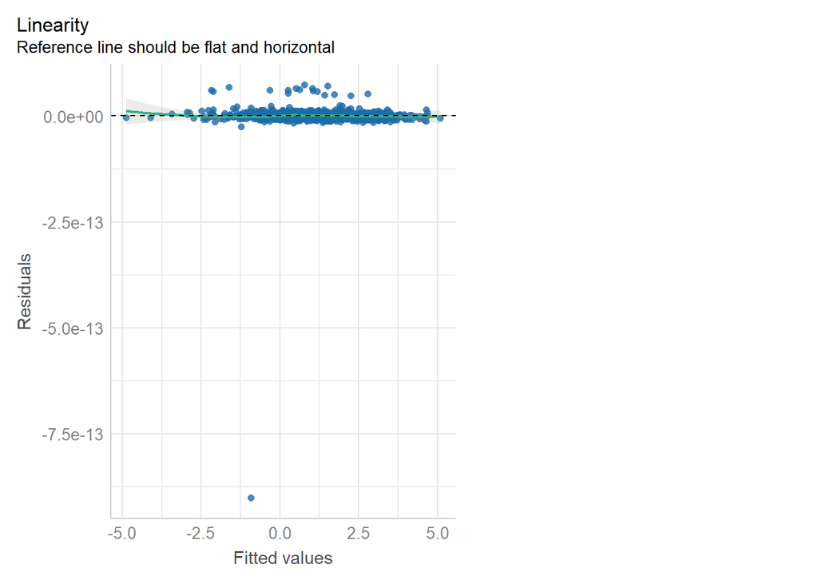

```r
mydata.logi.out <- mydata.logi.out %>% mutate(
  prob = predict(tice.logi,type = 'response'),
  logitP = log(prob/(1-prob))
)
reg.formula.logi.linear <- update(reg.formula, logitP ~ .)
logi.linear <- lm(formula = reg.formula.logi.linear, data = mydata.logi.out)
performance::check_model(logi.linear,check=c('linearity'))
```

## Plot Figure S2 of extreme values.

Performance of extreme values after diagnostics.

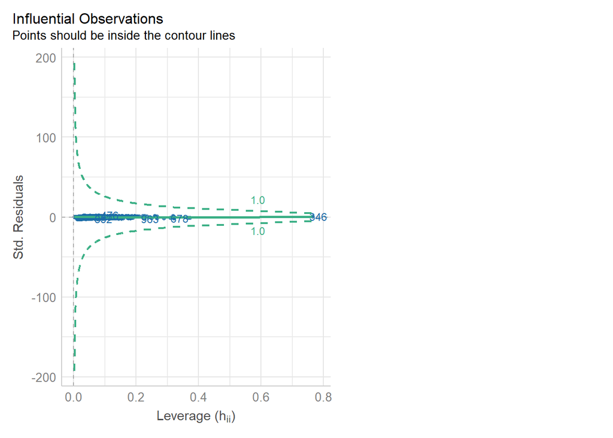

```r
performance::check_model(tice.logi,check=c('outliers'))
```

## Generate Table 2 of results of BLR.

BLR results in Table 2, including ORs, 95%CIs, and P values.

```r
tab_model(tice.logi,show.ci = 0.95,show.p = TRUE,show.re.var = FALSE,show.ngroups = FALSE,
          show.aic = FALSE,show.r2=FALSE,digits = 3,digits.re = 3)
```

|  | PFS |  |  |
| --- | --- | --- | --- |
| Predictors | Odds Ratios | CI | p |
| (Intercept) | 122.512 | 7.882 – 1980.627 | **0.001** |
| gender [Male] | 1.534 | 1.026 – 2.301 | **0.038** |
| age group | 1.497 | 1.259 – 1.785 | **<0.001** |
| region [Urban Manual Workers] | 0.854 | 0.583 – 1.250 | 0.418 |
| region [Urban Non-Manual Workers] | 1.201 | 0.837 – 1.720 | 0.319 |
| educational level | 1.378 | 1.102 – 1.726 | **0.005** |
| type of occupation [Clerical Staff] | 1.124 | 0.766 – 1.651 | 0.551 |
| type of occupation [Commercial and Service Industry Workers] | 1.648 | 0.942 – 2.947 | 0.085 |
| type of occupation [Agricultural Industry Workers] | 0.727 | 0.319 – 1.668 | 0.447 |
| type of occupation [Other Workers] | 1.479 | 0.884 – 2.510 | 0.141 |
| type of occupation [Unemployed] | 0.932 | 0.563 – 1.547 | 0.785 |
| minutes of taking vehicles per week | 1.000 | 0.990 – 1.011 | 0.934 |
| minutes of driving per week | 1.002 | 0.996 – 1.010 | 0.524 |
| minutes of riding motorcycle per week | 1.000 | 0.996 – 1.004 | 0.962 |
| minutes of riding bicycle per week | 1.004 | 0.998 – 1.010 | 0.219 |
| minutes by foot per week | 1.005 | 1.000 – 1.011 | 0.081 |
| other travel minutes per week | 1.050 | 0.949 – 1.370 | 0.518 |
| minutes of sedentary behavior per week | 1.000 | 0.998 – 1.001 | 0.637 |
| minutes with standing per week | 1.001 | 1.000 – 1.003 | 0.122 |
| minutes with walking per week | 1.000 | 0.998 – 1.002 | 0.808 |
| minutes to manual labor per week | 0.997 | 0.993 – 1.001 | 0.206 |
| other working minutes per week | 1.000 | 0.997 – 1.003 | 0.944 |
| minutes to watch TV per week | 0.997 | 0.994 – 1.000 | 0.071 |
| minutes to play chess per week | 1.004 | 0.995 – 1.012 | 0.333 |
| minutes to read books per week | 1.004 | 1.000 – 1.007 | 0.062 |
| minutes to stroll per week | 1.001 | 0.996 – 1.005 | 0.829 |
| minutes of light housework per week | 1.002 | 0.999 – 1.006 | 0.245 |
| minutes of heavy housework per week | 0.998 | 0.971 – 1.028 | 0.874 |
| other active minutes per week | 0.996 | 0.974 – 1.019 | 0.720 |
| hypertension [Yes] | 0.444 | 0.254 – 0.773 | **0.004** |
| hyperlipidemia [Yes] | 1.141 | 0.581 – 2.276 | 0.704 |
| high cholesterol [Yes] | 1.277 | 0.473 – 3.620 | 0.637 |
| diabetes [Yes] | 0.184 | 0.074 – 0.446 | **<0.001** |
| coronary heart disease [Yes] | 0.489 | 0.143 – 1.566 | 0.237 |
| peptic ulcer [Yes] | 0.551 | 0.164 – 1.986 | 0.344 |
| osteoarticular diseases [Yes] | 0.470 | 0.242 – 0.918 | **0.026** |
| cervical spondylosis [Yes] | 1.032 | 0.589 – 1.814 | 0.912 |
| occupational disease [Yes] | 2.858 | 0.683 – 20.402 | 0.207 |
| unknown [Yes] | 0.999 | 0.614 – 1.614 | 0.997 |
| no disease [Yes] | 0.766 | 0.451 – 1.302 | 0.323 |
| whether to exercise or not [Yes] | 2.390 | 1.322 – 4.323 | **0.004** |
| frequency of exercise | 1.017 | 0.921 – 1.122 | 0.738 |
| exercise time | 1.111 | 0.867 – 1.424 | 0.406 |
| feelings during exercise | 1.079 | 0.859 – 1.359 | 0.514 |
| exercise projects [Jogging] | 0.903 | 0.611 – 1.341 | 0.612 |
| exercise projects [Swimming] | 1.175 | 0.734 – 1.899 | 0.506 |
| exercise projects [Walking] | 1.000 | 0.349 – 3.167 | 0.999 |
| exercise projects [Ball] | 0.762 | 0.425 – 1.392 | 0.367 |
| exercise projects [Mountaineering] | 4.089 | 1.515 – 14.403 | **0.012** |
| exercise projects [Cycling] | 0.607 | 0.219 – 1.733 | 0.340 |
| exercise projects [Other] | 1.367 | 0.853 – 2.227 | 0.201 |
| exercise reasons [Recreation] | 1.123 | 0.693 – 1.850 | 0.642 |
| exercise reasons [Increase Physical Activity] | 1.066 | 0.498 – 2.386 | 0.872 |
| exercise reasons [Reduce Stress and Regulate Mood] | 1.212 | 0.645 – 2.352 | 0.558 |
| exercise reasons [Weight Loss] | 1.266 | 0.612 – 2.710 | 0.533 |
| exercise reasons [Bodybuilders] | 0.867 | 0.445 – 1.755 | 0.682 |
| exercise reasons [Prevent Disease] | 1.203 | 0.776 – 1.891 | 0.414 |
| exercise reasons [Other] | 1.683 | 0.797 – 3.773 | 0.187 |
| exercise disorders [Not Interested] | 1.055 | 0.511 – 2.277 | 0.888 |
| exercise disorders [Laziness] | 0.415 | 0.123 – 1.485 | 0.162 |
| exercise disorders [Not Advisable or Necessary to Participate] | 0.875 | 0.307 – 2.654 | 0.807 |
| exercise disorders [Lack of Time] | 1.178 | 0.306 – 5.973 | 0.824 |
| exercise disorders [Lack of On_Site Facilities] | 1.250 | 0.366 – 4.577 | 0.726 |
| exercise disorders [Lack of Guidance] | 1.061 | 0.397 – 3.113 | 0.909 |
| exercise disorders [Lack of Organization] | 0.857 | 0.299 – 2.728 | 0.783 |
| exercise disorders [Other] | 0.332 | 0.059 – 1.519 | 0.174 |
| chest circumference | 1.049 | 1.013 – 1.087 | **0.007** |
| waist circumference | 0.933 | 0.905 – 0.962 | **<0.001** |
| hip circumference | 0.967 | 0.931 – 1.003 | 0.077 |
| upper arm skin fold thickness | 0.988 | 0.964 – 1.013 | 0.349 |
| scapular skin fold thickness | 1.007 | 0.981 – 1.033 | 0.612 |
| abdomen skin fold thickness | 0.976 | 0.956 – 0.995 | **0.016** |
| resting heart rate | 0.977 | 0.965 – 0.988 | **<0.001** |
| systolic blood pressure | 1.004 | 0.992 – 1.017 | 0.524 |
| diastolic blood pressure | 0.995 | 0.978 – 1.014 | 0.608 |
| Observations | 1361 |  |  |

```r
estBeta <- tice.logi$coefficients %>% exp %>% round(.,digits = 3)
estBeta.ci <- tice.logi %>% confint %>% exp  %>% round(.,digits = 3)
matrix(paste0(estBeta,' (',estBeta.ci[,1],', ',estBeta.ci[,2],')',
              round(summary(tice.logi)$coefficients[,'Pr(>|z|)'],3)),dim(estBeta.ci),dimnames = dimnames(estBeta.ci)[1])
```

```
##                                                             [,1]
## (Intercept)                                                 "122.512 (7.882, 1980.627)0.001"
## genderMale                                                  "1.534 (1.026, 2.301)0.038"
## age_group                                                   "1.497 (1.259, 1.785)0"
## regionUrban Manual Workers                                  "0.854 (0.583, 1.25)0.418"
## regionUrban Non-Manual Workers                              "1.201 (0.837, 1.72)0.319"
## educational_level                                           "1.378 (1.102, 1.726)0.005"
## type_of_occupationClerical Staff                            "1.124 (0.766, 1.651)0.551"
## type_of_occupationCommercial and Service Industry Workers   "1.648 (0.942, 2.947)0.085"
## type_of_occupationAgricultural Industry Workers             "0.727 (0.319, 1.668)0.447"
## type_of_occupationOther Workers                             "1.479 (0.884, 2.51)0.141"
## type_of_occupationUnemployed                                "0.932 (0.563, 1.547)0.785"
## minutes_of_taking_vehicles_per_week                         "1 (0.99, 1.011)0.934"
## minutes_of_driving_per_week                                 "1.002 (0.996, 1.01)0.524"
## minutes_of_riding_motorcycle_per_week                       "1 (0.996, 1.004)0.962"
## minutes_of_riding_bicycle_per_week                          "1.004 (0.998, 1.01)0.219"
## minutes_by_foot_per_week                                    "1.005 (1, 1.011)0.081"
## other_travel_minutes_per_week                               "1.05 (0.949, 1.37)0.518"
## minutes_of_sedentary_behavior_per_week                      "1 (0.998, 1.001)0.637"
## minutes_with_standing_per_week                              "1.001 (1, 1.003)0.122"
## minutes_with_walking_per_week                               "1 (0.998, 1.002)0.808"
## minutes_to_manual_labor_per_week                            "0.997 (0.993, 1.001)0.206"
## other_working_minutes_per_week                              "1 (0.997, 1.003)0.944"
## minutes_to_watch_TV_per_week                                "0.997 (0.994, 1)0.071"
## minutes_to_play_chess_per_week                              "1.004 (0.995, 1.012)0.333"
## minutes_to_read_books_per_week                              "1.004 (1, 1.007)0.062"
## minutes_to_stroll_per_week                                  "1.001 (0.996, 1.005)0.829"
## minutes_of_light_housework_per_week                         "1.002 (0.999, 1.006)0.245"
## minutes_of_heavy_housework_per_week                         "0.998 (0.971, 1.028)0.874"
## other_active_minutes_per_week                               "0.996 (0.974, 1.019)0.72"
## hypertensionYes                                             "0.444 (0.254, 0.773)0.004"
## hyperlipidemiaYes                                           "1.141 (0.581, 2.276)0.704"
## high_cholesterolYes                                         "1.277 (0.473, 3.62)0.637"
## diabetesYes                                                 "0.184 (0.074, 0.446)0"
## coronary_heart_diseaseYes                                   "0.489 (0.143, 1.566)0.237"
## peptic_ulcerYes                                             "0.551 (0.164, 1.986)0.344"
## osteoarticular_diseasesYes                                  "0.47 (0.242, 0.918)0.026"
## cervical_spondylosisYes                                     "1.032 (0.589, 1.814)0.912"
## occupational_diseaseYes                                     "2.858 (0.683, 20.402)0.207"
## unknownYes                                                  "0.999 (0.614, 1.614)0.997"
```

[output cut: 21 more lines]

```
## exercise_disordersNot Advisable or Necessary to Participate "0.875 (0.307, 2.654)0.807"
## exercise_disordersLack of Time                              "1.178 (0.306, 5.973)0.824"
## exercise_disordersLack of On_Site Facilities                "1.25 (0.366, 4.577)0.726"
## exercise_disordersLack of Guidance                          "1.061 (0.397, 3.113)0.909"
## exercise_disordersLack of Organization                      "0.857 (0.299, 2.728)0.783"
## exercise_disordersOther                                     "0.332 (0.059, 1.519)0.174"
## chest_circumference                                         "1.049 (1.013, 1.087)0.007"
## waist_circumference                                         "0.933 (0.905, 0.962)0"
## hip_circumference                                           "0.967 (0.931, 1.003)0.077"
## upper_arm_skin_fold_thickness                               "0.988 (0.964, 1.013)0.349"
## scapular_skin_fold_thickness                                "1.007 (0.981, 1.033)0.612"
## abdomen_skin_fold_thickness                                 "0.976 (0.956, 0.995)0.016"
## resting_heart_rate                                          "0.977 (0.965, 0.988)0"
## systolic_blood_pressure                                     "1.004 (0.992, 1.017)0.524"
## diastolic_blood_pressure                                    "0.995 (0.978, 1.014)0.608"
```

## Plot figure 2

Sorted ORs of BLR.

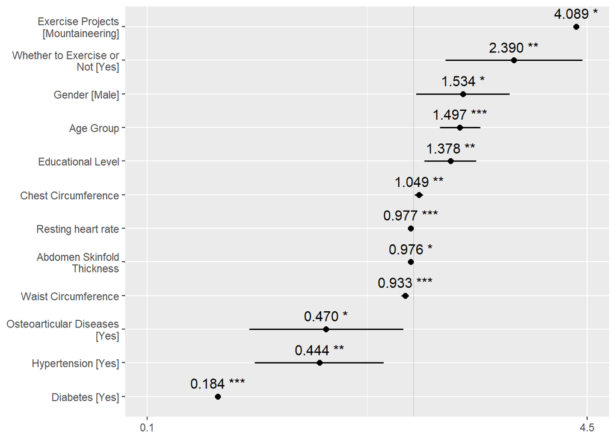

```r
plot_model(tice.logi
           ,vline.color = "grey"
           ,show.values = TRUE, value.offset = .4
           ,sort.est=T
           ,digits = 3
           ,rm.terms=c('regionUrban Manual Workers',
                       'regionUrban Non-Manual Workers',
                       'type_of_occupationClerical Staff',
                       'type_of_occupationCommercial and Service Industry Workers',
                       'type_of_occupationAgricultural Industry Workers',
                       'type_of_occupationOther Workers',
                       'type_of_occupationUnemployed',
                       'minutes_of_taking_vehicles_per_week',
                       'minutes_of_driving_per_week',
                       'minutes_of_riding_motorcycle_per_week',
                       'minutes_of_riding_bicycle_per_week',
                       'minutes_by_foot_per_week',
                       'other_travel_minutes_per_week',
                       'minutes_of_sedentary_behavior_per_week',
                       'minutes_with_standing_per_week',
                       'minutes_with_walking_per_week',
                       'minutes_to_manual_labor_per_week',
                       'other_working_minutes_per_week',
                       'minutes_to_read_books_per_week',
                       'minutes_to_watch_TV_per_week',
                       'minutes_to_play_chess_per_week',
                       'minutes_to_stroll_per_week',
                       'minutes_of_light_housework_per_week',
                       'minutes_of_heavy_housework_per_week',
                       'other_active_minutes_per_week',
                       'hyperlipidemiaYes',
                       'high_cholesterolYes',
                       'coronary_heart_diseaseYes',
                       'peptic_ulcerYes',
                       'cervical_spondylosisYes',
                       'occupational_diseaseYes',
                       'unknownYes',
                       'no_diseaseYes',
                       'frequency_of_exercise',
                       'exercise_time',
                       'feelings_during_exercise',
                       'exercise_projectsJogging',
                       'exercise_projectsSwimming',
                       'exercise_projectsWalking',
                       'exercise_projectsBall',
                       'exercise_projectsCycling',
                       'exercise_projectsOther',
                       'exercise_reasonsRecreation',
                       'exercise_reasonsIncrease Physical Activity',
                       'exercise_reasonsReduce Stress and Regulate Mood',
                       'exercise_reasonsWeight Loss',
                       'exercise_reasonsBodybuilders',
                       'exercise_reasonsPrevent Disease',
                       'exercise_reasonsOther',
                       'exercise_disordersNot Interested',
                       'exercise_disordersLaziness',
                       'exercise_disordersNot Advisable or Necessary to Participate',
                       'exercise_disordersLack of Time',
                       'exercise_disordersLack of On_Site Facilities',
                       'exercise_disordersLack of Guidance',
                       'exercise_disordersLack of Organization',
                       'exercise_disordersOther',
                       'hip_circumference',
                       'upper_arm_skin_fold_thickness',
                       'scapular_skin_fold_thickness',
                       'systolic_blood_pressure',
                       'diastolic_blood_pressure')
           ,title = ''
           ,axis.title =''
           ,colors = "black"
           ,grid.breaks = c(0.1,4.5)
           ,dot.size=2
           ,axis.labels = c(genderMale = 'Gender [Male]',
                            age_group = 'Age Group',
                            educational_level = 'Educational Level',
                            hypertensionYes = 'Hypertension [Yes]',
                            diabetesYes = "Diabetes [Yes]",
                            osteoarticular_diseasesYes = 'Osteoarticular Diseases [Yes]',
                            whether_to_exercise_or_notYes = 'Whether to Exercise or Not [Yes]',
                            exercise_projectsMountaineering = 'Exercise Projects [Mountaineering]',
                            chest_circumference = 'Chest Circumference',
                            waist_circumference = 'Waist Circumference',
                            abdomen_skin_fold_thickness = 'Abdomen Skinfold Thickness',
                            resting_heart_rate = "Resting heart rate")
)
```

Linear trend test for continuous variables in BLR.

```r
mydata.logi.out <- mydata.logi.out %>% mutate(
  age_group.ord.BLR = factor(cut(age_group,breaks = 4,labels=c(1,2,3,4)),ordered = T),
  educational_level.ord.BLR = factor(cut(educational_level,breaks = 4,labels=c(1,2,3,4)),ordered = T),
  chest_circumference.ord = factor(cut(chest_circumference,breaks = 4,labels=c(1,2,3,4)),ordered = T),
  waist_circumference.ord = factor(cut(waist_circumference,breaks = 4,labels=c(1,2,3,4)),ordered = T),
  abdomen_skin_fold_thickness.ord = factor(cut(abdomen_skin_fold_thickness,breaks = 4,labels=c(1,2,3,4)),ordered = T),
  resting_heart_rate.ord = factor(cut(resting_heart_rate,breaks = 4,labels=c(1,2,3,4)),ordered = T),
  )
```

```r
summary(update(tice.logi, . ~ . - age_group + age_group.ord.BLR))$coefficients[c('age_group.ord.BLR.L','age_group.ord.BLR.Q'),]
```

```
##                     Estimate Std. Error z value   Pr(>|z|)
## age_group.ord.BLR.L  0.89925    0.19785  4.5451 5.4910e-06
## age_group.ord.BLR.Q -0.38861    0.15212 -2.5547 1.0627e-02
```

```r
summary(update(tice.logi, . ~ . - educational_level + educational_level.ord.BLR))$coefficients[c('educational_level.ord.BLR.L','educational_level.ord.BLR.Q'),]
```

```
##                             Estimate Std. Error z value  Pr(>|z|)
## educational_level.ord.BLR.L 0.454391    0.16187 2.80713 0.0049985
## educational_level.ord.BLR.Q 0.024289    0.12612 0.19258 0.8472877
```

```r
summary(update(tice.logi, . ~ . - chest_circumference + chest_circumference.ord))$coefficients[c('chest_circumference.ord.L','chest_circumference.ord.Q'),]
```

```
##                           Estimate Std. Error   z value Pr(>|z|)
## chest_circumference.ord.L  -7.2601     303.22 -0.023944  0.98090
## chest_circumference.ord.Q   7.0467     226.00  0.031179  0.97513
```

```r
summary(update(tice.logi, . ~ . - waist_circumference + waist_circumference.ord))$coefficients[c('waist_circumference.ord.L','waist_circumference.ord.Q'),]
```

```
##                           Estimate Std. Error  z value Pr(>|z|)
## waist_circumference.ord.L -0.41101    0.92730 -0.44323  0.65760
## waist_circumference.ord.Q -0.80477    0.63561 -1.26614  0.20546
```

```r
summary(update(tice.logi, . ~ . - abdomen_skin_fold_thickness + abdomen_skin_fold_thickness.ord))$coefficients[c('abdomen_skin_fold_thickness.ord.L','abdomen_skin_fold_thickness.ord.Q'),]
```

```
##                                   Estimate Std. Error z value Pr(>|z|)
## abdomen_skin_fold_thickness.ord.L -1.76195    0.62177 -2.8338 0.004600
## abdomen_skin_fold_thickness.ord.Q -0.88959    0.44129 -2.0159 0.043812
```

```r
summary(update(tice.logi, . ~ . - abdomen_skin_fold_thickness + abdomen_skin_fold_thickness.ord))$coefficients[c('abdomen_skin_fold_thickness.ord.L','abdomen_skin_fold_thickness.ord.Q'),]
```

```
##                                   Estimate Std. Error z value Pr(>|z|)
## abdomen_skin_fold_thickness.ord.L -1.76195    0.62177 -2.8338 0.004600
## abdomen_skin_fold_thickness.ord.Q -0.88959    0.44129 -2.0159 0.043812
```

## Plot S6

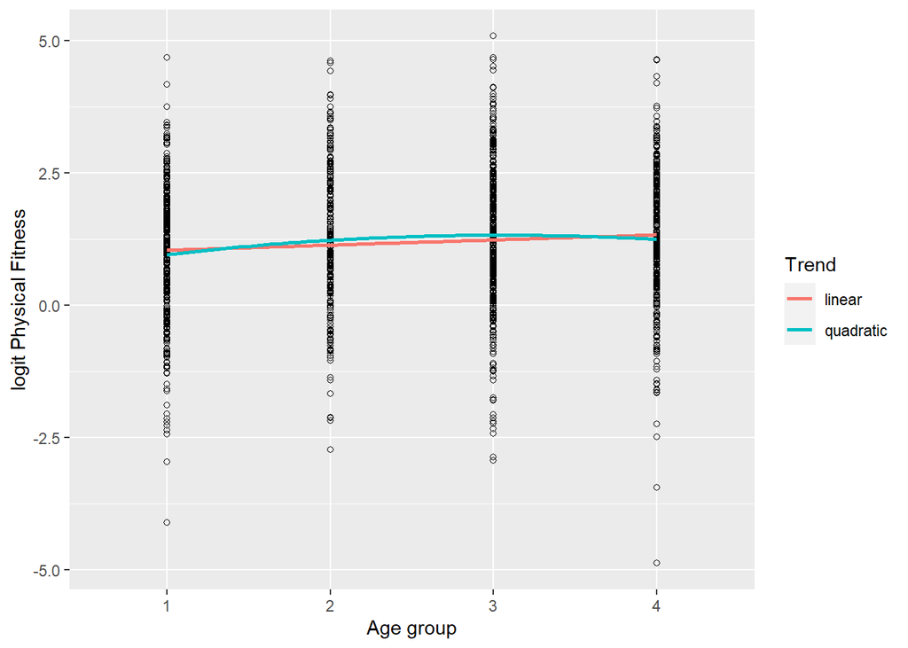

```r
ggplot(mydata.logi.out) +
  aes(x = age_group.ord.BLR, y = logitP) +
  geom_point(shape = 1) +
  geom_smooth(aes(x = unclass(age_group.ord.BLR), color = "1"),
              formula = y ~ x,
              method = lm, se = FALSE) +
  geom_smooth(aes(x = unclass(age_group.ord.BLR), color = "2"),
              formula = y ~ x + poly(x, 2),
              method = lm, se = FALSE) +
  scale_color_discrete("Trend", labels = c("linear", "quadratic")) +
  labs(x = 'Age group',y = 'logit Physical Fitness')
```

## Generate figure s5 of results of BLR.

```r
attach(mydata.logi.out)
xz_BLR <-data.frame(chest_circumference,waist_circumference,PFS)
dd_BLR <- datadist(xz_BLR)
options(datadist='dd_BLR')
```

Restricted cubic spline analisis of chest circumference.

```r
fit_BLR_1 <-lrm(PFS ~ rcs(chest_circumference, 4),data=xz_BLR)
anova(fit_BLR_1)
```

```
##                 Wald Statistics          Response: PFS
##
##  Factor              Chi-Square d.f. P
##  chest_circumference 108.09     3    <.0001
##   Nonlinear           53.76     2    <.0001
##  TOTAL               108.09     3    <.0001
```

```r
an<-anova(fit_BLR_1)
pred <- Predict(fit_BLR_1, chest_circumference, fun=exp)
print(pred)
```

```
##     chest_circumference    yhat   lower  upper
## 1                75.995 1.23568 0.73294 2.0833
## 2                76.196 1.27461 0.76406 2.1263
## 3                76.397 1.31477 0.79647 2.1704
## 4                76.598 1.35620 0.83020 2.2155
## 5                76.799 1.39893 0.86532 2.2616
## 6                77.000 1.44301 0.90187 2.3088
## 7                77.201 1.48848 0.93991 2.3572
## 8                77.402 1.53538 0.97948 2.4068
## 9                77.603 1.58375 1.02065 2.4575
## 10               77.804 1.63366 1.06346 2.5096
## 11               78.005 1.68513 1.10798 2.5629
## 12               78.206 1.73823 1.15426 2.6176
## 13               78.407 1.79299 1.20235 2.6738
## 14               78.608 1.84949 1.25233 2.7314
```

[output cut: 190 more lines]

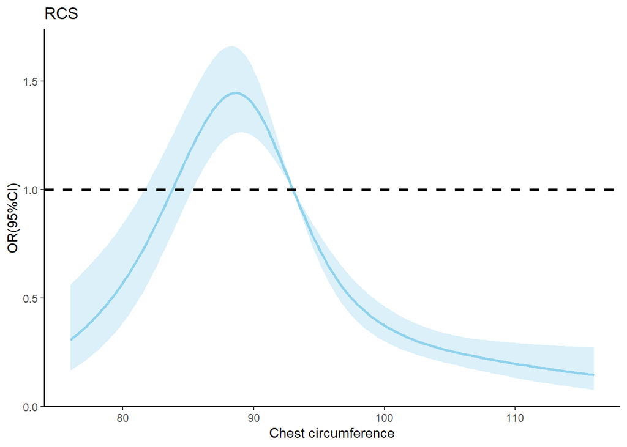

```r
dd_BLR$limits$chest_circumference[2] <-88
fit1=update(fit_BLR_1)
OR1<-Predict(fit_BLR_1, chest_circumference,fun=exp,ref.zero = TRUE)
ggplot()+geom_line(data=OR1, aes(chest_circumference,yhat),linetype=1,size=1,alpha = 0.9,colour="skyblue")+
  geom_ribbon(data=OR1, aes(chest_circumference,ymin = lower, ymax = upper),alpha = 0.3,fill="skyblue")+
  geom_hline(yintercept=1, linetype=2,size=1)+theme_classic()+
  labs(title = "RCS", x="Chest circumference", y="OR(95%CI)")
```

Restricted cubic spline analisis of waist circumference.

```r
fit_BLR_2 <-lrm(PFS ~ rcs(waist_circumference, 4),data=xz_BLR)
anova(fit_BLR_2)
```

```
##                 Wald Statistics          Response: PFS
##
##  Factor              Chi-Square d.f. P
##  waist_circumference 145.3      3    <.0001
##   Nonlinear           52.7      2    <.0001
##  TOTAL               145.3      3    <.0001
```

```r
an<-anova(fit_BLR_2)
pred <- Predict(fit_BLR_2, waist_circumference, fun=exp)
print(pred)
```

```
##     waist_circumference    yhat   lower   upper
## 1                61.000 2.04611 1.22760 3.41038
## 2                61.269 2.09665 1.27191 3.45616
## 3                61.538 2.14843 1.31774 3.50279
## 4                61.807 2.20149 1.36511 3.55031
## 5                62.075 2.25587 1.41408 3.59877
## 6                62.344 2.31159 1.46468 3.64819
## 7                62.613 2.36868 1.51695 3.69863
## 8                62.882 2.42718 1.57093 3.75014
## 9                63.151 2.48713 1.62667 3.80275
## 10               63.420 2.54856 1.68419 3.85654
## 11               63.689 2.61151 1.74354 3.91157
## 12               63.957 2.67601 1.80474 3.96790
## 13               64.226 2.74210 1.86782 4.02561
## 14               64.495 2.80983 1.93282 4.08478
```

[output cut: 190 more lines]

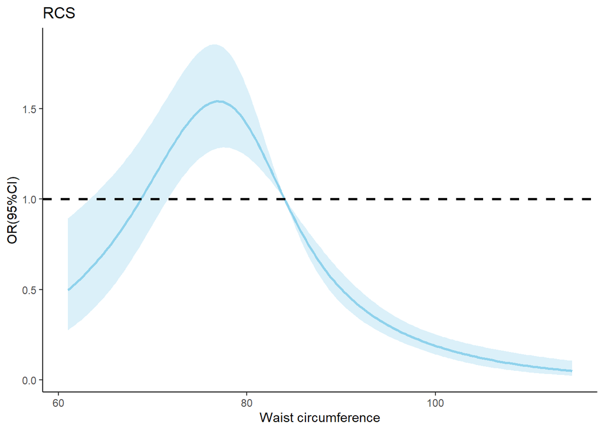

```r
dd_BLR$limits$waist_circumference[2] <-77
fit2=update(fit_BLR_2)
OR2<-Predict(fit_BLR_2, waist_circumference,fun=exp,ref.zero = TRUE)
ggplot()+geom_line(data=OR2, aes(waist_circumference,yhat),linetype=1,size=1,alpha = 0.9,colour="skyblue")+
  geom_ribbon(data=OR2, aes(waist_circumference,ymin = lower, ymax = upper),alpha = 0.3,fill="skyblue")+
  geom_hline(yintercept=1, linetype=2,size=1)+theme_classic()+
  labs(title = "RCS", x="Waist circumference", y="OR(95%CI)")
```

## Plot Figure S4.

ROC of BLR.

```r
predict_<-predict.glm(tice.logi,type='response',newdata = mydata.logi.out)
modelroc <- roc(mydata.logi.out$PFS,predict_)
```

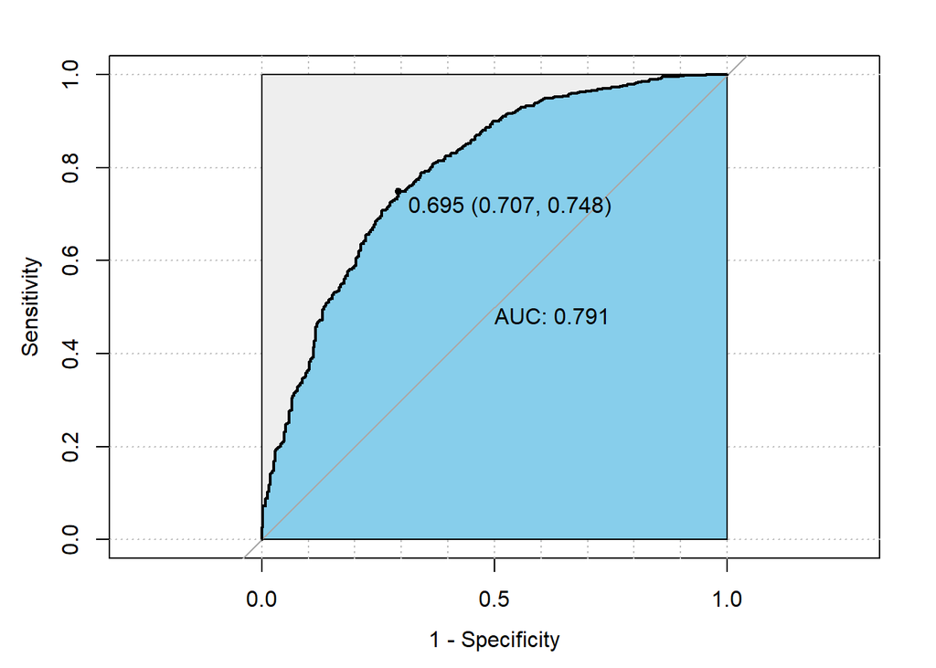

```r
plot(modelroc
     ,print.auc=TRUE
     ,auc.polygon=TRUE
     ,legacy.axes=TRUE
     ,grid=c(0.1, 0.2)     ,grid.col=c("grey", "grey")
     ,max.auc.polygon=TRUE
     ,auc.polygon.col="skyblue"
     ,print.thres=TRUE
)
```

## Weighted linear mixed model (Weighted LMM)

The regression diagnostics were processed with the following steps:

1. Check outliners.
2. Detect multicollinearity.
3. Check the independence of residuals with Durbin-Waston’s test.
4. Detect the homoscedasticity of residuals.
5. Significance of random effects was checked by likelihood ratio test.
6. Check the linear relationship between the dependent and explanatory variables.

```r
mixed.reg.formula <- as.formula(
  TPTS ~ gender  + type_of_occupation + minutes_of_taking_vehicles_per_week
  + minutes_of_driving_per_week + minutes_of_riding_motorcycle_per_week + minutes_of_riding_bicycle_per_week + minutes_by_foot_per_week
  + other_travel_minutes_per_week+ minutes_of_sedentary_behavior_per_week + minutes_with_standing_per_week + minutes_with_walking_per_week
  + minutes_to_manual_labor_per_week + other_working_minutes_per_week + minutes_to_watch_TV_per_week + minutes_to_play_chess_per_week
  + minutes_to_read_books_per_week + minutes_to_stroll_per_week + minutes_of_light_housework_per_week + minutes_of_heavy_housework_per_week
  + other_active_minutes_per_week + hypertension + hyperlipidemia + high_cholesterol + diabetes + coronary_heart_disease + peptic_ulcer
  + osteoarticular_diseases + cervical_spondylosis + occupational_disease + unknown + no_disease + frequency_of_exercise
  + feelings_during_exercise + exercise_projects + exercise_reasons + exercise_disorders + chest_circumference + waist_circumference + hip_circumference + upper_arm_skin_fold_thickness
  + scapular_skin_fold_thickness + abdomen_skin_fold_thickness + resting_heart_rate + systolic_blood_pressure + diastolic_blood_pressure
  + (1|age_group.ord) + (1|region) + (1|educational_level.ord) + (1|whether_to_exercise_or_not) + (1|exercise_time.ord)
)
mixedmodel <- lmer(
  data = mydata
  ,formula = mixed.reg.formula
  ,control = lmerControl(optimizer = "bobyqa"))
```

Detect outliers for LMM.

```r
performance::check_outliers(mixedmodel)
```

```
## OK: No outliers detected.
## - Based on the following method and threshold: cook (1).
## - For variable: (Whole model)
```

Detect multicollinearity.

```r
performance::check_collinearity(mixedmodel)
```

```
## # Check for Multicollinearity
##
## Low Correlation
##
##                                    Term  VIF   VIF 95% CI Increased SE
##                                  gender 1.98 [1.85, 2.15]         1.41
##                      type_of_occupation 2.30 [2.13, 2.49]         1.52
##     minutes_of_taking_vehicles_per_week 1.07 [1.03, 1.16]         1.03
##             minutes_of_driving_per_week 1.13 [1.08, 1.21]         1.06
##   minutes_of_riding_motorcycle_per_week 1.11 [1.06, 1.19]         1.05
##      minutes_of_riding_bicycle_per_week 1.06 [1.03, 1.15]         1.03
##                minutes_by_foot_per_week 1.14 [1.09, 1.23]         1.07
##           other_travel_minutes_per_week 1.08 [1.04, 1.17]         1.04
##  minutes_of_sedentary_behavior_per_week 1.37 [1.29, 1.47]         1.17
##          minutes_with_standing_per_week 1.34 [1.26, 1.43]         1.16
##           minutes_with_walking_per_week 1.16 [1.10, 1.24]         1.08
##        minutes_to_manual_labor_per_week 1.13 [1.08, 1.21]         1.06
##          other_working_minutes_per_week 1.20 [1.14, 1.28]         1.09
##            minutes_to_watch_TV_per_week 1.11 [1.07, 1.20]         1.06
##          minutes_to_play_chess_per_week 1.09 [1.04, 1.17]         1.04
##          minutes_to_read_books_per_week 1.16 [1.10, 1.24]         1.08
##              minutes_to_stroll_per_week 1.13 [1.08, 1.22]         1.06
##     minutes_of_light_housework_per_week 1.21 [1.15, 1.30]         1.10
##     minutes_of_heavy_housework_per_week 1.11 [1.06, 1.19]         1.05
##           other_active_minutes_per_week 1.05 [1.02, 1.15]         1.03
##                            hypertension 1.67 [1.56, 1.79]         1.29
##                          hyperlipidemia 1.40 [1.32, 1.50]         1.18
##                        high_cholesterol 1.29 [1.22, 1.38]         1.14
##                                diabetes 1.19 [1.13, 1.28]         1.09
##                  coronary_heart_disease 1.13 [1.08, 1.21]         1.06
##                            peptic_ulcer 1.15 [1.09, 1.23]         1.07
##                 osteoarticular_diseases 1.26 [1.19, 1.35]         1.12
##                    cervical_spondylosis 1.64 [1.54, 1.77]         1.28
##                    occupational_disease 1.16 [1.10, 1.24]         1.08
##                                 unknown 2.75 [2.54, 2.99]         1.66
##                              no_disease 1.57 [1.48, 1.69]         1.25
##                   frequency_of_exercise 1.19 [1.14, 1.28]         1.09
##                feelings_during_exercise 1.21 [1.15, 1.30]         1.10
##                       exercise_projects 1.78 [1.67, 1.92]         1.34
##                        exercise_reasons 1.94 [1.80, 2.09]         1.39
```

[output cut: 44 more lines]

```
##       0.52     [0.48, 0.56]
##       0.51     [0.47, 0.54]
##       0.23     [0.21, 0.25]
##       0.28     [0.25, 0.30]
##       0.44     [0.41, 0.48]
##       0.40     [0.37, 0.44]
##       0.38     [0.35, 0.41]
##       0.88     [0.82, 0.93]
##       0.40     [0.37, 0.44]
##       0.43     [0.40, 0.46]
##
## Moderate Correlation
##
##                 Term  VIF   VIF 95% CI Increased SE Tolerance Tolerance 95% CI
##  waist_circumference 6.41 [5.85, 7.04]         2.53      0.16     [0.14, 0.17]
```

Check independence of residuals by Durbin-Waston’s test.

```r
performance::check_autocorrelation(mixedmodel)
```

```
## OK: Residuals appear to be independent and not autocorrelated (p = 0.424).
```

Check heteroscedasticity of residuals.

```r
performance::check_heteroscedasticity(mixedmodel)
```

Implement weighted LMM. Define weightes as weighted MLR.

```r
wt <- 1 / lm(abs(summary(mixedmodel)$residuals) ~ predict(mixedmodel))$fitted.values^2
mixedmodel.wt <- lmer(
  data     = mydata
  ,formula = mixed.reg.formula
  ,weights = wt
  ,control = lmerControl(optimizer = "bobyqa")
)
```

Check significance of random effects by likelihood ratio test.

```r
ranova(mixedmodel.wt)
```

```
## ANOVA-like table for random-effects: Single term deletions
##
## Model:
## TPTS ~ gender + type_of_occupation + minutes_of_taking_vehicles_per_week + minutes_of_driving_per_week + minutes_of_riding_motorcycle_per_week + minutes_of_riding_bicycle_per_week + minutes_by_foot_per_week + other_travel_minutes_per_week + minutes_of_sedentary_behavior_per_week + minutes_with_st…
##                                  npar logLik  AIC   LRT Df Pr(>Chisq)
## <none>                             75  -4099 8348
## (1 | age_group.ord)                74  -4184 8515 169.4  1     <2e-16 ***
## (1 | region)                       74  -4100 8347   1.7  1     0.1880
## (1 | educational_level.ord)        74  -4103 8355   9.2  1     0.0025 **
## (1 | whether_to_exercise_or_not)   74  -4101 8351   5.0  1     0.0248 *
## (1 | exercise_time.ord)            74  -4101 8349   3.9  1     0.0494 *
## ---
## Signif. codes:  0 '***' 0.001 '**' 0.01 '*' 0.05 '.' 0.1 ' ' 1
```

The likelihood ratio test showed that the variable “region” was not statistically significant as a random effect, so region was removed from the random effects.

```r
mixedmodel.wt.ep <- update(mixedmodel.wt
                              , . ~ . - (1 |region) + region )

anova(mixedmodel.wt,mixedmodel.wt.ep)
```

```
## refitting model(s) with ML (instead of REML)
```

```
## Data: mydata
## Models:
## mixedmodel.wt: mixed.reg.formula
## mixedmodel.wt.ep: TPTS ~ gender + type_of_occupation + minutes_of_taking_vehicles_per_week + minutes_of_driving_per_week + minutes_of_riding_motorcycle_per_week + minutes_of_riding_bicycle_per_week + minutes_by_foot_per_week + other_travel_minutes_per_week + minutes_of_sedentary_behavior_per_week…
##                  npar  AIC  BIC logLik deviance Chisq Df Pr(>Chisq)
## mixedmodel.wt      75 8168 8559  -4009     8018
## mixedmodel.wt.ep   76 8166 8562  -4007     8014  4.46  1      0.035 *
## ---
## Signif. codes:  0 '***' 0.001 '**' 0.01 '*' 0.05 '.' 0.1 ' ' 1
```

```r
ranova(mixedmodel.wt.ep)
```

```
## ANOVA-like table for random-effects: Single term deletions
##
## Model:
## TPTS ~ gender + type_of_occupation + minutes_of_taking_vehicles_per_week + minutes_of_driving_per_week + minutes_of_riding_motorcycle_per_week + minutes_of_riding_bicycle_per_week + minutes_by_foot_per_week + other_travel_minutes_per_week + minutes_of_sedentary_behavior_per_week + minutes_with_st…
##                                  npar logLik  AIC   LRT Df Pr(>Chisq)
## <none>                             76  -4097 8346
## (1 | age_group.ord)                75  -4182 8515 170.6  1     <2e-16 ***
## (1 | educational_level.ord)        75  -4102 8353   8.7  1     0.0031 **
## (1 | whether_to_exercise_or_not)   75  -4100 8349   5.1  1     0.0236 *
## (1 | exercise_time.ord)            75  -4099 8348   4.1  1     0.0440 *
## ---
## Signif. codes:  0 '***' 0.001 '**' 0.01 '*' 0.05 '.' 0.1 ' ' 1
```

## Table S4

Compare performance of LMM and weighted LMM.

```r
performance::compare_performance(mixedmodel,mixedmodel.wt.ep)
```

```
## # Comparison of Model Performance Indices
##
## Name             |           Model |  AIC (weights) | AICc (weights) |  BIC (weights) | R2 (cond.) | R2 (marg.) |   ICC |  RMSE | Sigma
## ---------------------------------------------------------------------------------------------------------------------------------------
## mixedmodel       | lmerModLmerTest | 8185.1 (<.001) | 8194.0 (<.001) | 8576.3 (<.001) |      0.447 |      0.190 | 0.318 | 4.559 | 4.695
## mixedmodel.wt.ep | lmerModLmerTest | 8165.7 (>.999) | 8174.9 (>.999) | 8562.2 (0.999) |      0.325 |      0.144 | 0.211 | 4.563 | 5.956
```

## Plot Figure S3.

The performance of linearity, homoscedasticity, normality, and extreme values after diagnostics of weighte LMM.

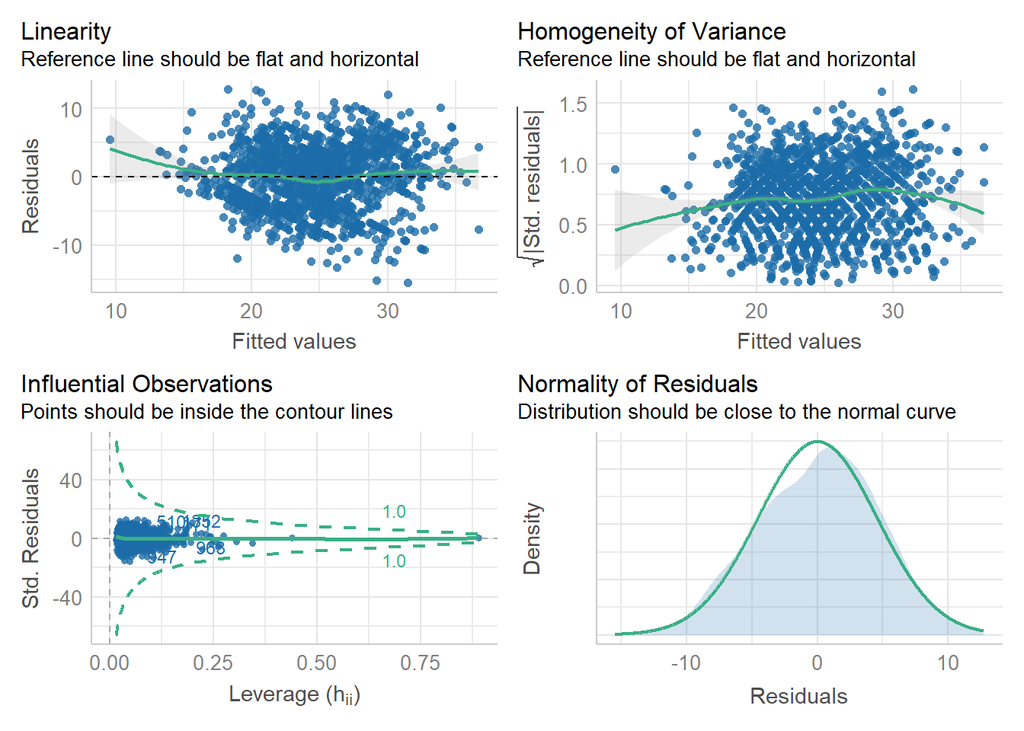

```r
performance::check_model(mixedmodel.wt.ep,check=c('normality','linearity','homogeneity','outliers'))
```

## Generate Table 3 of results of weighted LMM.

```r
tab_model(mixedmodel.wt.ep,show.ci = 0.95,show.p = TRUE,show.re.var = TRUE,show.ngroups = FALSE,
          show.aic = FALSE,show.r2=FALSE,digits = 3,digits.re = 3)
```

|  | TPTS |  |  |
| --- | --- | --- | --- |
| Predictors | Estimates | CI | p |
| (Intercept) | 35.279 | 29.501 – 41.057 | **<0.001** |
| gender [Male] | 1.294 | 0.568 – 2.020 | **<0.001** |
| type of occupation [Clerical Staff] | 0.582 | -0.116 – 1.280 | 0.102 |
| type of occupation [Commercial and Service Industry Workers] | 0.450 | -0.550 – 1.449 | 0.377 |
| type of occupation [Agricultural Industry Workers] | -1.821 | -3.376 – -0.266 | **0.022** |
| type of occupation [Other Workers] | 0.140 | -0.804 – 1.083 | 0.771 |
| type of occupation [Unemployed] | -0.163 | -1.086 – 0.761 | 0.730 |
| minutes of taking vehicles per week | -0.006 | -0.026 – 0.015 | 0.591 |
| minutes of driving per week | -0.001 | -0.012 – 0.011 | 0.880 |
| minutes of riding motorcycle per week | -0.003 | -0.010 – 0.003 | 0.328 |
| minutes of riding bicycle per week | 0.004 | -0.004 – 0.013 | 0.316 |
| minutes by foot per week | 0.007 | -0.002 – 0.016 | 0.135 |
| other travel minutes per week | 0.138 | -0.071 – 0.348 | 0.196 |
| minutes of sedentary behavior per week | -0.002 | -0.005 – 0.001 | 0.114 |
| minutes with standing per week | 0.001 | -0.002 – 0.003 | 0.719 |
| minutes with walking per week | -0.000 | -0.004 – 0.004 | 0.943 |
| minutes to manual labor per week | -0.006 | -0.014 – 0.002 | 0.116 |
| other working minutes per week | 0.007 | 0.001 – 0.013 | **0.014** |
| minutes to watch TV per week | -0.003 | -0.008 – 0.003 | 0.326 |
| minutes to play chess per week | 0.002 | -0.011 – 0.016 | 0.735 |
| minutes to read books per week | 0.006 | -0.000 – 0.013 | 0.053 |
| minutes to stroll per week | 0.003 | -0.005 – 0.012 | 0.454 |
| minutes of light housework per week | 0.006 | -0.000 – 0.012 | 0.060 |
| minutes of heavy housework per week | 0.045 | -0.009 – 0.100 | 0.105 |
| other active minutes per week | 0.005 | -0.038 – 0.049 | 0.819 |
| hypertension [Yes] | -0.911 | -1.921 – 0.100 | 0.077 |
| hyperlipidemia [Yes] | -0.600 | -1.800 – 0.599 | 0.326 |
| high cholesterol [Yes] | 0.780 | -0.891 – 2.451 | 0.360 |
| diabetes [Yes] | -1.852 | -3.479 – -0.224 | **0.026** |
| coronary heart disease [Yes] | -1.562 | -3.671 – 0.548 | 0.147 |
| peptic ulcer [Yes] | -0.651 | -2.912 – 1.611 | 0.572 |
| osteoarticular diseases [Yes] | -1.127 | -2.326 – 0.072 | 0.065 |
| cervical spondylosis [Yes] | 0.308 | -0.698 – 1.314 | 0.548 |
| occupational disease [Yes] | 0.653 | -1.488 – 2.794 | 0.550 |
| unknown [Yes] | -0.241 | -1.106 – 0.624 | 0.584 |
| no disease [Yes] | -0.650 | -1.617 – 0.317 | 0.188 |
| frequency of exercise | 0.129 | -0.046 – 0.303 | 0.148 |
| feelings during exercise | -0.081 | -0.500 – 0.338 | 0.705 |
| exercise projects [Jogging] | 0.001 | -0.740 – 0.743 | 0.997 |
| exercise projects [Swimming] | 0.397 | -0.473 – 1.268 | 0.371 |
| exercise projects [Walking] | -0.062 | -2.035 – 1.911 | 0.951 |
| exercise projects [Ball] | -0.133 | -1.253 – 0.987 | 0.816 |
| exercise projects [Mountaineering] | 2.473 | 1.074 – 3.871 | **0.001** |
| exercise projects [Cycling] | 0.025 | -1.995 – 2.045 | 0.981 |
| exercise projects [Other] | 1.149 | 0.310 – 1.987 | **0.007** |
| exercise reasons [Recreation] | -0.312 | -1.206 – 0.583 | 0.495 |
| exercise reasons [Increase Physical Activity] | -0.363 | -1.775 – 1.049 | 0.614 |
| exercise reasons [Reduce Stress and Regulate Mood] | 0.494 | -0.641 – 1.629 | 0.393 |
| exercise reasons [Weight Loss] | -0.160 | -1.505 – 1.185 | 0.816 |
| exercise reasons [Bodybuilders] | 0.046 | -1.217 – 1.310 | 0.943 |
| exercise reasons [Prevent Disease] | 0.270 | -0.506 – 1.046 | 0.495 |
| exercise reasons [Other] | 0.883 | -0.478 – 2.244 | 0.203 |
| exercise disorders [Not Interested] | 0.179 | -1.172 – 1.530 | 0.795 |
| exercise disorders [Laziness] | -1.270 | -3.706 – 1.166 | 0.307 |
| exercise disorders [Not Advisable or Necessary to Participate] | -1.027 | -3.125 – 1.071 | 0.337 |
| exercise disorders [Lack of Time] | 0.247 | -2.368 – 2.862 | 0.853 |
| exercise disorders [Lack of On_Site Facilities] | 0.164 | -2.204 – 2.532 | 0.892 |
| exercise disorders [Lack of Guidance] | 1.142 | -0.806 – 3.090 | 0.250 |
| exercise disorders [Lack of Organization] | -1.199 | -3.168 – 0.770 | 0.232 |
| exercise disorders [Other] | 0.131 | -2.648 – 2.910 | 0.926 |
| chest circumference | 0.127 | 0.065 – 0.190 | **<0.001** |
| waist circumference | -0.174 | -0.230 – -0.118 | **<0.001** |
| hip circumference | -0.036 | -0.101 – 0.030 | 0.285 |
| upper arm skin fold thickness | -0.034 | -0.079 – 0.011 | 0.142 |
| scapular skin fold thickness | -0.035 | -0.083 – 0.013 | 0.156 |
| abdomen skin fold thickness | -0.054 | -0.091 – -0.016 | **0.005** |
| resting heart rate | -0.046 | -0.069 – -0.024 | **<0.001** |
| systolic blood pressure | 0.010 | -0.013 – 0.033 | 0.382 |
| diastolic blood pressure | -0.018 | -0.052 – 0.015 | 0.284 |
| region [Urban Manual Workers] | -0.576 | -1.298 – 0.145 | 0.117 |
| region [Urban Non-Manual Workers] | 0.234 | -0.425 – 0.893 | 0.486 |
| Random Effects |  |  |  |
| σ<sup>2</sup> | 35.478 |  |  |
| τ<sub>00</sub> <sub>age_group.ord</sub> | 7.302 |  |  |
| τ<sub>00</sub> <sub>exercise_time.ord</sub> | 0.448 |  |  |
| τ<sub>00</sub> <sub>educational_level.ord</sub> | 0.566 |  |  |
| τ<sub>00</sub> <sub>whether_to_exercise_or_not</sub> | 1.195 |  |  |
| ICC | 0.211 |  |  |
| Observations | 1361 |  |  |

Linear trend test for continuous variables in weighted LMM.

```r
mydata <- mydata %>% mutate(
  other_working_minutes_per_week.ord = factor(cut(other_working_minutes_per_week,breaks = 4,labels=c(1,2,3,4)),ordered = T),
  chest_circumference.ord = factor(cut(chest_circumference,breaks = 4,labels=c(1,2,3,4)),ordered = T),
  waist_circumference.ord = factor(cut(waist_circumference,breaks = 4,labels=c(1,2,3,4)),ordered = T),
  abdomen_skin_fold_thickness.ord = factor(cut(abdomen_skin_fold_thickness,breaks = 4,labels=c(1,2,3,4)),ordered = T),
  resting_heart_rate.ord = factor(cut(resting_heart_rate,breaks = 4,labels=c(1,2,3,4)),ordered = T),
 )
```

```r
summary(update(mixedmodel.wt.ep, . ~ . - other_working_minutes_per_week + other_working_minutes_per_week.ord))$coefficients[c('other_working_minutes_per_week.ord.L','other_working_minutes_per_week.ord.Q'),]
```

```
##                                      Estimate Std. Error     df t value
## other_working_minutes_per_week.ord.L   2.6311     0.8788 1281.5  2.9940
## other_working_minutes_per_week.ord.Q   1.3267     1.1853 1282.4  1.1193
##                                       Pr(>|t|)
## other_working_minutes_per_week.ord.L 0.0028062
## other_working_minutes_per_week.ord.Q 0.2632355
```

```r
summary(update(mixedmodel.wt.ep, . ~ . - chest_circumference + chest_circumference.ord))$coefficients[c('chest_circumference.ord.L','chest_circumference.ord.Q'),]
```

```
##                           Estimate Std. Error     df t value Pr(>|t|)
## chest_circumference.ord.L   1.4859     2.3592 1283.3 0.62981  0.52893
## chest_circumference.ord.Q   2.0574     1.7286 1282.3 1.19020  0.23419
```

```r
summary(update(mixedmodel.wt.ep, . ~ . - waist_circumference + waist_circumference.ord))$coefficients[c('waist_circumference.ord.L','waist_circumference.ord.Q'),]
```

```
##                           Estimate Std. Error     df  t value Pr(>|t|)
## waist_circumference.ord.L -0.83053     1.6607 1280.8 -0.50011 0.617082
## waist_circumference.ord.Q -2.31902     1.1102 1281.0 -2.08877 0.036926
```

```r
summary(update(mixedmodel.wt.ep, . ~ . - abdomen_skin_fold_thickness + abdomen_skin_fold_thickness.ord))$coefficients[c('abdomen_skin_fold_thickness.ord.L','abdomen_skin_fold_thickness.ord.Q'),]
```

```
##                                   Estimate Std. Error     df t value Pr(>|t|)
## abdomen_skin_fold_thickness.ord.L -2.28407    0.89269 1281.3 -2.5586 0.010623
## abdomen_skin_fold_thickness.ord.Q -0.63196    0.60187 1281.7 -1.0500 0.293918
```

```r
summary(update(mixedmodel.wt.ep, . ~ . - resting_heart_rate + resting_heart_rate.ord))$coefficients[c('resting_heart_rate.ord.L','resting_heart_rate.ord.Q'),]
```

```
##                          Estimate Std. Error     df t value Pr(>|t|)
## resting_heart_rate.ord.L -1.60132    0.69841 1281.1 -2.2928  0.02202
## resting_heart_rate.ord.Q  0.79142    0.52730 1280.5  1.5009  0.13363
```

## Plot Figure S7.

The trend graph between chest circumference and TPTS in weighted LMM.

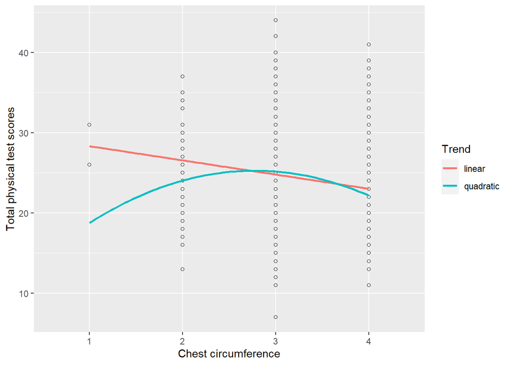

```r
ggplot(mydata) +
  aes(x = chest_circumference.ord, y = TPTS) +
  geom_point(shape = 1) +
  geom_smooth(aes(x = unclass(chest_circumference.ord), color = "1"),
              formula = y ~ x,
              method = lm, se = FALSE) +
  geom_smooth(aes(x = unclass(chest_circumference.ord), color = "2"),
              formula = y ~ x + poly(x, 2),
              method = lm, se = FALSE) +
  scale_color_discrete("Trend", labels = c("linear", "quadratic")) +
  labs(x = 'Chest circumference',y = 'Total physical test scores')
```

The trend graph between waist circumference and TPTS in weighted LMM.

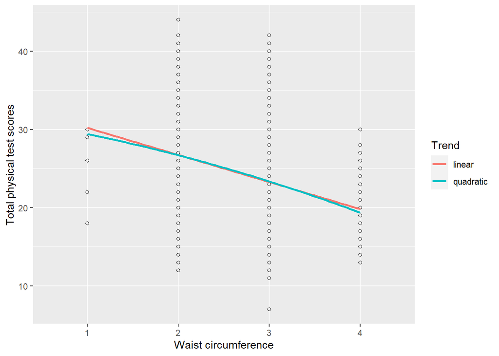

```r
ggplot(mydata) +
  aes(x = waist_circumference.ord, y = TPTS) +
  geom_point(shape = 1) +
  geom_smooth(aes(x = unclass(waist_circumference.ord), color = "1"),
              formula = y ~ x,
              method = lm, se = FALSE) +
  geom_smooth(aes(x = unclass(waist_circumference.ord), color = "2"),
              formula = y ~ x + poly(x, 2),
              method = lm, se = FALSE) +
  scale_color_discrete("Trend", labels = c("linear", "quadratic")) +
  labs(x = 'Waist circumference',y = 'Total physical test scores')
```

## Plot Figure 3.

Display random effects of weighted LMM.

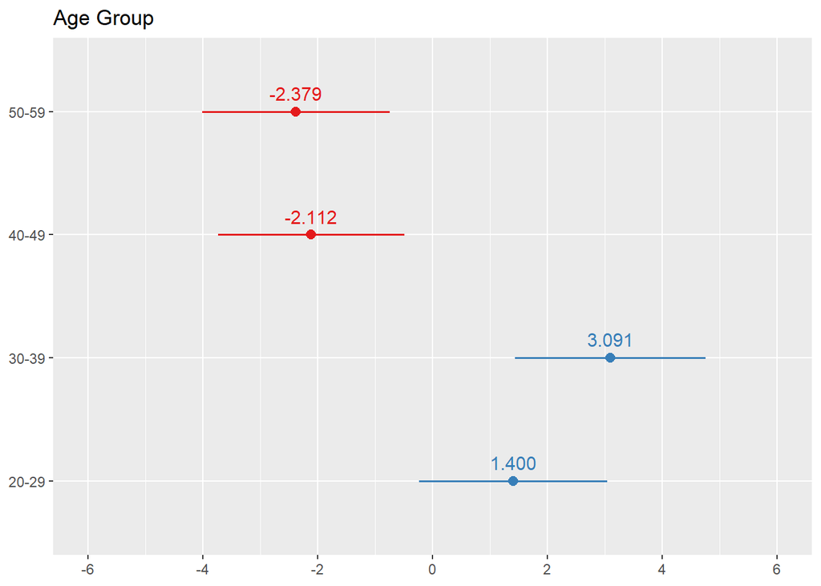

```r
namelist <- list('Age Group','Exercise Time',
                 'educational level','whether to exercise or not'
)
plot_model(mixedmodel.wt.ep, type = "re", ri.nr = 1, title = 'Age Group', show.values = TRUE, digits = 3, auto.label = TRUE)
```

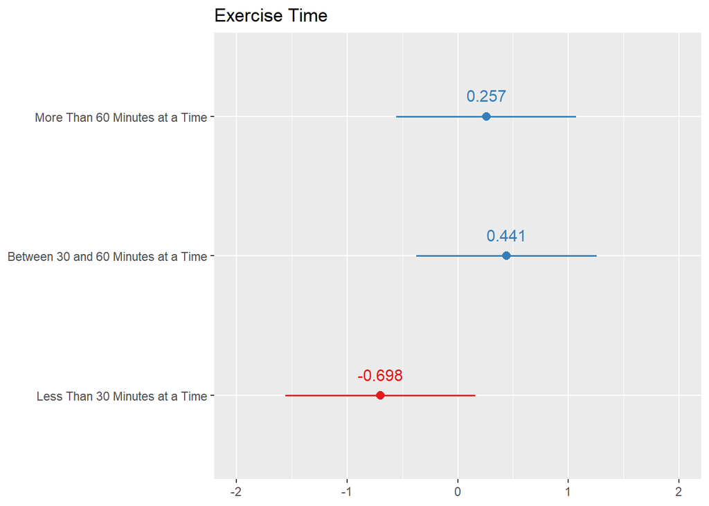

```r
plot_model(mixedmodel.wt.ep, type = "re", ri.nr = 2, title = 'Exercise Time', show.values = TRUE, digits = 3, auto.label = TRUE)
```

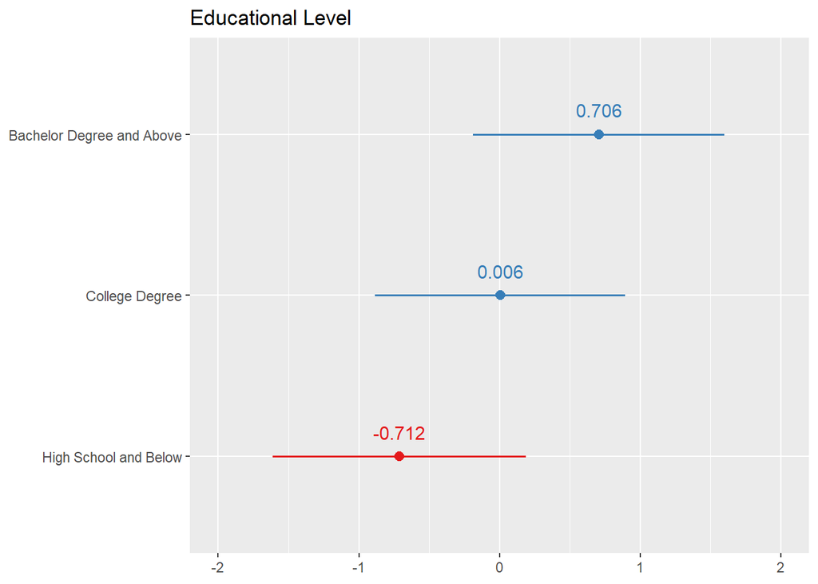

```r
plot_model(mixedmodel.wt.ep, type = "re", ri.nr = 3, title = 'Educational Level', show.values = TRUE, digits = 3, auto.label = TRUE)
```

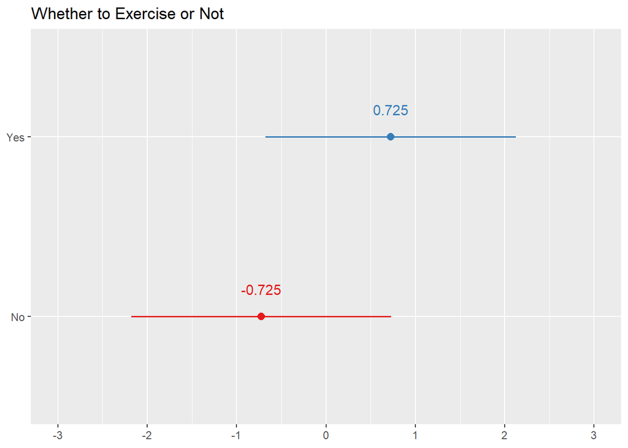

```r
plot_model(mixedmodel.wt.ep, type = "re", ri.nr = 4, title = 'Whether to Exercise or Not', show.values = TRUE, digits = 3, auto.label = TRUE)
```

## Generate Table S5

Analysis of factors associated with height by MLR

```r
reg.formula.H <- as.formula(
  height ~ gender +age + region + educational_level + type_of_occupation + minutes_of_taking_vehicles_per_week
  + minutes_of_driving_per_week + minutes_of_riding_motorcycle_per_week + minutes_of_riding_bicycle_per_week + minutes_by_foot_per_week
  + other_travel_minutes_per_week+ minutes_of_sedentary_behavior_per_week + minutes_with_standing_per_week + minutes_with_walking_per_week
  + minutes_to_manual_labor_per_week + other_working_minutes_per_week + minutes_to_watch_TV_per_week + minutes_to_play_chess_per_week
  + minutes_to_read_books_per_week + minutes_to_stroll_per_week + minutes_of_light_housework_per_week + minutes_of_heavy_housework_per_week
  + other_active_minutes_per_week + hypertension + hyperlipidemia + high_cholesterol + diabetes + coronary_heart_disease + peptic_ulcer
  + osteoarticular_diseases + cervical_spondylosis + occupational_disease + unknown + no_disease + whether_to_exercise_or_not + frequency_of_exercise
  + exercise_time + feelings_during_exercise + exercise_projects + exercise_reasons + exercise_disorders + chest_circumference + waist_circumference + hip_circumference + upper_arm_skin_fold_thickness
  + scapular_skin_fold_thickness + abdomen_skin_fold_thickness + resting_heart_rate + systolic_blood_pressure + diastolic_blood_pressure  )
H <- lm(formula = reg.formula.H, data = mydata)
performance::check_heteroscedasticity(H)
```

```
## OK: Error variance appears to be homoscedastic (p = 0.398).
```

```r
performance::check_autocorrelation(H)
wt_H <- 1 / lm(abs(H$residuals) ~ H$fitted.values)$fitted.values^2
wls.model.H <- lm(formula = reg.formula.H, data = mydata, weights=wt_H)
performance::check_normality(wls.model.H)
tab_model(wls.model.H,show.ci = 0.95,show.p = TRUE,show.re.var = TRUE,show.ngroups = FALSE,
          show.aic = FALSE,show.r2=FALSE,digits = 3,digits.re = 3)
```

|  | height |  |  |
| --- | --- | --- | --- |
| Predictors | Estimates | CI | p |
| (Intercept) | 141.221 | 134.455 – 147.987 | **<0.001** |
| gender [Male] | 9.910 | 8.951 – 10.870 | **<0.001** |
| age | -0.144 | -0.185 – -0.102 | **<0.001** |
| region [Urban Manual Workers] | -0.967 | -1.922 – -0.011 | **0.047** |
| region [Urban Non-Manual Workers] | -0.552 | -1.418 – 0.314 | 0.212 |
| educational level | 1.376 | 0.836 – 1.916 | **<0.001** |
| type of occupation [Clerical Staff] | 1.083 | 0.177 – 1.988 | **0.019** |
| type of occupation [Commercial and Service Industry Workers] | 1.627 | 0.321 – 2.933 | **0.015** |
| type of occupation [Agricultural Industry Workers] | -0.230 | -2.370 – 1.911 | 0.833 |
| type of occupation [Other Workers] | 0.948 | -0.303 – 2.199 | 0.137 |
| type of occupation [Unemployed] | 0.510 | -0.707 – 1.727 | 0.411 |
| minutes of taking vehicles per week | 0.003 | -0.023 – 0.030 | 0.809 |
| minutes of driving per week | -0.004 | -0.019 – 0.011 | 0.568 |
| minutes of riding motorcycle per week | -0.007 | -0.016 – 0.002 | 0.144 |
| minutes of riding bicycle per week | 0.003 | -0.008 – 0.014 | 0.623 |
| minutes by foot per week | 0.002 | -0.010 – 0.015 | 0.701 |
| other travel minutes per week | 0.027 | -0.232 – 0.286 | 0.840 |
| minutes of sedentary behavior per week | -0.002 | -0.005 – 0.002 | 0.350 |
| minutes with standing per week | 0.002 | -0.002 – 0.006 | 0.277 |
| minutes with walking per week | 0.004 | -0.002 – 0.010 | 0.156 |
| minutes to manual labor per week | -0.002 | -0.013 – 0.009 | 0.734 |
| other working minutes per week | -0.003 | -0.010 – 0.004 | 0.450 |
| minutes to watch TV per week | -0.003 | -0.011 – 0.004 | 0.374 |
| minutes to play chess per week | 0.014 | -0.006 – 0.034 | 0.158 |
| minutes to read books per week | 0.006 | -0.002 – 0.015 | 0.159 |
| minutes to stroll per week | -0.009 | -0.020 – 0.003 | 0.139 |
| minutes of light housework per week | -0.003 | -0.011 – 0.005 | 0.412 |
| minutes of heavy housework per week | -0.023 | -0.095 – 0.048 | 0.518 |
| other active minutes per week | 0.019 | -0.040 – 0.078 | 0.532 |
| hypertension [Yes] | 0.051 | -1.313 – 1.416 | 0.941 |
| hyperlipidemia [Yes] | -0.645 | -2.285 – 0.995 | 0.441 |
| high cholesterol [Yes] | -0.210 | -2.491 – 2.072 | 0.857 |
| diabetes [Yes] | 0.578 | -1.716 – 2.872 | 0.621 |
| coronary heart disease [Yes] | -1.037 | -3.974 – 1.900 | 0.488 |
| peptic ulcer [Yes] | 3.786 | 0.761 – 6.812 | **0.014** |
| osteoarticular diseases [Yes] | -1.187 | -2.793 – 0.419 | 0.147 |
| cervical spondylosis [Yes] | 0.478 | -0.854 – 1.809 | 0.482 |
| occupational disease [Yes] | 0.181 | -2.523 – 2.884 | 0.896 |
| unknown [Yes] | 0.210 | -0.950 – 1.370 | 0.723 |
| no disease [Yes] | -0.505 | -1.808 – 0.797 | 0.447 |
| whether to exercise or not [Yes] | 0.958 | -0.541 – 2.457 | 0.210 |
| frequency of exercise | -0.014 | -0.248 – 0.220 | 0.905 |
| exercise time | 0.388 | -0.212 – 0.988 | 0.205 |
| feelings during exercise | -0.516 | -1.065 – 0.033 | 0.065 |
| exercise projects [Jogging] | -0.724 | -1.700 – 0.253 | 0.146 |
| exercise projects [Swimming] | 0.399 | -0.742 – 1.540 | 0.493 |
| exercise projects [Walking] | 0.408 | -2.187 – 3.003 | 0.758 |
| exercise projects [Ball] | -0.737 | -2.207 – 0.732 | 0.325 |
| exercise projects [Mountaineering] | 1.965 | 0.191 – 3.738 | **0.030** |
| exercise projects [Cycling] | 1.075 | -1.620 – 3.770 | 0.434 |
| exercise projects [Other] | -0.170 | -1.252 – 0.912 | 0.758 |
| exercise reasons [Recreation] | -0.462 | -1.626 – 0.702 | 0.436 |
| exercise reasons [Increase Physical Activity] | -0.337 | -2.212 – 1.538 | 0.724 |
| exercise reasons [Reduce Stress and Regulate Mood] | 0.778 | -0.713 – 2.269 | 0.306 |
| exercise reasons [Weight Loss] | -1.138 | -2.900 – 0.623 | 0.205 |
| exercise reasons [Bodybuilders] | 0.518 | -1.091 – 2.126 | 0.528 |
| exercise reasons [Prevent Disease] | -0.137 | -1.155 – 0.881 | 0.791 |
| exercise reasons [Other] | 0.163 | -1.595 – 1.922 | 0.856 |
| exercise disorders [Not Interested] | 0.732 | -1.007 – 2.470 | 0.409 |
| exercise disorders [Laziness] | 2.947 | -0.321 – 6.215 | 0.077 |
| exercise disorders [Not Advisable or Necessary to Participate] | 2.792 | -0.002 – 5.586 | 0.050 |
| exercise disorders [Lack of Time] | -5.552 | -8.924 – -2.180 | **0.001** |
| exercise disorders [Lack of On_Site Facilities] | 2.105 | -1.070 – 5.281 | 0.194 |
| exercise disorders [Lack of Guidance] | -1.586 | -4.051 – 0.880 | 0.207 |
| exercise disorders [Lack of Organization] | -0.357 | -2.976 – 2.263 | 0.790 |
| exercise disorders [Other] | -1.700 | -5.497 – 2.098 | 0.380 |
| chest circumference | 0.108 | 0.026 – 0.190 | **0.010** |
| waist circumference | -0.019 | -0.094 – 0.055 | 0.608 |
| hip circumference | 0.144 | 0.058 – 0.230 | **0.001** |
| upper arm skin fold thickness | 0.021 | -0.040 – 0.081 | 0.502 |
| scapular skin fold thickness | -0.108 | -0.172 – -0.044 | **0.001** |
| abdomen skin fold thickness | -0.014 | -0.063 – 0.036 | 0.591 |
| resting heart rate | -0.012 | -0.041 – 0.018 | 0.438 |
| systolic blood pressure | 0.014 | -0.016 – 0.044 | 0.361 |
| diastolic blood pressure | -0.000 | -0.044 – 0.044 | 0.987 |
| Observations | 1361 |  |  |

Analysis of factors associated with weight by MLR

```r
reg.formula.W <- as.formula(
  weight ~ gender +age + region + educational_level + type_of_occupation + minutes_of_taking_vehicles_per_week
  + minutes_of_driving_per_week + minutes_of_riding_motorcycle_per_week + minutes_of_riding_bicycle_per_week + minutes_by_foot_per_week
  + other_travel_minutes_per_week+ minutes_of_sedentary_behavior_per_week + minutes_with_standing_per_week + minutes_with_walking_per_week
  + minutes_to_manual_labor_per_week + other_working_minutes_per_week + minutes_to_watch_TV_per_week + minutes_to_play_chess_per_week
  + minutes_to_read_books_per_week + minutes_to_stroll_per_week + minutes_of_light_housework_per_week + minutes_of_heavy_housework_per_week
  + other_active_minutes_per_week + hypertension + hyperlipidemia + high_cholesterol + diabetes + coronary_heart_disease + peptic_ulcer
  + osteoarticular_diseases + cervical_spondylosis + occupational_disease + unknown + no_disease + whether_to_exercise_or_not + frequency_of_exercise
  + exercise_time + feelings_during_exercise + exercise_projects + exercise_reasons + exercise_disorders + chest_circumference + waist_circumference + hip_circumference + upper_arm_skin_fold_thickness
  + scapular_skin_fold_thickness + abdomen_skin_fold_thickness + resting_heart_rate + systolic_blood_pressure + diastolic_blood_pressure  )
W <- lm(formula = reg.formula.W, data = mydata)
performance::check_heteroscedasticity(W)
performance::check_autocorrelation(W)
```

```
## OK: Residuals appear to be independent and not autocorrelated (p = 0.164).
```

```r
wt_W <- 1 / lm(abs(W$residuals) ~ W$fitted.values)$fitted.values^2
wls.model.W <- lm(formula = reg.formula.W, data = mydata, weights=wt_W)
performance::check_normality(wls.model.W)
tab_model(wls.model.W,show.ci = 0.95,show.p = TRUE,show.re.var = TRUE,show.ngroups = FALSE,
          show.aic = FALSE,show.r2=FALSE,digits = 3,digits.re = 3)
```

|  | weight |  |  |
| --- | --- | --- | --- |
| Predictors | Estimates | CI | p |
| (Intercept) | -41.241 | -48.902 – -33.579 | **<0.001** |
| gender [Male] | 7.810 | 6.705 – 8.915 | **<0.001** |
| age | -0.097 | -0.145 – -0.049 | **<0.001** |
| region [Urban Manual Workers] | -0.116 | -1.225 – 0.992 | 0.837 |
| region [Urban Non-Manual Workers] | 0.639 | -0.359 – 1.638 | 0.209 |
| educational level | 0.889 | 0.264 – 1.514 | **0.005** |
| type of occupation [Clerical Staff] | 0.432 | -0.606 – 1.470 | 0.415 |
| type of occupation [Commercial and Service Industry Workers] | 0.235 | -1.277 – 1.746 | 0.761 |
| type of occupation [Agricultural Industry Workers] | -2.676 | -5.150 – -0.201 | **0.034** |
| type of occupation [Other Workers] | 0.662 | -0.783 – 2.107 | 0.369 |
| type of occupation [Unemployed] | 0.805 | -0.611 – 2.220 | 0.265 |
| minutes of taking vehicles per week | 0.014 | -0.017 – 0.045 | 0.370 |
| minutes of driving per week | 0.008 | -0.011 – 0.026 | 0.414 |
| minutes of riding motorcycle per week | 0.010 | -0.001 – 0.020 | 0.070 |
| minutes of riding bicycle per week | -0.003 | -0.015 – 0.010 | 0.702 |
| minutes by foot per week | -0.005 | -0.020 – 0.009 | 0.473 |
| other travel minutes per week | -0.023 | -0.331 – 0.285 | 0.883 |
| minutes of sedentary behavior per week | 0.001 | -0.004 – 0.005 | 0.763 |
| minutes with standing per week | -0.001 | -0.005 – 0.003 | 0.655 |
| minutes with walking per week | 0.004 | -0.002 – 0.011 | 0.207 |
| minutes to manual labor per week | 0.006 | -0.007 – 0.020 | 0.356 |
| other working minutes per week | -0.001 | -0.009 – 0.008 | 0.866 |
| minutes to watch TV per week | 0.008 | -0.000 – 0.017 | 0.065 |
| minutes to play chess per week | 0.045 | 0.022 – 0.069 | **<0.001** |
| minutes to read books per week | 0.007 | -0.003 – 0.017 | 0.156 |
| minutes to stroll per week | 0.011 | -0.002 – 0.024 | 0.090 |
| minutes of light housework per week | -0.010 | -0.019 – -0.001 | **0.027** |
| minutes of heavy housework per week | -0.022 | -0.107 – 0.063 | 0.609 |
| other active minutes per week | 0.001 | -0.068 – 0.069 | 0.987 |
| hypertension [Yes] | -0.346 | -1.952 – 1.260 | 0.673 |
| hyperlipidemia [Yes] | 0.078 | -1.884 – 2.041 | 0.938 |
| high cholesterol [Yes] | -1.195 | -3.912 – 1.521 | 0.388 |
| diabetes [Yes] | -0.981 | -3.731 – 1.768 | 0.484 |
| coronary heart disease [Yes] | -0.003 | -3.394 – 3.389 | 0.999 |
| peptic ulcer [Yes] | 1.357 | -2.090 – 4.804 | 0.440 |
| osteoarticular diseases [Yes] | -0.250 | -2.114 – 1.614 | 0.792 |
| cervical spondylosis [Yes] | 0.294 | -1.246 – 1.835 | 0.708 |
| occupational disease [Yes] | -0.412 | -3.451 – 2.627 | 0.790 |
| unknown [Yes] | 0.474 | -0.879 – 1.826 | 0.492 |
| no disease [Yes] | -0.336 | -1.849 – 1.177 | 0.663 |
| whether to exercise or not [Yes] | 1.949 | 0.285 – 3.612 | **0.022** |
| frequency of exercise | 0.024 | -0.242 – 0.291 | 0.857 |
| exercise time | 0.549 | -0.143 – 1.240 | 0.120 |
| feelings during exercise | -0.563 | -1.197 – 0.072 | 0.082 |
| exercise projects [Jogging] | -1.131 | -2.255 – -0.007 | **0.049** |
| exercise projects [Swimming] | -0.149 | -1.481 – 1.183 | 0.826 |
| exercise projects [Walking] | -0.166 | -3.228 – 2.896 | 0.915 |
| exercise projects [Ball] | 0.061 | -1.628 – 1.749 | 0.944 |
| exercise projects [Mountaineering] | -0.336 | -2.361 – 1.690 | 0.745 |
| exercise projects [Cycling] | -0.341 | -3.550 – 2.868 | 0.835 |
| exercise projects [Other] | -0.508 | -1.754 – 0.739 | 0.424 |
| exercise reasons [Recreation] | 0.795 | -0.558 – 2.148 | 0.249 |
| exercise reasons [Increase Physical Activity] | 0.561 | -1.648 – 2.769 | 0.619 |
| exercise reasons [Reduce Stress and Regulate Mood] | 1.181 | -0.546 – 2.909 | 0.180 |
| exercise reasons [Weight Loss] | 1.218 | -0.847 – 3.283 | 0.247 |
| exercise reasons [Bodybuilders] | 0.245 | -1.562 – 2.052 | 0.790 |
| exercise reasons [Prevent Disease] | -0.033 | -1.207 – 1.141 | 0.956 |
| exercise reasons [Other] | -0.678 | -2.711 – 1.355 | 0.513 |
| exercise disorders [Not Interested] | 1.538 | -0.460 – 3.535 | 0.131 |
| exercise disorders [Laziness] | -1.834 | -5.516 – 1.847 | 0.329 |
| exercise disorders [Not Advisable or Necessary to Participate] | 0.556 | -2.622 – 3.733 | 0.731 |
| exercise disorders [Lack of Time] | 0.820 | -3.234 – 4.874 | 0.692 |
| exercise disorders [Lack of On_Site Facilities] | -0.140 | -3.773 – 3.493 | 0.940 |
| exercise disorders [Lack of Guidance] | -3.753 | -6.518 – -0.988 | **0.008** |
| exercise disorders [Lack of Organization] | -0.922 | -3.923 – 2.079 | 0.547 |
| exercise disorders [Other] | -0.705 | -5.318 – 3.908 | 0.764 |
| chest circumference | 0.337 | 0.242 – 0.431 | **<0.001** |
| waist circumference | 0.300 | 0.215 – 0.386 | **<0.001** |
| hip circumference | 0.399 | 0.301 – 0.497 | **<0.001** |
| upper arm skin fold thickness | 0.067 | -0.004 – 0.139 | 0.065 |
| scapular skin fold thickness | 0.110 | 0.034 – 0.185 | **0.005** |
| abdomen skin fold thickness | 0.037 | -0.020 – 0.094 | 0.207 |
| resting heart rate | -0.011 | -0.045 – 0.023 | 0.519 |
| systolic blood pressure | 0.035 | 0.000 – 0.070 | **0.049** |
| diastolic blood pressure | 0.011 | -0.039 – 0.061 | 0.663 |
| Observations | 1361 |  |  |

Analysis of factors associated with vital capacity by MLR

```r
reg.formula.VC <- as.formula(
  vital_capacity ~ gender +age + region + educational_level + type_of_occupation + minutes_of_taking_vehicles_per_week
  + minutes_of_driving_per_week + minutes_of_riding_motorcycle_per_week + minutes_of_riding_bicycle_per_week + minutes_by_foot_per_week
  + other_travel_minutes_per_week+ minutes_of_sedentary_behavior_per_week + minutes_with_standing_per_week + minutes_with_walking_per_week
  + minutes_to_manual_labor_per_week + other_working_minutes_per_week + minutes_to_watch_TV_per_week + minutes_to_play_chess_per_week
  + minutes_to_read_books_per_week + minutes_to_stroll_per_week + minutes_of_light_housework_per_week + minutes_of_heavy_housework_per_week
  + other_active_minutes_per_week + hypertension + hyperlipidemia + high_cholesterol + diabetes + coronary_heart_disease + peptic_ulcer
  + osteoarticular_diseases + cervical_spondylosis + occupational_disease + unknown + no_disease + whether_to_exercise_or_not + frequency_of_exercise
  + exercise_time + feelings_during_exercise + exercise_projects + exercise_reasons + exercise_disorders + chest_circumference + waist_circumference + hip_circumference + upper_arm_skin_fold_thickness
  + scapular_skin_fold_thickness + abdomen_skin_fold_thickness + resting_heart_rate + systolic_blood_pressure + diastolic_blood_pressure  )
VC <- lm(formula = reg.formula.VC, data = mydata)
performance::check_heteroscedasticity(VC)
performance::check_autocorrelation(VC)
```

```
## OK: Residuals appear to be independent and not autocorrelated (p = 0.480).
```

```r
wt_VC <- 1 / lm(abs(VC$residuals) ~ VC$fitted.values)$fitted.values^2
wls.model.VC <- lm(formula = reg.formula.VC, data = mydata, weights=wt_VC)
performance::check_normality(wls.model.VC)
tab_model(wls.model.VC,show.ci = 0.95,show.p = TRUE,show.re.var = TRUE,show.ngroups = FALSE,
          show.aic = FALSE,show.r2=FALSE,digits = 3,digits.re = 3)
```

|  | vital_capacity |  |  |
| --- | --- | --- | --- |
| Predictors | Estimates | CI | p |
| (Intercept) | 1700.419 | 926.212 – 2474.626 | **<0.001** |
| gender [Male] | 1155.052 | 1044.818 – 1265.286 | **<0.001** |
| age | -22.279 | -27.081 – -17.476 | **<0.001** |
| region [Urban Manual Workers] | -57.723 | -167.146 – 51.700 | 0.301 |
| region [Urban Non-Manual Workers] | 31.827 | -67.606 – 131.260 | 0.530 |
| educational level | 88.463 | 26.260 – 150.666 | **0.005** |
| type of occupation [Clerical Staff] | 31.175 | -73.640 – 135.990 | 0.560 |
| type of occupation [Commercial and Service Industry Workers] | 125.893 | -25.605 – 277.391 | 0.103 |
| type of occupation [Agricultural Industry Workers] | -154.463 | -387.467 – 78.541 | 0.194 |
| type of occupation [Other Workers] | -17.961 | -160.170 – 124.247 | 0.804 |
| type of occupation [Unemployed] | 75.698 | -62.649 – 214.044 | 0.283 |
| minutes of taking vehicles per week | 0.304 | -2.826 – 3.433 | 0.849 |
| minutes of driving per week | 0.138 | -1.715 – 1.991 | 0.884 |
| minutes of riding motorcycle per week | -0.457 | -1.489 – 0.575 | 0.385 |
| minutes of riding bicycle per week | 0.661 | -0.629 – 1.951 | 0.315 |
| minutes by foot per week | 0.393 | -1.025 – 1.812 | 0.587 |
| other travel minutes per week | 25.946 | -9.092 – 60.984 | 0.147 |
| minutes of sedentary behavior per week | 0.030 | -0.394 – 0.455 | 0.888 |
| minutes with standing per week | 0.145 | -0.300 – 0.589 | 0.523 |
| minutes with walking per week | -0.498 | -1.128 – 0.132 | 0.121 |
| minutes to manual labor per week | -1.081 | -2.278 – 0.116 | 0.077 |
| other working minutes per week | 0.391 | -0.478 – 1.261 | 0.377 |
| minutes to watch TV per week | 0.018 | -0.812 – 0.848 | 0.966 |
| minutes to play chess per week | 0.741 | -1.433 – 2.916 | 0.504 |
| minutes to read books per week | 1.143 | 0.126 – 2.160 | **0.028** |
| minutes to stroll per week | -0.498 | -1.761 – 0.765 | 0.440 |
| minutes of light housework per week | 0.563 | -0.323 – 1.448 | 0.213 |
| minutes of heavy housework per week | 1.708 | -6.318 – 9.734 | 0.676 |
| other active minutes per week | 0.375 | -6.599 – 7.349 | 0.916 |
| hypertension [Yes] | -173.648 | -326.924 – -20.372 | **0.026** |
| hyperlipidemia [Yes] | -102.978 | -285.844 – 79.887 | 0.269 |
| high cholesterol [Yes] | 136.924 | -118.441 – 392.290 | 0.293 |
| diabetes [Yes] | -66.096 | -320.142 – 187.950 | 0.610 |
| coronary heart disease [Yes] | 15.104 | -311.279 – 341.487 | 0.928 |
| peptic ulcer [Yes] | -37.568 | -382.602 – 307.466 | 0.831 |
| osteoarticular diseases [Yes] | -1.263 | -180.801 – 178.275 | 0.989 |
| cervical spondylosis [Yes] | 121.868 | -28.322 – 272.059 | 0.112 |
| occupational disease [Yes] | 120.443 | -194.757 – 435.643 | 0.454 |
| unknown [Yes] | 6.683 | -124.821 – 138.188 | 0.921 |
| no disease [Yes] | -47.074 | -194.910 – 100.762 | 0.532 |
| whether to exercise or not [Yes] | 237.110 | 68.178 – 406.041 | **0.006** |
| frequency of exercise | -4.032 | -31.103 – 23.038 | 0.770 |
| exercise time | 51.952 | -17.243 – 121.147 | 0.141 |
| feelings during exercise | -27.999 | -90.965 – 34.968 | 0.383 |
| exercise projects [Jogging] | -22.052 | -132.526 – 88.422 | 0.695 |
| exercise projects [Swimming] | 53.362 | -80.094 – 186.817 | 0.433 |
| exercise projects [Walking] | -109.084 | -415.715 – 197.548 | 0.485 |
| exercise projects [Ball] | -87.191 | -256.290 – 81.908 | 0.312 |
| exercise projects [Mountaineering] | 235.139 | 22.002 – 448.276 | **0.031** |
| exercise projects [Cycling] | 80.236 | -247.978 – 408.451 | 0.632 |
| exercise projects [Other] | 83.422 | -40.522 – 207.365 | 0.187 |
| exercise reasons [Recreation] | 51.790 | -82.918 – 186.498 | 0.451 |
| exercise reasons [Increase Physical Activity] | -24.528 | -240.303 – 191.246 | 0.824 |
| exercise reasons [Reduce Stress and Regulate Mood] | 314.171 | 136.631 – 491.710 | **0.001** |
| exercise reasons [Weight Loss] | 135.942 | -69.357 – 341.241 | 0.194 |
| exercise reasons [Bodybuilders] | 48.134 | -139.528 – 235.796 | 0.615 |
| exercise reasons [Prevent Disease] | 44.161 | -71.715 – 160.037 | 0.455 |
| exercise reasons [Other] | 125.710 | -85.341 – 336.761 | 0.243 |
| exercise disorders [Not Interested] | -71.839 | -277.117 – 133.438 | 0.492 |
| exercise disorders [Laziness] | 314.510 | -89.733 – 718.753 | 0.127 |
| exercise disorders [Not Advisable or Necessary to Participate] | -329.101 | -640.925 – -17.277 | **0.039** |
| exercise disorders [Lack of Time] | -93.077 | -487.605 – 301.451 | 0.644 |
| exercise disorders [Lack of On_Site Facilities] | -104.568 | -472.085 – 262.949 | 0.577 |
| exercise disorders [Lack of Guidance] | -136.610 | -427.617 – 154.398 | 0.357 |
| exercise disorders [Lack of Organization] | -188.871 | -490.506 – 112.763 | 0.220 |
| exercise disorders [Other] | 91.029 | -347.309 – 529.367 | 0.684 |
| chest circumference | 18.595 | 9.113 – 28.078 | **<0.001** |
| waist circumference | -10.032 | -18.448 – -1.615 | **0.020** |
| hip circumference | 1.827 | -7.942 – 11.595 | 0.714 |
| upper arm skin fold thickness | -4.802 | -11.711 – 2.108 | 0.173 |
| scapular skin fold thickness | -9.073 | -16.303 – -1.843 | **0.014** |
| abdomen skin fold thickness | -3.301 | -8.886 – 2.283 | 0.246 |
| resting heart rate | 0.080 | -3.347 – 3.508 | 0.963 |
| systolic blood pressure | 2.749 | -0.724 – 6.222 | 0.121 |
| diastolic blood pressure | -1.642 | -6.701 – 3.416 | 0.524 |
| Observations | 1361 |  |  |

Analysis of factors associated with sit and reach by MLR

```r
reg.formula.SAR <- as.formula(
  sit_and_reach ~ gender +age + region + educational_level + type_of_occupation + minutes_of_taking_vehicles_per_week
  + minutes_of_driving_per_week + minutes_of_riding_motorcycle_per_week + minutes_of_riding_bicycle_per_week + minutes_by_foot_per_week
  + other_travel_minutes_per_week+ minutes_of_sedentary_behavior_per_week + minutes_with_standing_per_week + minutes_with_walking_per_week
  + minutes_to_manual_labor_per_week + other_working_minutes_per_week + minutes_to_watch_TV_per_week + minutes_to_play_chess_per_week
  + minutes_to_read_books_per_week + minutes_to_stroll_per_week + minutes_of_light_housework_per_week + minutes_of_heavy_housework_per_week
  + other_active_minutes_per_week + hypertension + hyperlipidemia + high_cholesterol + diabetes + coronary_heart_disease + peptic_ulcer
  + osteoarticular_diseases + cervical_spondylosis + occupational_disease + unknown + no_disease + whether_to_exercise_or_not + frequency_of_exercise
  + exercise_time + feelings_during_exercise + exercise_projects + exercise_reasons + exercise_disorders + chest_circumference + waist_circumference + hip_circumference + upper_arm_skin_fold_thickness
  + scapular_skin_fold_thickness + abdomen_skin_fold_thickness + resting_heart_rate + systolic_blood_pressure + diastolic_blood_pressure  )
SAR <- lm(formula = reg.formula.SAR, data = mydata)
performance::check_heteroscedasticity(SAR)
```

```
## OK: Error variance appears to be homoscedastic (p = 0.287).
```

```r
performance::check_autocorrelation(SAR)
```

```
## OK: Residuals appear to be independent and not autocorrelated (p = 0.396).
```

```r
performance::check_normality(SAR)
tab_model(SAR,show.ci = 0.95,show.p = TRUE,show.re.var = TRUE,show.ngroups = FALSE,
          show.aic = FALSE,show.r2=FALSE,digits = 3,digits.re = 3)
```

|  | sit_and_reach |  |  |
| --- | --- | --- | --- |
| Predictors | Estimates | CI | p |
| (Intercept) | 2.123 | -7.812 – 12.059 | 0.675 |
| gender [Male] | -2.114 | -3.522 – -0.706 | **0.003** |
| age | 0.017 | -0.044 – 0.077 | 0.590 |
| region [Urban Manual Workers] | 0.811 | -0.585 – 2.207 | 0.255 |
| region [Urban Non-Manual Workers] | 1.684 | 0.416 – 2.951 | **0.009** |
| educational level | 0.184 | -0.607 – 0.975 | 0.648 |
| type of occupation [Clerical Staff] | 0.978 | -0.343 – 2.300 | 0.147 |
| type of occupation [Commercial and Service Industry Workers] | 0.934 | -0.972 – 2.841 | 0.336 |
| type of occupation [Agricultural Industry Workers] | -0.126 | -3.304 – 3.051 | 0.938 |
| type of occupation [Other Workers] | 0.504 | -1.328 – 2.336 | 0.589 |
| type of occupation [Unemployed] | 0.772 | -1.021 – 2.565 | 0.398 |
| minutes of taking vehicles per week | 0.005 | -0.033 – 0.043 | 0.804 |
| minutes of driving per week | 0.004 | -0.017 – 0.026 | 0.709 |
| minutes of riding motorcycle per week | -0.014 | -0.028 – -0.001 | **0.032** |
| minutes of riding bicycle per week | -0.001 | -0.017 – 0.016 | 0.938 |
| minutes by foot per week | 0.020 | 0.003 – 0.038 | **0.025** |
| other travel minutes per week | -0.046 | -0.411 – 0.318 | 0.803 |
| minutes of sedentary behavior per week | -0.005 | -0.010 – 0.001 | 0.096 |
| minutes with standing per week | -0.002 | -0.008 – 0.004 | 0.489 |
| minutes with walking per week | 0.004 | -0.005 – 0.012 | 0.390 |
| minutes to manual labor per week | 0.007 | -0.009 – 0.023 | 0.391 |
| other working minutes per week | 0.006 | -0.004 – 0.016 | 0.258 |
| minutes to watch TV per week | -0.007 | -0.017 – 0.004 | 0.226 |
| minutes to play chess per week | 0.019 | -0.009 – 0.048 | 0.183 |
| minutes to read books per week | 0.010 | -0.002 – 0.023 | 0.098 |
| minutes to stroll per week | 0.017 | -0.000 – 0.033 | 0.051 |
| minutes of light housework per week | 0.009 | -0.003 – 0.021 | 0.131 |
| minutes of heavy housework per week | 0.063 | -0.043 – 0.170 | 0.241 |
| other active minutes per week | -0.010 | -0.095 – 0.075 | 0.817 |
| hypertension [Yes] | -0.688 | -2.691 – 1.315 | 0.500 |
| hyperlipidemia [Yes] | 0.284 | -2.130 – 2.697 | 0.818 |
| high cholesterol [Yes] | -2.949 | -6.315 – 0.418 | 0.086 |
| diabetes [Yes] | -1.645 | -5.013 – 1.724 | 0.338 |
| coronary heart disease [Yes] | -5.734 | -10.087 – -1.382 | **0.010** |
| peptic ulcer [Yes] | 1.025 | -3.331 – 5.382 | 0.644 |
| osteoarticular diseases [Yes] | -0.334 | -2.724 – 2.057 | 0.784 |
| cervical spondylosis [Yes] | 0.652 | -1.315 – 2.619 | 0.516 |
| occupational disease [Yes] | -1.591 | -5.544 – 2.362 | 0.430 |
| unknown [Yes] | 0.659 | -1.043 – 2.361 | 0.448 |
| no disease [Yes] | -0.016 | -1.926 – 1.894 | 0.987 |
| whether to exercise or not [Yes] | 2.980 | 0.784 – 5.176 | **0.008** |
| frequency of exercise | 0.334 | -0.008 – 0.676 | 0.056 |
| exercise time | 0.267 | -0.609 – 1.144 | 0.550 |
| feelings during exercise | 0.244 | -0.560 – 1.048 | 0.551 |
| exercise projects [Jogging] | 0.293 | -1.148 – 1.734 | 0.690 |
| exercise projects [Swimming] | 2.341 | 0.686 – 3.996 | **0.006** |
| exercise projects [Walking] | 1.935 | -1.786 – 5.656 | 0.308 |
| exercise projects [Ball] | 0.457 | -1.696 – 2.610 | 0.677 |
| exercise projects [Mountaineering] | 3.542 | 0.988 – 6.095 | **0.007** |
| exercise projects [Cycling] | -0.364 | -4.207 – 3.480 | 0.853 |
| exercise projects [Other] | 3.265 | 1.675 – 4.855 | **<0.001** |
| exercise reasons [Recreation] | 1.122 | -0.584 – 2.828 | 0.197 |
| exercise reasons [Increase Physical Activity] | 0.211 | -2.524 – 2.946 | 0.880 |
| exercise reasons [Reduce Stress and Regulate Mood] | 1.114 | -1.049 – 3.278 | 0.312 |
| exercise reasons [Weight Loss] | 0.011 | -2.572 – 2.594 | 0.993 |
| exercise reasons [Bodybuilders] | 0.827 | -1.522 – 3.176 | 0.490 |
| exercise reasons [Prevent Disease] | 0.997 | -0.499 – 2.493 | 0.191 |
| exercise reasons [Other] | -0.001 | -2.536 – 2.534 | 0.999 |
| exercise disorders [Not Interested] | 0.932 | -1.582 – 3.446 | 0.467 |
| exercise disorders [Laziness] | -1.270 | -5.918 – 3.379 | 0.592 |
| exercise disorders [Not Advisable or Necessary to Participate] | -2.098 | -6.142 – 1.946 | 0.309 |
| exercise disorders [Lack of Time] | 2.195 | -2.833 – 7.222 | 0.392 |
| exercise disorders [Lack of On_Site Facilities] | -0.333 | -4.921 – 4.256 | 0.887 |
| exercise disorders [Lack of Guidance] | -2.856 | -6.437 – 0.725 | 0.118 |
| exercise disorders [Lack of Organization] | -4.004 | -7.820 – -0.187 | **0.040** |
| exercise disorders [Other] | 2.487 | -3.091 – 8.066 | 0.382 |
| chest circumference | 0.262 | 0.143 – 0.382 | **<0.001** |
| waist circumference | -0.285 | -0.394 – -0.176 | **<0.001** |
| hip circumference | -0.022 | -0.149 – 0.105 | 0.735 |
| upper arm skin fold thickness | -0.018 | -0.107 – 0.070 | 0.685 |
| scapular skin fold thickness | 0.024 | -0.070 – 0.118 | 0.617 |
| abdomen skin fold thickness | -0.102 | -0.174 – -0.030 | **0.006** |
| resting heart rate | -0.018 | -0.061 – 0.025 | 0.419 |
| systolic blood pressure | 0.022 | -0.022 – 0.067 | 0.323 |
| diastolic blood pressure | 0.013 | -0.051 – 0.078 | 0.681 |
| Observations | 1361 |  |  |

Analysis of factors associated with grip strengt by MLR

```r
reg.formula.GS <- as.formula(
  grip_strength ~ gender +age + region + educational_level + type_of_occupation + minutes_of_taking_vehicles_per_week
  + minutes_of_driving_per_week + minutes_of_riding_motorcycle_per_week + minutes_of_riding_bicycle_per_week + minutes_by_foot_per_week
  + other_travel_minutes_per_week+ minutes_of_sedentary_behavior_per_week + minutes_with_standing_per_week + minutes_with_walking_per_week
  + minutes_to_manual_labor_per_week + other_working_minutes_per_week + minutes_to_watch_TV_per_week + minutes_to_play_chess_per_week
  + minutes_to_read_books_per_week + minutes_to_stroll_per_week + minutes_of_light_housework_per_week + minutes_of_heavy_housework_per_week
  + other_active_minutes_per_week + hypertension + hyperlipidemia + high_cholesterol + diabetes + coronary_heart_disease + peptic_ulcer
  + osteoarticular_diseases + cervical_spondylosis + occupational_disease + unknown + no_disease + whether_to_exercise_or_not + frequency_of_exercise
  + exercise_time + feelings_during_exercise + exercise_projects + exercise_reasons + exercise_disorders + chest_circumference + waist_circumference + hip_circumference + upper_arm_skin_fold_thickness
  + scapular_skin_fold_thickness + abdomen_skin_fold_thickness + resting_heart_rate + systolic_blood_pressure + diastolic_blood_pressure  )
GS <- lm(formula = reg.formula.GS, data = mydata)
performance::check_heteroscedasticity(GS)
performance::check_autocorrelation(GS)
```

```
## OK: Residuals appear to be independent and not autocorrelated (p = 0.406).
```

```r
wt_GS <- 1 / lm(abs(GS$residuals) ~ GS$fitted.values)$fitted.values^2
wls.model.GS <- lm(formula = reg.formula.GS, data = mydata, weights=wt_GS)
performance::check_normality(wls.model.GS)
tab_model(wls.model.GS,show.ci = 0.95,show.p = TRUE,show.re.var = TRUE,show.ngroups = FALSE,
          show.aic = FALSE,show.r2=FALSE,digits = 3,digits.re = 3)
```

|  | grip_strength |  |  |
| --- | --- | --- | --- |
| Predictors | Estimates | CI | p |
| (Intercept) | 12.745 | 4.693 – 20.796 | **0.002** |
| gender [Male] | 17.071 | 15.919 – 18.224 | **<0.001** |
| age | -0.130 | -0.179 – -0.080 | **<0.001** |
| region [Urban Manual Workers] | -0.358 | -1.503 – 0.787 | 0.540 |
| region [Urban Non-Manual Workers] | 0.502 | -0.527 – 1.531 | 0.339 |
| educational level | 0.245 | -0.402 – 0.891 | 0.458 |
| type of occupation [Clerical Staff] | -0.120 | -1.214 – 0.974 | 0.830 |
| type of occupation [Commercial and Service Industry Workers] | -0.501 | -2.071 – 1.068 | 0.531 |
| type of occupation [Agricultural Industry Workers] | -4.081 | -6.518 – -1.643 | **0.001** |
| type of occupation [Other Workers] | -1.837 | -3.333 – -0.341 | **0.016** |
| type of occupation [Unemployed] | -2.410 | -3.834 – -0.987 | **0.001** |
| minutes of taking vehicles per week | -0.008 | -0.040 – 0.024 | 0.624 |
| minutes of driving per week | 0.006 | -0.014 – 0.025 | 0.583 |
| minutes of riding motorcycle per week | -0.007 | -0.018 – 0.004 | 0.189 |
| minutes of riding bicycle per week | -0.003 | -0.016 – 0.010 | 0.665 |
| minutes by foot per week | 0.004 | -0.011 – 0.019 | 0.615 |
| other travel minutes per week | 0.204 | -0.152 – 0.559 | 0.262 |
| minutes of sedentary behavior per week | -0.002 | -0.007 – 0.002 | 0.343 |
| minutes with standing per week | 0.005 | 0.000 – 0.009 | **0.046** |
| minutes with walking per week | 0.007 | -0.000 – 0.013 | 0.058 |
| minutes to manual labor per week | -0.001 | -0.014 – 0.012 | 0.902 |
| other working minutes per week | 0.006 | -0.003 – 0.015 | 0.179 |
| minutes to watch TV per week | 0.001 | -0.007 – 0.010 | 0.741 |
| minutes to play chess per week | 0.005 | -0.018 – 0.028 | 0.652 |
| minutes to read books per week | 0.010 | -0.001 – 0.020 | 0.063 |
| minutes to stroll per week | 0.007 | -0.007 – 0.020 | 0.328 |
| minutes of light housework per week | -0.005 | -0.014 – 0.004 | 0.304 |
| minutes of heavy housework per week | -0.038 | -0.121 – 0.044 | 0.360 |
| other active minutes per week | 0.002 | -0.072 – 0.075 | 0.964 |
| hypertension [Yes] | -1.482 | -3.105 – 0.142 | 0.074 |
| hyperlipidemia [Yes] | -0.436 | -2.384 – 1.512 | 0.661 |
| high cholesterol [Yes] | -1.420 | -4.081 – 1.240 | 0.295 |
| diabetes [Yes] | -4.164 | -6.814 – -1.515 | **0.002** |
| coronary heart disease [Yes] | -0.135 | -3.564 – 3.294 | 0.938 |
| peptic ulcer [Yes] | 1.157 | -2.507 – 4.821 | 0.536 |
| osteoarticular diseases [Yes] | -1.225 | -3.090 – 0.640 | 0.198 |
| cervical spondylosis [Yes] | 1.264 | -0.303 – 2.831 | 0.114 |
| occupational disease [Yes] | 0.447 | -2.763 – 3.657 | 0.785 |
| unknown [Yes] | -0.180 | -1.559 – 1.199 | 0.798 |
| no disease [Yes] | -0.713 | -2.270 – 0.845 | 0.369 |
| whether to exercise or not [Yes] | 0.433 | -1.354 – 2.221 | 0.634 |
| frequency of exercise | 0.115 | -0.165 – 0.395 | 0.420 |
| exercise time | -0.026 | -0.746 – 0.695 | 0.944 |
| feelings during exercise | -0.512 | -1.167 – 0.142 | 0.125 |
| exercise projects [Jogging] | -0.688 | -1.835 – 0.460 | 0.240 |
| exercise projects [Swimming] | -0.795 | -2.171 – 0.582 | 0.258 |
| exercise projects [Walking] | -2.488 | -5.666 – 0.690 | 0.125 |
| exercise projects [Ball] | -0.060 | -1.810 – 1.690 | 0.946 |
| exercise projects [Mountaineering] | 1.965 | -0.223 – 4.153 | 0.078 |
| exercise projects [Cycling] | -0.218 | -3.607 – 3.170 | 0.899 |
| exercise projects [Other] | 0.532 | -0.748 – 1.812 | 0.415 |
| exercise reasons [Recreation] | -0.638 | -2.016 – 0.741 | 0.364 |
| exercise reasons [Increase Physical Activity] | -0.800 | -3.030 – 1.430 | 0.482 |
| exercise reasons [Reduce Stress and Regulate Mood] | 0.254 | -1.546 – 2.054 | 0.782 |
| exercise reasons [Weight Loss] | -0.436 | -2.528 – 1.656 | 0.683 |
| exercise reasons [Bodybuilders] | 0.574 | -1.338 – 2.485 | 0.556 |
| exercise reasons [Prevent Disease] | 0.859 | -0.357 – 2.076 | 0.166 |
| exercise reasons [Other] | 1.812 | -0.396 – 4.021 | 0.108 |
| exercise disorders [Not Interested] | 0.283 | -1.855 – 2.420 | 0.795 |
| exercise disorders [Laziness] | -1.824 | -5.829 – 2.181 | 0.372 |
| exercise disorders [Not Advisable or Necessary to Participate] | -0.734 | -4.020 – 2.553 | 0.662 |
| exercise disorders [Lack of Time] | 1.687 | -2.599 – 5.972 | 0.440 |
| exercise disorders [Lack of On_Site Facilities] | -0.237 | -4.086 – 3.612 | 0.904 |
| exercise disorders [Lack of Guidance] | 0.002 | -3.055 – 3.058 | 0.999 |
| exercise disorders [Lack of Organization] | -2.423 | -5.485 – 0.639 | 0.121 |
| exercise disorders [Other] | -0.415 | -4.997 – 4.168 | 0.859 |
| chest circumference | 0.160 | 0.061 – 0.259 | **0.002** |
| waist circumference | 0.027 | -0.060 – 0.115 | 0.540 |
| hip circumference | 0.010 | -0.092 – 0.111 | 0.847 |
| upper arm skin fold thickness | 0.003 | -0.069 – 0.076 | 0.932 |
| scapular skin fold thickness | -0.114 | -0.189 – -0.039 | **0.003** |
| abdomen skin fold thickness | -0.003 | -0.061 – 0.055 | 0.909 |
| resting heart rate | -0.047 | -0.082 – -0.012 | **0.009** |
| systolic blood pressure | 0.059 | 0.023 – 0.095 | **0.001** |
| diastolic blood pressure | -0.006 | -0.059 – 0.047 | 0.825 |
| Observations | 1361 |  |  |

Analysis of factors associated with one leg standing with eye closed by MLR

```r
reg.formula.OLSWEC <- as.formula(
  one_leg_standing_with_eye_closed ~ gender +age + region + educational_level + type_of_occupation + minutes_of_taking_vehicles_per_week
  + minutes_of_driving_per_week + minutes_of_riding_motorcycle_per_week + minutes_of_riding_bicycle_per_week + minutes_by_foot_per_week
  + other_travel_minutes_per_week+ minutes_of_sedentary_behavior_per_week + minutes_with_standing_per_week + minutes_with_walking_per_week
  + minutes_to_manual_labor_per_week + other_working_minutes_per_week + minutes_to_watch_TV_per_week + minutes_to_play_chess_per_week
  + minutes_to_read_books_per_week + minutes_to_stroll_per_week + minutes_of_light_housework_per_week + minutes_of_heavy_housework_per_week
  + other_active_minutes_per_week + hypertension + hyperlipidemia + high_cholesterol + diabetes + coronary_heart_disease + peptic_ulcer
  + osteoarticular_diseases + cervical_spondylosis + occupational_disease + unknown + no_disease + whether_to_exercise_or_not + frequency_of_exercise
  + exercise_time + feelings_during_exercise + exercise_projects + exercise_reasons + exercise_disorders + chest_circumference + waist_circumference + hip_circumference + upper_arm_skin_fold_thickness
  + scapular_skin_fold_thickness + abdomen_skin_fold_thickness + resting_heart_rate + systolic_blood_pressure + diastolic_blood_pressure  )
OLSWEC <- lm(formula = reg.formula.OLSWEC, data = mydata)
performance::check_heteroscedasticity(OLSWEC)
performance::check_autocorrelation(OLSWEC)
```

```
## OK: Residuals appear to be independent and not autocorrelated (p = 0.822).
```

```r
wt_OLSWEC <- 1 / lm(abs(OLSWEC$residuals) ~ OLSWEC$fitted.values)$fitted.values^2
wls.model.OLSWEC <- lm(formula = reg.formula.OLSWEC, data = mydata, weights=wt_OLSWEC)
performance::check_normality(wls.model.OLSWEC)
tab_model(wls.model.OLSWEC,show.ci = 0.95,show.p = TRUE,show.re.var = TRUE,show.ngroups = FALSE,
          show.aic = FALSE,show.r2=FALSE,digits = 3,digits.re = 3)
```

|  | one_leg_standing_with_eye_closed |  |  |
| --- | --- | --- | --- |
| Predictors | Estimates | CI | p |
| (Intercept) | 46.994 | 29.761 – 64.226 | **<0.001** |
| gender [Male] | 2.349 | -0.030 – 4.728 | 0.053 |
| age | -0.368 | -0.486 – -0.250 | **<0.001** |
| region [Urban Manual Workers] | -1.009 | -3.476 – 1.457 | 0.422 |
| region [Urban Non-Manual Workers] | -2.417 | -4.639 – -0.196 | **0.033** |
| educational level | 2.161 | 0.613 – 3.708 | **0.006** |
| type of occupation [Clerical Staff] | 0.879 | -1.729 – 3.487 | 0.509 |
| type of occupation [Commercial and Service Industry Workers] | 2.244 | -1.265 – 5.754 | 0.210 |
| type of occupation [Agricultural Industry Workers] | -2.656 | -6.540 – 1.229 | 0.180 |
| type of occupation [Other Workers] | -2.242 | -5.041 – 0.557 | 0.116 |
| type of occupation [Unemployed] | -1.137 | -4.057 – 1.784 | 0.445 |
| minutes of taking vehicles per week | 0.047 | -0.056 – 0.150 | 0.370 |
| minutes of driving per week | -0.020 | -0.073 – 0.033 | 0.463 |
| minutes of riding motorcycle per week | -0.001 | -0.021 – 0.020 | 0.941 |
| minutes of riding bicycle per week | 0.020 | -0.007 – 0.047 | 0.149 |
| minutes by foot per week | 0.006 | -0.022 – 0.035 | 0.660 |
| other travel minutes per week | -0.025 | -0.865 – 0.815 | 0.954 |
| minutes of sedentary behavior per week | -0.002 | -0.013 – 0.009 | 0.754 |
| minutes with standing per week | -0.012 | -0.021 – -0.003 | **0.010** |
| minutes with walking per week | -0.003 | -0.015 – 0.009 | 0.578 |
| minutes to manual labor per week | -0.013 | -0.039 – 0.012 | 0.296 |
| other working minutes per week | 0.020 | -0.009 – 0.049 | 0.175 |
| minutes to watch TV per week | -0.003 | -0.020 – 0.014 | 0.715 |
| minutes to play chess per week | -0.018 | -0.041 – 0.005 | 0.117 |
| minutes to read books per week | 0.010 | -0.019 – 0.039 | 0.495 |
| minutes to stroll per week | 0.010 | -0.015 – 0.035 | 0.434 |
| minutes of light housework per week | 0.012 | -0.010 – 0.034 | 0.278 |
| minutes of heavy housework per week | 0.106 | -0.113 – 0.324 | 0.344 |
| other active minutes per week | -0.081 | -0.193 – 0.030 | 0.153 |
| hypertension [Yes] | 0.100 | -2.690 – 2.890 | 0.944 |
| hyperlipidemia [Yes] | 0.530 | -2.455 – 3.514 | 0.728 |
| high cholesterol [Yes] | 2.834 | -1.605 – 7.272 | 0.211 |
| diabetes [Yes] | 0.288 | -4.255 – 4.832 | 0.901 |
| coronary heart disease [Yes] | -0.175 | -4.141 – 3.791 | 0.931 |
| peptic ulcer [Yes] | -2.154 | -7.397 – 3.089 | 0.420 |
| osteoarticular diseases [Yes] | -5.038 | -8.107 – -1.969 | **0.001** |
| cervical spondylosis [Yes] | -0.094 | -3.031 – 2.842 | 0.950 |
| occupational disease [Yes] | 0.750 | -8.525 – 10.025 | 0.874 |
| unknown [Yes] | -2.147 | -4.837 – 0.543 | 0.118 |
| no disease [Yes] | 2.184 | -0.691 – 5.059 | 0.136 |
| whether to exercise or not [Yes] | 3.082 | -0.334 – 6.498 | 0.077 |
| frequency of exercise | 0.243 | -0.393 – 0.880 | 0.453 |
| exercise time | -0.741 | -2.262 – 0.779 | 0.339 |
| feelings during exercise | 0.531 | -0.856 – 1.917 | 0.453 |
| exercise projects [Jogging] | 1.135 | -1.209 – 3.480 | 0.342 |
| exercise projects [Swimming] | 3.865 | 0.392 – 7.338 | **0.029** |
| exercise projects [Walking] | 0.354 | -7.340 – 8.048 | 0.928 |
| exercise projects [Ball] | -2.336 | -5.711 – 1.039 | 0.175 |
| exercise projects [Mountaineering] | 6.269 | -0.101 – 12.639 | 0.054 |
| exercise projects [Cycling] | -1.315 | -10.841 – 8.212 | 0.787 |
| exercise projects [Other] | 2.158 | -1.054 – 5.370 | 0.188 |
| exercise reasons [Recreation] | -1.202 | -4.526 – 2.121 | 0.478 |
| exercise reasons [Increase Physical Activity] | 5.883 | 0.036 – 11.730 | **0.049** |
| exercise reasons [Reduce Stress and Regulate Mood] | -1.528 | -5.169 – 2.112 | 0.410 |
| exercise reasons [Weight Loss] | -4.156 | -8.444 – 0.132 | 0.057 |
| exercise reasons [Bodybuilders] | -6.188 | -10.953 – -1.423 | **0.011** |
| exercise reasons [Prevent Disease] | 0.289 | -2.154 – 2.733 | 0.816 |
| exercise reasons [Other] | -0.103 | -4.870 – 4.664 | 0.966 |
| exercise disorders [Not Interested] | 1.445 | -5.392 – 8.282 | 0.679 |
| exercise disorders [Laziness] | -6.901 | -11.824 – -1.977 | **0.006** |
| exercise disorders [Not Advisable or Necessary to Participate] | 0.168 | -8.277 – 8.613 | 0.969 |
| exercise disorders [Lack of Time] | -0.404 | -7.100 – 6.292 | 0.906 |
| exercise disorders [Lack of On_Site Facilities] | -2.370 | -9.916 – 5.176 | 0.538 |
| exercise disorders [Lack of Guidance] | 5.621 | -4.474 – 15.716 | 0.275 |
| exercise disorders [Lack of Organization] | -2.146 | -10.560 – 6.267 | 0.617 |
| exercise disorders [Other] | -3.269 | -9.647 – 3.109 | 0.315 |
| chest circumference | 0.095 | -0.114 – 0.304 | 0.371 |
| waist circumference | -0.216 | -0.392 – -0.040 | **0.016** |
| hip circumference | 0.062 | -0.145 – 0.269 | 0.558 |
| upper arm skin fold thickness | -0.177 | -0.316 – -0.037 | **0.013** |
| scapular skin fold thickness | 0.106 | -0.042 – 0.253 | 0.160 |
| abdomen skin fold thickness | -0.090 | -0.212 – 0.032 | 0.149 |
| resting heart rate | -0.044 | -0.122 – 0.035 | 0.278 |
| systolic blood pressure | -0.057 | -0.129 – 0.016 | 0.126 |
| diastolic blood pressure | -0.022 | -0.133 – 0.088 | 0.689 |
| Observations | 1361 |  |  |

Analysis of factors associated with choice reaction time by MLR

```r
reg.formula.CRT <- as.formula(
  choice_reaction_time ~ gender +age + region + educational_level + type_of_occupation + minutes_of_taking_vehicles_per_week
  + minutes_of_driving_per_week + minutes_of_riding_motorcycle_per_week + minutes_of_riding_bicycle_per_week + minutes_by_foot_per_week
  + other_travel_minutes_per_week+ minutes_of_sedentary_behavior_per_week + minutes_with_standing_per_week + minutes_with_walking_per_week
  + minutes_to_manual_labor_per_week + other_working_minutes_per_week + minutes_to_watch_TV_per_week + minutes_to_play_chess_per_week
  + minutes_to_read_books_per_week + minutes_to_stroll_per_week + minutes_of_light_housework_per_week + minutes_of_heavy_housework_per_week
  + other_active_minutes_per_week + hypertension + hyperlipidemia + high_cholesterol + diabetes + coronary_heart_disease + peptic_ulcer
  + osteoarticular_diseases + cervical_spondylosis + occupational_disease + unknown + no_disease + whether_to_exercise_or_not + frequency_of_exercise
  + exercise_time + feelings_during_exercise + exercise_projects + exercise_reasons + exercise_disorders + chest_circumference + waist_circumference + hip_circumference + upper_arm_skin_fold_thickness
  + scapular_skin_fold_thickness + abdomen_skin_fold_thickness + resting_heart_rate + systolic_blood_pressure + diastolic_blood_pressure  )
CRT <- lm(formula = reg.formula.CRT, data = mydata)
performance::check_heteroscedasticity(CRT)
performance::check_autocorrelation(CRT)
```

```
## OK: Residuals appear to be independent and not autocorrelated (p = 0.262).
```

```r
wt_CRT <- 1 / lm(abs(CRT$residuals) ~ CRT$fitted.values)$fitted.values^2
wls.model.CRT <- lm(formula = reg.formula.CRT, data = mydata, weights=wt_CRT)
performance::check_normality(wls.model.CRT)
tab_model(wls.model.CRT,show.ci = 0.95,show.p = TRUE,show.re.var = TRUE,show.ngroups = FALSE,
          show.aic = FALSE,show.r2=FALSE,digits = 3,digits.re = 3)
```

|  | choice_reaction_time |  |  |
| --- | --- | --- | --- |
| Predictors | Estimates | CI | p |
| (Intercept) | 0.514 | 0.378 – 0.650 | **<0.001** |
| gender [Male] | -0.039 | -0.060 – -0.018 | **<0.001** |
| age | 0.003 | 0.002 – 0.004 | **<0.001** |
| region [Urban Manual Workers] | 0.015 | -0.005 – 0.034 | 0.139 |
| region [Urban Non-Manual Workers] | 0.009 | -0.007 – 0.025 | 0.274 |
| educational level | -0.035 | -0.047 – -0.022 | **<0.001** |
| type of occupation [Clerical Staff] | -0.017 | -0.035 – 0.001 | 0.068 |
| type of occupation [Commercial and Service Industry Workers] | -0.001 | -0.026 – 0.023 | 0.911 |
| type of occupation [Agricultural Industry Workers] | 0.044 | -0.039 – 0.127 | 0.298 |
| type of occupation [Other Workers] | -0.004 | -0.032 – 0.024 | 0.778 |
| type of occupation [Unemployed] | -0.028 | -0.053 – -0.004 | **0.022** |
| minutes of taking vehicles per week | 0.000 | -0.000 – 0.001 | 0.556 |
| minutes of driving per week | -0.000 | -0.000 – 0.000 | 0.476 |
| minutes of riding motorcycle per week | 0.000 | 0.000 – 0.000 | **<0.001** |
| minutes of riding bicycle per week | 0.000 | -0.000 – 0.000 | 0.935 |
| minutes by foot per week | 0.000 | -0.000 – 0.000 | 0.617 |
| other travel minutes per week | -0.002 | -0.006 – 0.001 | 0.212 |
| minutes of sedentary behavior per week | 0.000 | -0.000 – 0.000 | 0.442 |
| minutes with standing per week | -0.000 | -0.000 – 0.000 | 0.209 |
| minutes with walking per week | -0.000 | -0.000 – 0.000 | 0.799 |
| minutes to manual labor per week | -0.000 | -0.000 – 0.000 | 0.998 |
| other working minutes per week | -0.000 | -0.000 – -0.000 | **0.019** |
| minutes to watch TV per week | 0.000 | -0.000 – 0.000 | 0.772 |
| minutes to play chess per week | -0.000 | -0.000 – 0.000 | 0.264 |
| minutes to read books per week | 0.000 | 0.000 – 0.000 | **0.038** |
| minutes to stroll per week | 0.000 | -0.000 – 0.000 | 0.973 |
| minutes of light housework per week | -0.000 | -0.000 – 0.000 | 0.116 |
| minutes of heavy housework per week | -0.000 | -0.001 – 0.001 | 0.811 |
| other active minutes per week | -0.000 | -0.002 – 0.001 | 0.462 |
| hypertension [Yes] | -0.001 | -0.034 – 0.032 | 0.943 |
| hyperlipidemia [Yes] | 0.039 | -0.005 – 0.083 | 0.081 |
| high cholesterol [Yes] | 0.001 | -0.067 – 0.068 | 0.980 |
| diabetes [Yes] | -0.007 | -0.064 – 0.050 | 0.813 |
| coronary heart disease [Yes] | 0.017 | -0.074 – 0.107 | 0.716 |
| peptic ulcer [Yes] | -0.032 | -0.096 – 0.032 | 0.321 |
| osteoarticular diseases [Yes] | 0.025 | -0.021 – 0.072 | 0.279 |
| cervical spondylosis [Yes] | -0.028 | -0.059 – 0.003 | 0.072 |
| occupational disease [Yes] | 0.033 | -0.005 – 0.071 | 0.087 |
| unknown [Yes] | 0.010 | -0.016 – 0.036 | 0.463 |
| no disease [Yes] | 0.023 | -0.007 – 0.052 | 0.132 |
| whether to exercise or not [Yes] | -0.014 | -0.047 – 0.019 | 0.403 |
| frequency of exercise | 0.001 | -0.003 – 0.006 | 0.575 |
| exercise time | -0.016 | -0.028 – -0.005 | **0.006** |
| feelings during exercise | 0.004 | -0.008 – 0.015 | 0.535 |
| exercise projects [Jogging] | -0.005 | -0.028 – 0.017 | 0.641 |
| exercise projects [Swimming] | 0.025 | 0.002 – 0.047 | **0.035** |
| exercise projects [Walking] | 0.026 | -0.008 – 0.060 | 0.131 |
| exercise projects [Ball] | 0.014 | -0.012 – 0.041 | 0.285 |
| exercise projects [Mountaineering] | -0.025 | -0.049 – -0.002 | **0.035** |
| exercise projects [Cycling] | 0.025 | -0.014 – 0.065 | 0.209 |
| exercise projects [Other] | -0.000 | -0.024 – 0.023 | 0.968 |
| exercise reasons [Recreation] | 0.034 | 0.007 – 0.061 | **0.012** |
| exercise reasons [Increase Physical Activity] | 0.029 | -0.004 – 0.062 | 0.085 |
| exercise reasons [Reduce Stress and Regulate Mood] | -0.000 | -0.031 – 0.031 | 1.000 |
| exercise reasons [Weight Loss] | -0.025 | -0.053 – 0.003 | 0.077 |
| exercise reasons [Bodybuilders] | 0.002 | -0.027 – 0.030 | 0.917 |
| exercise reasons [Prevent Disease] | 0.007 | -0.013 – 0.026 | 0.500 |
| exercise reasons [Other] | -0.001 | -0.030 – 0.027 | 0.938 |
| exercise disorders [Not Interested] | 0.029 | -0.007 – 0.066 | 0.118 |
| exercise disorders [Laziness] | 0.023 | -0.013 – 0.058 | 0.213 |
| exercise disorders [Not Advisable or Necessary to Participate] | -0.018 | -0.060 – 0.023 | 0.386 |
| exercise disorders [Lack of Time] | 0.021 | -0.046 – 0.087 | 0.542 |
| exercise disorders [Lack of On_Site Facilities] | 0.018 | -0.029 – 0.066 | 0.445 |
| exercise disorders [Lack of Guidance] | 0.025 | -0.005 – 0.055 | 0.104 |
| exercise disorders [Lack of Organization] | 0.011 | -0.039 – 0.061 | 0.654 |
| exercise disorders [Other] | 0.032 | -0.075 – 0.139 | 0.561 |
| chest circumference | -0.002 | -0.003 – 0.000 | 0.053 |
| waist circumference | 0.000 | -0.001 – 0.002 | 0.908 |
| hip circumference | 0.001 | -0.001 – 0.003 | 0.378 |
| upper arm skin fold thickness | 0.000 | -0.001 – 0.001 | 0.960 |
| scapular skin fold thickness | 0.001 | -0.000 – 0.002 | 0.162 |
| abdomen skin fold thickness | 0.001 | 0.000 – 0.002 | **0.015** |
| resting heart rate | -0.000 | -0.001 – 0.000 | 0.756 |
| systolic blood pressure | 0.000 | -0.000 – 0.001 | 0.184 |
| diastolic blood pressure | -0.001 | -0.002 – -0.000 | **0.040** |
| Observations | 1361 |  |  |

Analysis of factors associated with step test by MLR

```r
reg.formula.SEI <- as.formula(
  stair_experiment_index ~ gender +age + region + educational_level + type_of_occupation + minutes_of_taking_vehicles_per_week
  + minutes_of_driving_per_week + minutes_of_riding_motorcycle_per_week + minutes_of_riding_bicycle_per_week + minutes_by_foot_per_week
  + other_travel_minutes_per_week+ minutes_of_sedentary_behavior_per_week + minutes_with_standing_per_week + minutes_with_walking_per_week
  + minutes_to_manual_labor_per_week + other_working_minutes_per_week + minutes_to_watch_TV_per_week + minutes_to_play_chess_per_week
  + minutes_to_read_books_per_week + minutes_to_stroll_per_week + minutes_of_light_housework_per_week + minutes_of_heavy_housework_per_week
  + other_active_minutes_per_week + hypertension + hyperlipidemia + high_cholesterol + diabetes + coronary_heart_disease + peptic_ulcer
  + osteoarticular_diseases + cervical_spondylosis + occupational_disease + unknown + no_disease + whether_to_exercise_or_not + frequency_of_exercise
  + exercise_time + feelings_during_exercise + exercise_projects + exercise_reasons + exercise_disorders + chest_circumference + waist_circumference + hip_circumference + upper_arm_skin_fold_thickness
  + scapular_skin_fold_thickness + abdomen_skin_fold_thickness + resting_heart_rate + systolic_blood_pressure + diastolic_blood_pressure  )
SEI <- lm(formula = reg.formula.SEI, data = mydata)
performance::check_heteroscedasticity(SEI)
performance::check_autocorrelation(SEI)
```

```
## OK: Residuals appear to be independent and not autocorrelated (p = 0.712).
```

```r
wt_SEI <- 1 / lm(abs(SEI$residuals) ~ SEI$fitted.values)$fitted.values^2
wls.model.SEI <- lm(formula = reg.formula.SEI, data = mydata, weights=wt_SEI)
performance::check_normality(wls.model.SEI)
tab_model(wls.model.SEI,show.ci = 0.95,show.p = TRUE,show.re.var = TRUE,show.ngroups = FALSE,
          show.aic = FALSE,show.r2=FALSE,digits = 3,digits.re = 3)
```

|  | stair_experiment_index |  |  |
| --- | --- | --- | --- |
| Predictors | Estimates | CI | p |
| (Intercept) | 104.504 | 91.081 – 117.926 | **<0.001** |
| gender [Male] | -0.021 | -1.962 – 1.920 | 0.983 |
| age | 0.175 | 0.091 – 0.258 | **<0.001** |
| region [Urban Manual Workers] | 0.760 | -1.141 – 2.660 | 0.433 |
| region [Urban Non-Manual Workers] | -0.516 | -2.233 – 1.201 | 0.556 |
| educational level | -0.740 | -1.819 – 0.338 | 0.178 |
| type of occupation [Clerical Staff] | 0.655 | -1.132 – 2.442 | 0.472 |
| type of occupation [Commercial and Service Industry Workers] | 1.200 | -1.404 – 3.804 | 0.366 |
| type of occupation [Agricultural Industry Workers] | 1.349 | -3.058 – 5.756 | 0.548 |
| type of occupation [Other Workers] | 0.576 | -1.984 – 3.137 | 0.659 |
| type of occupation [Unemployed] | -0.133 | -2.571 – 2.306 | 0.915 |
| minutes of taking vehicles per week | 0.007 | -0.039 – 0.052 | 0.776 |
| minutes of driving per week | -0.042 | -0.068 – -0.016 | **0.002** |
| minutes of riding motorcycle per week | 0.006 | -0.012 – 0.025 | 0.518 |
| minutes of riding bicycle per week | 0.002 | -0.021 – 0.026 | 0.844 |
| minutes by foot per week | 0.001 | -0.023 – 0.025 | 0.940 |
| other travel minutes per week | -0.051 | -0.551 – 0.449 | 0.843 |
| minutes of sedentary behavior per week | 0.001 | -0.007 – 0.008 | 0.877 |
| minutes with standing per week | -0.006 | -0.013 – 0.001 | 0.109 |
| minutes with walking per week | -0.003 | -0.014 – 0.008 | 0.606 |
| minutes to manual labor per week | -0.010 | -0.031 – 0.011 | 0.362 |
| other working minutes per week | -0.005 | -0.019 – 0.008 | 0.436 |
| minutes to watch TV per week | -0.009 | -0.023 – 0.006 | 0.233 |
| minutes to play chess per week | -0.003 | -0.041 – 0.034 | 0.865 |
| minutes to read books per week | -0.015 | -0.031 – 0.001 | 0.060 |
| minutes to stroll per week | -0.010 | -0.033 – 0.014 | 0.413 |
| minutes of light housework per week | 0.002 | -0.014 – 0.019 | 0.787 |
| minutes of heavy housework per week | 0.014 | -0.137 – 0.165 | 0.855 |
| other active minutes per week | 0.060 | -0.056 – 0.175 | 0.309 |
| hypertension [Yes] | -5.246 | -7.857 – -2.635 | **<0.001** |
| hyperlipidemia [Yes] | 1.220 | -2.001 – 4.441 | 0.457 |
| high cholesterol [Yes] | 1.832 | -2.803 – 6.468 | 0.438 |
| diabetes [Yes] | -0.904 | -5.387 – 3.578 | 0.692 |
| coronary heart disease [Yes] | -5.793 | -10.989 – -0.597 | **0.029** |
| peptic ulcer [Yes] | -0.535 | -6.528 – 5.458 | 0.861 |
| osteoarticular diseases [Yes] | 1.700 | -1.651 – 5.051 | 0.320 |
| cervical spondylosis [Yes] | -3.333 | -5.936 – -0.729 | **0.012** |
| occupational disease [Yes] | -2.493 | -7.511 – 2.524 | 0.330 |
| unknown [Yes] | -0.152 | -2.456 – 2.152 | 0.897 |
| no disease [Yes] | -0.492 | -3.073 – 2.088 | 0.708 |
| whether to exercise or not [Yes] | -2.234 | -5.195 – 0.726 | 0.139 |
| frequency of exercise | 0.430 | -0.027 – 0.887 | 0.065 |
| exercise time | -0.476 | -1.660 – 0.707 | 0.430 |
| feelings during exercise | 0.174 | -0.931 – 1.279 | 0.757 |
| exercise projects [Jogging] | 0.255 | -1.729 – 2.238 | 0.801 |
| exercise projects [Swimming] | 1.245 | -0.989 – 3.479 | 0.274 |
| exercise projects [Walking] | 1.922 | -3.187 – 7.032 | 0.461 |
| exercise projects [Ball] | 1.021 | -1.864 – 3.905 | 0.488 |
| exercise projects [Mountaineering] | -0.306 | -3.716 – 3.103 | 0.860 |
| exercise projects [Cycling] | -3.150 | -8.039 – 1.739 | 0.206 |
| exercise projects [Other] | -0.191 | -2.390 – 2.008 | 0.865 |
| exercise reasons [Recreation] | 1.346 | -1.010 – 3.702 | 0.263 |
| exercise reasons [Increase Physical Activity] | 1.952 | -1.728 – 5.632 | 0.298 |
| exercise reasons [Reduce Stress and Regulate Mood] | 2.677 | -0.340 – 5.695 | 0.082 |
| exercise reasons [Weight Loss] | -1.082 | -4.463 – 2.299 | 0.530 |
| exercise reasons [Bodybuilders] | -1.267 | -4.317 – 1.782 | 0.415 |
| exercise reasons [Prevent Disease] | 1.225 | -0.854 – 3.304 | 0.248 |
| exercise reasons [Other] | 1.593 | -1.750 – 4.935 | 0.350 |
| exercise disorders [Not Interested] | 2.882 | -0.599 – 6.363 | 0.105 |
| exercise disorders [Laziness] | 1.102 | -5.199 – 7.404 | 0.732 |
| exercise disorders [Not Advisable or Necessary to Participate] | -0.577 | -5.749 – 4.595 | 0.827 |
| exercise disorders [Lack of Time] | 1.389 | -5.718 – 8.497 | 0.701 |
| exercise disorders [Lack of On_Site Facilities] | -5.626 | -11.230 – -0.023 | **0.049** |
| exercise disorders [Lack of Guidance] | -0.166 | -5.012 – 4.680 | 0.946 |
| exercise disorders [Lack of Organization] | 5.324 | -0.187 – 10.835 | 0.058 |
| exercise disorders [Other] | 4.757 | -3.196 – 12.709 | 0.241 |
| chest circumference | 0.045 | -0.114 – 0.205 | 0.577 |
| waist circumference | -0.129 | -0.280 – 0.021 | 0.091 |
| hip circumference | -0.032 | -0.206 – 0.143 | 0.722 |
| upper arm skin fold thickness | -0.014 | -0.134 – 0.106 | 0.821 |
| scapular skin fold thickness | 0.037 | -0.088 – 0.163 | 0.560 |
| abdomen skin fold thickness | 0.009 | -0.090 – 0.107 | 0.860 |
| resting heart rate | -0.346 | -0.400 – -0.291 | **<0.001** |
| systolic blood pressure | -0.077 | -0.137 – -0.018 | **0.011** |
| diastolic blood pressure | 0.001 | -0.086 – 0.087 | 0.990 |
| Observations | 1361 |  |  |

Analysis of factors associated with vertical leap by MLR

```r
reg.formula.VL <- as.formula(
  vertical_leap ~ gender +age + region + educational_level + type_of_occupation + minutes_of_taking_vehicles_per_week
  + minutes_of_driving_per_week + minutes_of_riding_motorcycle_per_week + minutes_of_riding_bicycle_per_week + minutes_by_foot_per_week
  + other_travel_minutes_per_week+ minutes_of_sedentary_behavior_per_week + minutes_with_standing_per_week + minutes_with_walking_per_week
  + minutes_to_manual_labor_per_week + other_working_minutes_per_week + minutes_to_watch_TV_per_week + minutes_to_play_chess_per_week
  + minutes_to_read_books_per_week + minutes_to_stroll_per_week + minutes_of_light_housework_per_week + minutes_of_heavy_housework_per_week
  + other_active_minutes_per_week + hypertension + hyperlipidemia + high_cholesterol + diabetes + coronary_heart_disease + peptic_ulcer
  + osteoarticular_diseases + cervical_spondylosis + occupational_disease + unknown + no_disease + whether_to_exercise_or_not + frequency_of_exercise
  + exercise_time + feelings_during_exercise + exercise_projects + exercise_reasons + exercise_disorders + chest_circumference + waist_circumference + hip_circumference + upper_arm_skin_fold_thickness
  + scapular_skin_fold_thickness + abdomen_skin_fold_thickness + resting_heart_rate + systolic_blood_pressure + diastolic_blood_pressure  )
VL <- lm(formula = reg.formula.VL, data = mydata)
performance::check_heteroscedasticity(VL)
performance::check_autocorrelation(VL)
```

```
## OK: Residuals appear to be independent and not autocorrelated (p = 0.952).
```

```r
wt_VL <- 1 / lm(abs(VL$residuals) ~ VL$fitted.values)$fitted.values^2
wls.model.VL <- lm(formula = reg.formula.VL, data = mydata, weights=wt_VL)
performance::check_normality(wls.model.VL)
tab_model(wls.model.VL,show.ci = 0.95,show.p = TRUE,show.re.var = TRUE,show.ngroups = FALSE,
          show.aic = FALSE,show.r2=FALSE,digits = 3,digits.re = 3)
```

|  | vertical_leap |  |  |
| --- | --- | --- | --- |
| Predictors | Estimates | CI | p |
| (Intercept) | 51.888 | 43.194 – 60.583 | **<0.001** |
| gender [Male] | 3.606 | 2.380 – 4.831 | **<0.001** |
| age | -0.995 | -1.050 – -0.939 | **<0.001** |
| region [Urban Manual Workers] | -0.455 | -1.689 – 0.779 | 0.470 |
| region [Urban Non-Manual Workers] | -0.952 | -2.067 – 0.163 | 0.094 |
| educational level | 0.143 | -0.557 – 0.843 | 0.688 |
| type of occupation [Clerical Staff] | 1.016 | -0.161 – 2.194 | 0.091 |
| type of occupation [Commercial and Service Industry Workers] | 0.810 | -0.882 – 2.502 | 0.348 |
| type of occupation [Agricultural Industry Workers] | -2.643 | -5.196 – -0.089 | **0.043** |
| type of occupation [Other Workers] | 0.300 | -1.279 – 1.879 | 0.709 |
| type of occupation [Unemployed] | 1.593 | 0.058 – 3.128 | **0.042** |
| minutes of taking vehicles per week | 0.001 | -0.035 – 0.037 | 0.961 |
| minutes of driving per week | 0.000 | -0.020 – 0.021 | 0.991 |
| minutes of riding motorcycle per week | -0.008 | -0.019 – 0.004 | 0.185 |
| minutes of riding bicycle per week | -0.002 | -0.015 – 0.011 | 0.754 |
| minutes by foot per week | 0.012 | -0.004 – 0.028 | 0.132 |
| other travel minutes per week | 0.325 | -0.121 – 0.771 | 0.153 |
| minutes of sedentary behavior per week | -0.001 | -0.005 – 0.004 | 0.822 |
| minutes with standing per week | -0.002 | -0.007 – 0.003 | 0.480 |
| minutes with walking per week | -0.003 | -0.010 – 0.004 | 0.430 |
| minutes to manual labor per week | 0.004 | -0.010 – 0.018 | 0.540 |
| other working minutes per week | 0.007 | -0.003 – 0.017 | 0.185 |
| minutes to watch TV per week | 0.004 | -0.005 – 0.013 | 0.409 |
| minutes to play chess per week | 0.001 | -0.021 – 0.023 | 0.942 |
| minutes to read books per week | 0.001 | -0.010 – 0.013 | 0.804 |
| minutes to stroll per week | 0.009 | -0.005 – 0.022 | 0.213 |
| minutes of light housework per week | 0.006 | -0.004 – 0.016 | 0.224 |
| minutes of heavy housework per week | 0.023 | -0.057 – 0.104 | 0.572 |
| other active minutes per week | 0.010 | -0.059 – 0.078 | 0.779 |
| hypertension [Yes] | 0.689 | -0.951 – 2.329 | 0.410 |
| hyperlipidemia [Yes] | 0.296 | -1.629 – 2.221 | 0.763 |
| high cholesterol [Yes] | -1.866 | -4.453 – 0.720 | 0.157 |
| diabetes [Yes] | 0.250 | -2.333 – 2.832 | 0.849 |
| coronary heart disease [Yes] | 5.382 | 1.904 – 8.860 | **0.002** |
| peptic ulcer [Yes] | -1.448 | -5.126 – 2.230 | 0.440 |
| osteoarticular diseases [Yes] | 0.337 | -1.525 – 2.200 | 0.722 |
| cervical spondylosis [Yes] | -1.168 | -2.766 – 0.430 | 0.152 |
| occupational disease [Yes] | 1.229 | -2.357 – 4.814 | 0.502 |
| unknown [Yes] | -0.249 | -1.689 – 1.190 | 0.734 |
| no disease [Yes] | -0.437 | -2.068 – 1.195 | 0.600 |
| whether to exercise or not [Yes] | 2.279 | 0.278 – 4.281 | **0.026** |
| frequency of exercise | -0.006 | -0.317 – 0.305 | 0.969 |
| exercise time | 0.446 | -0.331 – 1.223 | 0.260 |
| feelings during exercise | -0.144 | -0.842 – 0.554 | 0.686 |
| exercise projects [Jogging] | 1.141 | -0.086 – 2.369 | 0.068 |
| exercise projects [Swimming] | 1.583 | 0.051 – 3.114 | **0.043** |
| exercise projects [Walking] | 1.386 | -2.152 – 4.923 | 0.442 |
| exercise projects [Ball] | 0.102 | -1.834 – 2.038 | 0.917 |
| exercise projects [Mountaineering] | -0.008 | -2.372 – 2.356 | 0.995 |
| exercise projects [Cycling] | -1.308 | -5.136 – 2.520 | 0.503 |
| exercise projects [Other] | 1.948 | 0.570 – 3.326 | **0.006** |
| exercise reasons [Recreation] | -0.037 | -1.580 – 1.506 | 0.963 |
| exercise reasons [Increase Physical Activity] | -1.991 | -4.287 – 0.305 | 0.089 |
| exercise reasons [Reduce Stress and Regulate Mood] | -2.326 | -4.175 – -0.476 | **0.014** |
| exercise reasons [Weight Loss] | -1.165 | -3.468 – 1.138 | 0.321 |
| exercise reasons [Bodybuilders] | -0.765 | -2.978 – 1.448 | 0.498 |
| exercise reasons [Prevent Disease] | -0.399 | -1.671 – 0.873 | 0.538 |
| exercise reasons [Other] | 0.922 | -1.549 – 3.394 | 0.464 |
| exercise disorders [Not Interested] | -0.624 | -3.025 – 1.777 | 0.610 |
| exercise disorders [Laziness] | 3.505 | -1.270 – 8.280 | 0.150 |
| exercise disorders [Not Advisable or Necessary to Participate] | -0.470 | -4.264 – 3.323 | 0.808 |
| exercise disorders [Lack of Time] | -1.178 | -5.391 – 3.035 | 0.583 |
| exercise disorders [Lack of On_Site Facilities] | 1.394 | -2.795 – 5.584 | 0.514 |
| exercise disorders [Lack of Guidance] | 3.198 | -0.338 – 6.734 | 0.076 |
| exercise disorders [Lack of Organization] | 0.490 | -3.012 – 3.991 | 0.784 |
| exercise disorders [Other] | 2.744 | -2.409 – 7.896 | 0.296 |
| chest circumference | 0.121 | 0.015 – 0.227 | **0.026** |
| waist circumference | -0.034 | -0.129 – 0.061 | 0.483 |
| hip circumference | -0.126 | -0.234 – -0.018 | **0.022** |
| upper arm skin fold thickness | 0.049 | -0.028 – 0.125 | 0.212 |
| scapular skin fold thickness | -0.060 | -0.142 – 0.021 | 0.148 |
| abdomen skin fold thickness | 0.004 | -0.057 – 0.066 | 0.887 |
| resting heart rate | -0.004 | -0.043 – 0.035 | 0.856 |
| systolic blood pressure | 0.052 | 0.014 – 0.090 | **0.007** |
| diastolic blood pressure | -0.100 | -0.154 – -0.046 | **<0.001** |
| Observations | 1361 |  |  |

Analysis of factors associated with push up by MLR

```r
reg.formula.PU <- as.formula(
  push_up ~ gender +age + region + educational_level + type_of_occupation + minutes_of_taking_vehicles_per_week
  + minutes_of_driving_per_week + minutes_of_riding_motorcycle_per_week + minutes_of_riding_bicycle_per_week + minutes_by_foot_per_week
  + other_travel_minutes_per_week+ minutes_of_sedentary_behavior_per_week + minutes_with_standing_per_week + minutes_with_walking_per_week
  + minutes_to_manual_labor_per_week + other_working_minutes_per_week + minutes_to_watch_TV_per_week + minutes_to_play_chess_per_week
  + minutes_to_read_books_per_week + minutes_to_stroll_per_week + minutes_of_light_housework_per_week + minutes_of_heavy_housework_per_week
  + other_active_minutes_per_week + hypertension + hyperlipidemia + high_cholesterol + diabetes + coronary_heart_disease + peptic_ulcer
  + osteoarticular_diseases + cervical_spondylosis + occupational_disease + unknown + no_disease + whether_to_exercise_or_not + frequency_of_exercise
  + exercise_time + feelings_during_exercise + exercise_projects + exercise_reasons + exercise_disorders + chest_circumference + waist_circumference + hip_circumference + upper_arm_skin_fold_thickness
  + scapular_skin_fold_thickness + abdomen_skin_fold_thickness + resting_heart_rate + systolic_blood_pressure + diastolic_blood_pressure  )
PU <- lm(formula = reg.formula.PU, data = mydata)
performance::check_heteroscedasticity(PU)
performance::check_autocorrelation(PU)
```

```
## OK: Residuals appear to be independent and not autocorrelated (p = 0.552).
```

```r
wt_PU <- 1 / lm(abs(PU$residuals) ~ PU$fitted.values)$fitted.values^2
wls.model.PU <- lm(formula = reg.formula.PU, data = mydata, weights=wt_PU)
performance::check_normality(wls.model.PU)
tab_model(wls.model.PU,show.ci = 0.95,show.p = TRUE,show.re.var = TRUE,show.ngroups = FALSE,
          show.aic = FALSE,show.r2=FALSE,digits = 3,digits.re = 3)
```

|  | push_up |  |  |
| --- | --- | --- | --- |
| Predictors | Estimates | CI | p |
| (Intercept) | 6.481 | 0.168 – 12.794 | **0.044** |
| gender [Male] | 5.838 | 4.805 – 6.871 | **<0.001** |
| age | -0.240 | -0.284 – -0.197 | **<0.001** |
| region [Urban Manual Workers] | 0.255 | -0.644 – 1.154 | 0.578 |
| region [Urban Non-Manual Workers] | -0.113 | -0.915 – 0.690 | 0.783 |
| educational level | -0.328 | -0.871 – 0.214 | 0.235 |
| type of occupation [Clerical Staff] | 0.209 | -0.706 – 1.124 | 0.654 |
| type of occupation [Commercial and Service Industry Workers] | 0.008 | -1.187 – 1.204 | 0.989 |
| type of occupation [Agricultural Industry Workers] | -0.570 | -2.155 – 1.015 | 0.480 |
| type of occupation [Other Workers] | -0.641 | -1.812 – 0.530 | 0.283 |
| type of occupation [Unemployed] | 0.547 | -0.557 – 1.651 | 0.331 |
| minutes of taking vehicles per week | 0.009 | -0.020 – 0.038 | 0.536 |
| minutes of driving per week | -0.000 | -0.022 – 0.022 | 1.000 |
| minutes of riding motorcycle per week | 0.001 | -0.006 – 0.008 | 0.691 |
| minutes of riding bicycle per week | 0.006 | -0.003 – 0.015 | 0.212 |
| minutes by foot per week | 0.011 | -0.004 – 0.026 | 0.146 |
| other travel minutes per week | -0.015 | -0.273 – 0.242 | 0.907 |
| minutes of sedentary behavior per week | -0.002 | -0.006 – 0.001 | 0.219 |
| minutes with standing per week | -0.000 | -0.004 – 0.003 | 0.818 |
| minutes with walking per week | -0.002 | -0.008 – 0.003 | 0.403 |
| minutes to manual labor per week | -0.001 | -0.012 – 0.011 | 0.926 |
| other working minutes per week | 0.013 | 0.002 – 0.024 | **0.019** |
| minutes to watch TV per week | -0.001 | -0.007 – 0.005 | 0.774 |
| minutes to play chess per week | 0.003 | -0.006 – 0.012 | 0.554 |
| minutes to read books per week | 0.006 | -0.003 – 0.016 | 0.195 |
| minutes to stroll per week | -0.000 | -0.011 – 0.010 | 0.935 |
| minutes of light housework per week | -0.002 | -0.009 – 0.005 | 0.658 |
| minutes of heavy housework per week | -0.010 | -0.066 – 0.046 | 0.729 |
| other active minutes per week | -0.005 | -0.065 – 0.055 | 0.872 |
| hypertension [Yes] | -0.447 | -1.673 – 0.778 | 0.474 |
| hyperlipidemia [Yes] | 0.499 | -0.909 – 1.908 | 0.487 |
| high cholesterol [Yes] | -1.134 | -2.978 – 0.711 | 0.228 |
| diabetes [Yes] | 0.680 | -0.949 – 2.308 | 0.413 |
| coronary heart disease [Yes] | -0.035 | -2.447 – 2.377 | 0.977 |
| peptic ulcer [Yes] | 1.147 | -0.724 – 3.018 | 0.229 |
| osteoarticular diseases [Yes] | -0.074 | -1.412 – 1.264 | 0.914 |
| cervical spondylosis [Yes] | -0.287 | -1.369 – 0.795 | 0.603 |
| occupational disease [Yes] | 0.117 | -2.863 – 3.097 | 0.939 |
| unknown [Yes] | -0.080 | -1.155 – 0.995 | 0.884 |
| no disease [Yes] | -0.170 | -1.356 – 1.016 | 0.779 |
| whether to exercise or not [Yes] | 0.744 | -0.795 – 2.284 | 0.343 |
| frequency of exercise | 0.014 | -0.224 – 0.251 | 0.909 |
| exercise time | 0.191 | -0.382 – 0.764 | 0.513 |
| feelings during exercise | 0.134 | -0.373 – 0.640 | 0.605 |
| exercise projects [Jogging] | 1.096 | 0.236 – 1.956 | **0.013** |
| exercise projects [Swimming] | 1.311 | 0.006 – 2.616 | **0.049** |
| exercise projects [Walking] | 1.605 | -1.806 – 5.015 | 0.356 |
| exercise projects [Ball] | 0.133 | -1.240 – 1.507 | 0.849 |
| exercise projects [Mountaineering] | 0.145 | -1.723 – 2.013 | 0.879 |
| exercise projects [Cycling] | 0.602 | -3.590 – 4.793 | 0.778 |
| exercise projects [Other] | 1.053 | 0.032 – 2.073 | **0.043** |
| exercise reasons [Recreation] | -0.021 | -1.219 – 1.178 | 0.973 |
| exercise reasons [Increase Physical Activity] | -0.836 | -2.409 – 0.737 | 0.297 |
| exercise reasons [Reduce Stress and Regulate Mood] | 0.026 | -1.235 – 1.287 | 0.968 |
| exercise reasons [Weight Loss] | -0.407 | -2.130 – 1.316 | 0.643 |
| exercise reasons [Bodybuilders] | 0.047 | -1.640 – 1.735 | 0.956 |
| exercise reasons [Prevent Disease] | 0.265 | -0.650 – 1.179 | 0.571 |
| exercise reasons [Other] | 4.880 | 1.858 – 7.902 | **0.002** |
| exercise disorders [Not Interested] | -0.299 | -2.616 – 2.017 | 0.800 |
| exercise disorders [Laziness] | 2.184 | -3.191 – 7.559 | 0.426 |
| exercise disorders [Not Advisable or Necessary to Participate] | -0.250 | -3.359 – 2.858 | 0.874 |
| exercise disorders [Lack of Time] | -0.333 | -4.444 – 3.778 | 0.874 |
| exercise disorders [Lack of On_Site Facilities] | -0.677 | -3.732 – 2.378 | 0.664 |
| exercise disorders [Lack of Guidance] | 2.426 | -1.434 – 6.287 | 0.218 |
| exercise disorders [Lack of Organization] | -0.947 | -3.900 – 2.007 | 0.530 |
| exercise disorders [Other] | 0.610 | -3.300 – 4.519 | 0.760 |
| chest circumference | 0.050 | -0.018 – 0.118 | 0.152 |
| waist circumference | -0.021 | -0.079 – 0.038 | 0.492 |
| hip circumference | 0.028 | -0.048 – 0.104 | 0.473 |
| upper arm skin fold thickness | 0.030 | -0.024 – 0.084 | 0.276 |
| scapular skin fold thickness | -0.067 | -0.126 – -0.008 | **0.027** |
| abdomen skin fold thickness | 0.007 | -0.034 – 0.049 | 0.722 |
| resting heart rate | -0.024 | -0.053 – 0.006 | 0.115 |
| systolic blood pressure | 0.012 | -0.012 – 0.037 | 0.328 |
| diastolic blood pressure | -0.002 | -0.026 – 0.021 | 0.848 |
| Observations | 1361 |  |  |

Analysis of factors associated with sit up by MLR

```r
reg.formula.SU <- as.formula(
  sit_up ~ gender +age + region + educational_level + type_of_occupation + minutes_of_taking_vehicles_per_week
  + minutes_of_driving_per_week + minutes_of_riding_motorcycle_per_week + minutes_of_riding_bicycle_per_week + minutes_by_foot_per_week
  + other_travel_minutes_per_week+ minutes_of_sedentary_behavior_per_week + minutes_with_standing_per_week + minutes_with_walking_per_week
  + minutes_to_manual_labor_per_week + other_working_minutes_per_week + minutes_to_watch_TV_per_week + minutes_to_play_chess_per_week
  + minutes_to_read_books_per_week + minutes_to_stroll_per_week + minutes_of_light_housework_per_week + minutes_of_heavy_housework_per_week
  + other_active_minutes_per_week + hypertension + hyperlipidemia + high_cholesterol + diabetes + coronary_heart_disease + peptic_ulcer
  + osteoarticular_diseases + cervical_spondylosis + occupational_disease + unknown + no_disease + whether_to_exercise_or_not + frequency_of_exercise
  + exercise_time + feelings_during_exercise + exercise_projects + exercise_reasons + exercise_disorders + chest_circumference + waist_circumference + hip_circumference + upper_arm_skin_fold_thickness
  + scapular_skin_fold_thickness + abdomen_skin_fold_thickness + resting_heart_rate + systolic_blood_pressure + diastolic_blood_pressure  )
SU <- lm(formula = reg.formula.SU, data = mydata)
performance::check_heteroscedasticity(SU)
performance::check_autocorrelation(SU)
```

```
## OK: Residuals appear to be independent and not autocorrelated (p = 0.474).
```

```r
wt_SU <- 1 / lm(abs(SU$residuals) ~ SU$fitted.values)$fitted.values^2
wls.model.SU <- lm(formula = reg.formula.SU, data = mydata, weights=wt_SU)
performance::check_normality(wls.model.SU)
tab_model(wls.model.SU,show.ci = 0.95,show.p = TRUE,show.re.var = TRUE,show.ngroups = FALSE,
          show.aic = FALSE,show.r2=FALSE,digits = 3,digits.re = 3)
```

|  | sit_up |  |  |
| --- | --- | --- | --- |
| Predictors | Estimates | CI | p |
| (Intercept) | 7.991 | 5.503 – 10.478 | **<0.001** |
| gender [Male] | -1.871 | -2.294 – -1.448 | **<0.001** |
| age | -0.058 | -0.076 – -0.040 | **<0.001** |
| region [Urban Manual Workers] | -0.086 | -0.391 – 0.219 | 0.579 |
| region [Urban Non-Manual Workers] | 0.009 | -0.283 – 0.300 | 0.953 |
| educational level | 0.031 | -0.163 – 0.225 | 0.754 |
| type of occupation [Clerical Staff] | 0.108 | -0.236 – 0.453 | 0.537 |
| type of occupation [Commercial and Service Industry Workers] | 0.283 | -0.193 – 0.759 | 0.244 |
| type of occupation [Agricultural Industry Workers] | -0.362 | -0.933 – 0.209 | 0.214 |
| type of occupation [Other Workers] | 0.042 | -0.336 – 0.420 | 0.827 |
| type of occupation [Unemployed] | -0.234 | -0.649 – 0.181 | 0.268 |
| minutes of taking vehicles per week | 0.001 | -0.015 – 0.017 | 0.877 |
| minutes of driving per week | -0.002 | -0.009 – 0.005 | 0.596 |
| minutes of riding motorcycle per week | 0.001 | -0.001 – 0.004 | 0.217 |
| minutes of riding bicycle per week | -0.000 | -0.003 – 0.002 | 0.729 |
| minutes by foot per week | -0.003 | -0.006 – 0.001 | 0.108 |
| other travel minutes per week | -0.037 | -0.155 – 0.081 | 0.541 |
| minutes of sedentary behavior per week | 0.000 | -0.001 – 0.002 | 0.903 |
| minutes with standing per week | 0.000 | -0.001 – 0.002 | 0.768 |
| minutes with walking per week | -0.001 | -0.002 – 0.001 | 0.437 |
| minutes to manual labor per week | -0.002 | -0.007 – 0.003 | 0.481 |
| other working minutes per week | -0.001 | -0.003 – 0.001 | 0.357 |
| minutes to watch TV per week | 0.001 | -0.002 – 0.003 | 0.619 |
| minutes to play chess per week | -0.001 | -0.009 – 0.006 | 0.730 |
| minutes to read books per week | -0.004 | -0.008 – 0.000 | 0.080 |
| minutes to stroll per week | 0.000 | -0.002 – 0.002 | 0.858 |
| minutes of light housework per week | -0.001 | -0.003 – 0.000 | 0.140 |
| minutes of heavy housework per week | 0.005 | -0.006 – 0.016 | 0.383 |
| other active minutes per week | -0.003 | -0.018 – 0.012 | 0.662 |
| hypertension [Yes] | 0.024 | -0.433 – 0.481 | 0.917 |
| hyperlipidemia [Yes] | -0.131 | -0.725 – 0.463 | 0.665 |
| high cholesterol [Yes] | 0.133 | -0.698 – 0.963 | 0.754 |
| diabetes [Yes] | 0.280 | -0.322 – 0.881 | 0.362 |
| coronary heart disease [Yes] | 0.630 | -0.122 – 1.383 | 0.101 |
| peptic ulcer [Yes] | 0.106 | -0.824 – 1.035 | 0.823 |
| osteoarticular diseases [Yes] | -0.204 | -0.697 – 0.289 | 0.417 |
| cervical spondylosis [Yes] | 0.054 | -0.513 – 0.621 | 0.852 |
| occupational disease [Yes] | 0.804 | -0.681 – 2.289 | 0.289 |
| unknown [Yes] | 0.024 | -0.350 – 0.398 | 0.899 |
| no disease [Yes] | 0.364 | -0.033 – 0.762 | 0.072 |
| whether to exercise or not [Yes] | 0.314 | -0.256 – 0.885 | 0.280 |
| frequency of exercise | -0.021 | -0.109 – 0.068 | 0.644 |
| exercise time | 0.045 | -0.159 – 0.248 | 0.666 |
| feelings during exercise | -0.069 | -0.256 – 0.118 | 0.468 |
| exercise projects [Jogging] | -0.537 | -0.916 – -0.158 | **0.006** |
| exercise projects [Swimming] | -0.109 | -0.561 – 0.342 | 0.635 |
| exercise projects [Walking] | -0.361 | -1.196 – 0.475 | 0.397 |
| exercise projects [Ball] | -0.013 | -0.583 – 0.557 | 0.965 |
| exercise projects [Mountaineering] | -0.158 | -0.990 – 0.673 | 0.709 |
| exercise projects [Cycling] | -1.057 | -2.378 – 0.263 | 0.117 |
| exercise projects [Other] | -0.219 | -0.589 – 0.152 | 0.247 |
| exercise reasons [Recreation] | 0.391 | -0.209 – 0.992 | 0.201 |
| exercise reasons [Increase Physical Activity] | 0.306 | -0.602 – 1.214 | 0.509 |
| exercise reasons [Reduce Stress and Regulate Mood] | -0.268 | -0.829 – 0.292 | 0.347 |
| exercise reasons [Weight Loss] | -0.121 | -0.862 – 0.620 | 0.748 |
| exercise reasons [Bodybuilders] | 0.476 | -0.406 – 1.357 | 0.290 |
| exercise reasons [Prevent Disease] | -0.124 | -0.480 – 0.232 | 0.494 |
| exercise reasons [Other] | -0.446 | -1.031 – 0.139 | 0.135 |
| exercise disorders [Not Interested] | 0.159 | -0.778 – 1.096 | 0.740 |
| exercise disorders [Laziness] | -0.248 | -1.574 – 1.079 | 0.714 |
| exercise disorders [Not Advisable or Necessary to Participate] | 0.192 | -1.434 – 1.819 | 0.817 |
| exercise disorders [Lack of Time] | -0.153 | -0.807 – 0.501 | 0.646 |
| exercise disorders [Lack of On_Site Facilities] | 0.746 | -0.650 – 2.142 | 0.294 |
| exercise disorders [Lack of Guidance] | -0.167 | -1.649 – 1.316 | 0.826 |
| exercise disorders [Lack of Organization] | 0.075 | -1.096 – 1.246 | 0.900 |
| exercise disorders [Other] | 0.168 | -1.672 – 2.007 | 0.858 |
| chest circumference | -0.011 | -0.038 – 0.016 | 0.422 |
| waist circumference | -0.008 | -0.036 – 0.020 | 0.576 |
| hip circumference | -0.014 | -0.044 – 0.015 | 0.333 |
| upper arm skin fold thickness | 0.001 | -0.019 – 0.021 | 0.889 |
| scapular skin fold thickness | 0.021 | 0.003 – 0.040 | **0.026** |
| abdomen skin fold thickness | -0.010 | -0.029 – 0.008 | 0.269 |
| resting heart rate | 0.011 | -0.001 – 0.023 | 0.077 |
| systolic blood pressure | -0.007 | -0.019 – 0.004 | 0.193 |
| diastolic blood pressure | 0.001 | -0.017 – 0.019 | 0.912 |
| Observations | 1361 |  |  |

## Generate Table S6

```r
contingency_table <- table(mydata$age_group, mydata$educational_level)
chi_squared_result <- chisq.test(contingency_table)
print(chi_squared_result)
```

```
##
##  Pearson's Chi-squared test
##
## data:  contingency_table
## X-squared = 195, df = 6, p-value <2e-16
```